# Capítulo IV

**Modelagem Supervisionada em Tarefas de Classificação**

*“Science is built up with facts, as a house is with stones. But a collection of facts is no more a science than a heap of stones is a house.”*

**– Jules Henri Poincare in La Science et l’Hypothese, 1908**

## 4.1. Introdução

Como discutido no Capítulo I, o *aprendizado supervisionado* envolve a construção de modelos preditivos a partir de conjuntos de dados rotulados, nos quais cada instância é descrita por um vetor de variáveis explicativas e por uma variável resposta observada. Dentro desse paradigma, a *classificação supervisionada* constitui um caso particular em que a variável resposta assume *valores discretos*, correspondentes a *classes* ou *categorias predefinidas*, que representam os estados ou desfechos de interesse do problema em análise. Nessa perspectiva, o objetivo da classificação consiste em aprender, a partir de dados históricos, um modelo capaz de *atribuir corretamente uma classe* a novas observações, com base nas informações contidas nas variáveis explicativas (ou atributos) (Hastie, Tibshirani, e Friedman 2009). Esse tipo de tarefa é recorrente em diferentes áreas do conhecimento, como reconhecimento de padrões, diagnóstico médico, filtragem de informações, análise de risco e sistemas de apoio à decisão. A Tabela 4.1 apresenta uma representação esquemática de um conjunto de dados para problemas de classificação supervisionada, evidenciando a natureza categórica do rótulo associado a cada instância.

**Tabela 4.1.** Representação esquemática de um conjunto de dados para classificação supervisionada.

| Instância | Variáveis Explicativas (Atributos) \(X_1\) | Variáveis Explicativas (Atributos) \(X_2\) | Variáveis Explicativas (Atributos) \(X_3\) | Variáveis Explicativas (Atributos) \(\cdots\) | Variáveis Explicativas (Atributos) \(X_p\) | Classes \(Y\) |
| --- | --- | --- | --- | --- | --- | --- |
| \(1\) | \(x_{11}\) | \(x_{12}\) | \(x_{13}\) | \(\cdots\) | \(x_{1p}\) | \(c_1\) |
| \(2\) | \(x_{21}\) | \(x_{22}\) | \(x_{23}\) | \(\cdots\) | \(x_{2p}\) | \(c_2\) |
| \(3\) | \(x_{31}\) | \(x_{32}\) | \(x_{33}\) | \(\cdots\) | \(x_{3p}\) | \(c_1\) |
| \(\vdots\) | \(\vdots\) | \(\vdots\) | \(\vdots\) | \(\ddots\) | \(\vdots\) | \(\vdots\) |
| \(n\) | \(x_{n1}\) | \(x_{n2}\) | \(x_{n3}\) | \(\cdots\) | \(x_{np}\) | \(c_K\) |

**Fonte:** Elaborado pelo autor (2026).

Ao longo deste capítulo, são apresentados os principais conceitos, métodos e estratégias associados às tarefas de classificação supervisionada. Inicialmente, o problema de classificação é formulado matematicamente, explicitando-se seus elementos constitutivos. Em seguida, são discutidas as medidas de desempenho usualmente empregadas na avaliação de classificadores. Por fim, são apresentados e discutidos os principais algoritmos de classificação supervisionada. A Figura 4.1 sintetiza, de forma esquemática, esse encadeamento conceitual, ilustrando o procedimento geral de classificação supervisionada desde a organização dos dados rotulados até a atribuição de classes a novas observações.

**Figura 4.1.** Representação esquemática do procedimento geral de classificação supervisionada.

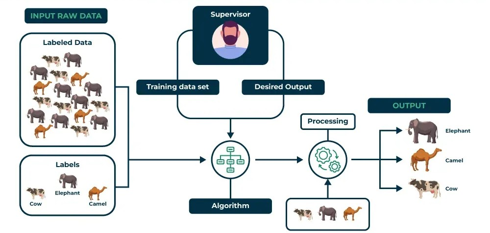

**Fonte:** Supervised and Unsupervised Learning | Geeks for Geeks (2025).

## 4.2. Definição do Problema de Classificação

Em problemas de classificação supervisionada, o objetivo consiste em aprender regras que permitam associar observações a um conjunto finito de categorias previamente definidas. Esse tipo de tarefa distingue-se de outros problemas de aprendizado supervisionado pela natureza da variável resposta, cujo espaço de saída é constituído por um conjunto finito de rótulos e, portanto, discreto. Nesse contexto, a formulação matemática do problema requer a especificação do espaço de características, do conjunto de classes e do critério de decisão adotado, elementos que são descritos a seguir na Definição 4.1.

Definição 4.1 (Problema de Classificação Supervisionada - Hastie, Tibshirani, e Friedman 2009; Schapiro e Turk-Browne 2015; Zhou 2021)

Seja $\mathcal{X} \subseteq \mathbb{R}^p$ um espaço de variáveis explicativas e $\mathcal{Y} = \{c_1, \ldots, c_K\}$, com $K \geqslant 2$, um conjunto finito de rótulos (classes). Dado um conjunto de dados rotulados, $D = \{(\mathbf{x}_i, y_i)\}_{i=1}^{n}$, em que $\mathbf{x}_i = (x_{i1}, \ldots, x_{ip}) \in \mathcal{X}$ representa o vetor de atributos associado à $i$-ésima instância, e $y_i \in \mathcal{Y}$ denota a classe (rótulo) observada correspondente. O **problema de classificação supervisionada** consiste em estimar uma função preditiva $f: \mathcal{X} \to \mathcal{Y}$ pertencente a um *espaço de hipóteses* $\mathcal{F}$ (isto é, o espaço de todas as *funções preditivas* admissíveis), por meio da minimização do *risco empírico* associado a uma função de perda $L : \mathcal{Y} \times \mathcal{Y} \to \mathbb{R}$, adequada à natureza discreta/categórica da variável resposta. Isto é,
$$\begin{align}\\
f^* = \arg\min_{f \ \in \ \mathcal{F}} \left\{ \hat{R}_n(f) \right\} = \arg\min_{f \ \in \ \mathcal{F}} \left\{\frac{1}{n} \sum_{i=1}^{n} L\left(y_i, f(\mathbf{x}_i)\right)\right\} \\\\
\end{align}$$
em que $\hat{R}_n(f)$ denota o *risco empírico* e $f^*$ denota o *classificador ajustado*, utilizado para a atribuição de rótulos a novas observações.

A partir da Definição 4.1, o problema de classificação supervisionada pode, então, ser interpretada como a aproximação de uma *regra de decisão* $\delta : \mathcal{X} \to \mathcal{Y}$, que particiona o espaço das variáveis explicativas $\mathcal{X}$ em $K$ regiões disjuntas, cada uma associada a uma classe $c_k \in \mathcal{Y}$ (Kuhn e Johnson 2013; Witten et al. 2017). Neste sentido, sob uma perspectiva probabilística, diversos métodos de classificação buscam estimar, direta ou indiretamente, as probabilidades condicionais $P(Y = c_k \mid \mathbf{X} = \mathbf{x})$, de modo que a atribuição de rótulos a novas observações decorra da maximização da probabilidade a posteriori. Essa visão, em particular, conecta o problema de classificação à teoria da decisão estatística, na qual a escolha da função de perda $L$ determina a forma ótima da regra de decisão (Gelman et al. 1995; Box e Tiao 2011). Mais especificamente, dado um custo de decisão formalizado por uma função de perda $L:\mathcal{Y} \times \mathcal{Y} \to \mathbb{R}$, a qualidade de uma regra $\delta$ é avaliada por meio do *risco esperado*:
$$\begin{align}\\
R(\delta) = \mathbb{E}_{\mathbf{X},Y}\left[L\left(Y,\delta(\mathbf{X})\right)\right] = \sum_{k=1}^{K} \int_{\mathcal{X}} L\left(c_k,\delta(\mathbf{x})\right) P(Y=c_k \mid \mathbf{X}=\mathbf{x}) dP_{\mathbf{X}}(\mathbf{x}) \\\\
\end{align}$$
o qual integra, sobre o espaço das variáveis explicativas, o *risco condicional* associado a cada decisão possível. Neste contexto, a minimização de $R(\delta)$ define, então, a *regra de decisão ótima* (Gelman et al. 1995; Box e Tiao 2011). Sob a função de perda 0-1, definida por $L(y,\hat{y}) = \mathbb{I}(y\neq\hat{y})$, por exemplo, a equação acima se reduz à minimização da probabilidade de erro de classificação. Nesse caso, a regra de decisão ótima assume a forma da *regra Bayesiana de classificação*, segundo a qual a cada observação $\mathbf{x} \in \mathcal{X}$ é atribuído o rótulo:
$$\begin{align}\\
\delta^*(\mathbf{x}) = \arg\max_{c_k \ \in \ \mathcal{Y}} \left\{ P(Y = c_k \mid \mathbf{X} = \mathbf{x})\right\}\\\\
\end{align}$$

Sob esse enquadramento, métodos de classificação supervisionada podem ser compreendidos como aproximações práticas dessa regra ótima, seja por meio da estimação direta das probabilidades condicionais, seja pela construção de funções discriminantes que induzem decisões equivalentes em termos de risco. Na prática, contudo, a implementação direta da regra de Bayes é inviável, uma vez que as distribuições condicionais verdadeiras são desconhecidas e a função de perda 0-1 associada à classificação ótima conduz a problemas de otimização não convexos. Por essa razão, os métodos de classificação recorrem a funções de perda alternativas, mais regulares, que preservam o princípio decisório subjacente e permitem a estimação eficiente de classificadores a partir de dados amostrais. Nesse contexto, a regra de decisão continua sendo definida a partir de uma função $\delta(\mathbf{x})$, mas a otimização passa a ser realizada sobre uma *função de escore* ou *função preditiva real* $f: \mathcal{X} \to \mathbb{R}$, a partir da qual a decisão final é induzida. A função de perda passa, então, a penalizar discrepâncias entre o rótulo observado e o valor assumido por $f(\mathbf{x})$ ou por uma transformação deste, mantendo-se a conexão com o risco esperado definido anteriormente. Sob essa formulação, diferentes funções de perda podem ser empregadas, tanto no caso em que os rótulos são codificados em $\{-1,+1\}$ quanto em $\{0,1\}$, sem alteração do princípio decisório. Entre as perdas mais utilizadas em classificação supervisionada, destacam-se:

- **(I) Perda Logística (ou Entropia Cruzada Binária)**. Seja $Y \in \{-1,+1\}$ uma variável resposta binária e $f:\mathcal{X} \to \mathbb{R}$ uma função discriminante real. Define-se por *perda logística* a expressão:
  $$\begin{align}\\
  L(y,f(\mathbf{x})) = \log\left(1 + \exp\{-yf(\mathbf{x})\}\right) \\\\
  \end{align}$$
  em que o termo $y f(\mathbf{x})$ controla simultaneamente a correção da classificação (via o sinal) e a confiança da decisão (via a magnitude), penalizando de forma mais severa observações classificadas incorretamente ou com pequena margem. Alternativamente, quando os rótulos são codificados como $Y \in \{0,1\}$, a função discriminate $f(\mathbf{x})$ é relacionada à probabilidade condicional por meio da função logística:
  $$\begin{align}\\
  p(\mathbf{x}) = P(Y = 1 \mid \mathbf{X} = \mathbf{x}) = \dfrac{\exp\{f(\mathbf{x})\}}{1 + \exp\{f(\mathbf{x})\}} \\\\
  \end{align}$$
  Sob essa parametrização, a perda logística assume a forma:
  $$\begin{align}\\
  L(y,p(\mathbf{x})) = -\left[y\log(p(\mathbf{x})) + (1-y)\log(1-p(\mathbf{x}))\right] \\\\
  \end{align}$$
  a qual coincide com o negativo do logaritmo da verossimilhança condicional de um modelo Bernoulli para $Y \mid \mathbf{X} = \mathbf{x}$, de modo que a minimização do risco empírico sob essa perda equivale à maximização da verossimilhança associada.
- **(II) Perda de Articulação**. Seja $Y \in \{-1,+1\}$ uma variável resposta binária e $f:\mathcal{X} \to \mathbb{R}$ uma função discriminante real. Define-se por *perda de articulação* a expressão:
  $$\begin{align}\\
  L\left(y,f(\mathbf{x})\right) = \max\left\{0,1 - yf(\mathbf{x})\right\}\\\\
  \end{align}$$
  Nessa formulação, o termo $y,f(\mathbf{x})$ representa a *margem funcional* associada à observação $\mathbf{x}$. Classificações corretas com margem maior ou igual a uma unidade não incorrem em penalização, enquanto observações classificadas incorretamente ou com margem inferior a esse limiar são penalizadas de forma linear. Assim, a perda de articulação não apenas distingue classificações corretas de incorretas, mas também incorpora a noção de separação geométrica entre as classes. Além disso, a perda de articulação é uma função convexa e não diferenciável no ponto $y,f(\mathbf{x}) = 1$, característica que motiva o uso de técnicas de otimização convexa com restrições. A minimização do risco empírico associado a essa perda conduz à estimação de classificadores que maximizam a margem entre as classes, princípio das *máquinas de vetores de suporte* (*support vector machines*). Sob essa perspectiva, a regra de decisão induzida pela perda de articulação preserva o fundamento decisório da classificação Bayesiana, ainda que a função de perda não admita uma interpretação probabilística direta.
- **(III) Escore de Brier**. Seja $Y \in \{0,1\}$ uma variável resposta binária e $p:\mathcal{X} \to [0,1]$ uma função preditiva que fornece uma estimativa da probabilidade condicional $p(\mathbf{x}) = P(Y=1 \mid \mathbf{X}=\mathbf{x})$. Define-se por *escore de Brier* a função de perda:
  $$\begin{align}\\
  L\left(y,p(\mathbf{x})\right) = \left(y - p(\mathbf{x})\right)^2\\\\
  \end{align}$$
  Essa perda mede o erro quadrático entre o rótulo observado e a probabilidade predita, penalizando simultaneamente classificações incorretas e probabilidades mal calibradas. Diferentemente de perdas definidas diretamente em termos de funções discriminantes, a perda de Brier avalia a qualidade probabilística das predições, atribuindo penalizações crescentes a previsões excessivamente confiantes que não se confirmam empiricamente. Sob a ótica da teoria da decisão, a perda de Brier constitui uma *regra de pontuação própria*, no sentido de que o risco esperado é minimizado quando $p(\mathbf{x})$ coincide com a verdadeira probabilidade condicional $P(Y=1 \mid \mathbf{X}=\mathbf{x})$. Em consequência, a minimização do risco empírico associado a essa perda conduz a estimadores probabilisticamente calibrados.

**Exemplo 4.1 (Filtro de Spam).** Considere o problema da construção de um filtro automático de spam, cujo objetivo é classificar mensagens de correio eletrônico em duas categorias mutuamente exclusivas: *spam* e *não spam*. Este problema, em particular, trata-se de um *problema de classificação binária*, no qual o espaço de rótulos é dado por $\mathcal{Y} = \{0,1\}$, em que, por convenção, $Y = 1$ indica que a mensagem é classificada como *spam*, e $Y=0$ indica que a mensagem é classificada como *não spam*. O problema pode, então, ser estruturado na etapas:

- **(1) Tarefa:** Construir um classificador capaz de decidir, para cada nova mensagem de correio eletrônico, se ela deve ser classificada como *spam* ou *não-spam*, com base em informações extraídas do próprio conteúdo da mensagem e de seus metadados.
- **(2) Dados de Entrada ($x_i$):** Cada observação corresponde a uma mensagem de e-mail representada por um vetor de características $x_i \in \mathcal{X}$. Esse vetor pode incluir variáveis derivadas do texto da mensagem, como a frequência de palavras ou expressões frequentemente associadas a mensagens indesejadas (por exemplo, “promoção”, “gratuito”, “oferta”), bem como atributos estruturais, como o número de links ou anexos, o uso excessivo de letras maiúsculas ou de pontuação, e medidas relacionadas ao comprimento total do texto.
- **(3) Rótulo ($y_i$):** A variável resposta $y_i$ indica a classe verdadeira associada à mensagem e é definida como:
  $$\begin{align}\\
  y_i =
  \begin{cases}
  1 & \text{se a mensagem é de spam} \\\\
  0 & \text{se a mensagem não é de spam}
  \end{cases}\\\\
  \end{align}$$
- **(4) Modelo e Função de Perda:** Em uma formulação probabilística, o classificador é especificado como uma função $f:\mathcal{X} \to [0,1]$, que produz uma estimativa $p(x_i) = P(Y = 1 \mid X = x_i)$ da probabilidade de que a mensagem seja *spam*. O ajuste do modelo é realizado por meio da minimização do risco empírico associado à *entropia cruzada binária*, definida por:
  $$\begin{align}\\
  L(y_i,f(x_i)) = - \big[ y_i \log p(x_i) + (1 - y_i) \log (1 - p(x_i)) \big]\\\\
  \end{align}$$
- **(5) Decisão:** A partir da probabilidade predita $p(x_i)$, a classe atribuída à mensagem é obtida por meio de uma regra de decisão, usualmente baseada em um limiar fixo $\varphi$, definido $\varphi = 0.5$. Neste caso, ocorre um *erro de classificação* sempre que a decisão produzida pelo classificador não coincide com o rótulo verdadeiro, isto é, quando $\hat{y}_i \neq y_i$.

Para fins didáticos, o funcionamento desse classificador em fase de uso é ilustrado esquematicamente na Figura 4.2, na qual mensagens de correio eletrônico são automaticamente direcionadas para a caixa de entrada ou para a pasta de *spam* com base na decisão produzida pelo modelo.

**Figura 4.2.** Representação esquemática do funcionamento de um classificador de *spam*.

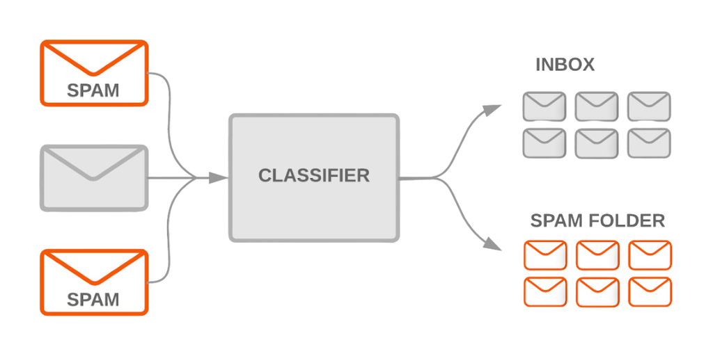

**Fonte:** How spam detection taught us better tech support | Google Cloud Blog. Acesso em 6 de janeiro de 2026.

$$\small
\begin{align}
\tag*{$\blacksquare$}\\\\
\end{align}$$

## 4.3. Erro de Classificação

Na formulação do problema de classificação, foi visto que a função de perda é o elemento que orienta o processo de ajuste do modelo, por meio da *minimização do risco empírico*. Uma vez ajustado um classificador, torna-se necessário estabelecer critérios adequados para *avaliar seu desempenho preditivo*, em especial no que diz respeito à sua capacidade de generalização para observações não utilizadas no treinamento. Essa análise fundamenta-se na comparação entre os rótulos verdadeiros associados às observações e as classes preditas pelo modelo (Bishop e Nasrabadi 2006; Hastie, Tibshirani, e Friedman 2009). A partir dessa perspectiva, o desempenho em problemas de classificação é avaliado por meio do *erro de classificação*, entendido como a ocorrência de discordância entre o rótulo verdadeiro e a decisão produzida pelo classificador, conforme descrito na Definição 4.2.

Definição 4.2 (Erro de Classificação - Hastie, Tibshirani, e Friedman 2009; Schapiro e Turk-Browne 2015; Zhou 2021)

Seja $\mathcal{X} \subseteq \mathbb{R}^p$ um espaço de variáveis explicativas e $\mathcal{Y} = \{c_1, \ldots, c_K\}$, com $K \geqslant 2$, um conjunto finito de rótulos (classes). Dado um conjunto de dados rotulados, $D = \{(\mathbf{x}_i, y_i)\}_{i=1}^{n}$, em que $\mathbf{x}_i = (x_{i1}, \ldots, x_{ip}) \in \mathcal{X}$ representa o vetor de atributos associado à $i$-ésima instância, e $y_i \in \mathcal{Y}$ denota a classe (rótulo) observada correspondente. Para este conjunto, constrói-se um classificador $g:\mathcal{X}\rightarrow\mathcal{Y}$, que associa a cada observação uma decisão $\hat{y}_i=g(x_i)$, tal que o *erro de classificação* é definido como a ocorrência de discordância entre o rótulo verdadeiro e a decisão produzida pelo classificador, isto é, $\hat{y}_i \neq y_i$.

É importante ressaltar, na Definição 4.2, que o erro de classificação é uma quantidade *intrínseca ao problema de classificação*,independente da função de perda utilizada no treinamento do modelo. De fato, ainda que o classificador seja ajustado pela minimização de funções de perda contínuas — como, por exemplo, a *entropia cruzada* — o erro de classificação permanece definido exclusivamente pela comparação entre o rótulo verdadeiro $y_i$ e a decisão produzida pelo classificador, denotada por $\hat{y}_i$. Na prática, no entanto, a associação do *erro de classificação* à perda 0-1 fornece, em geral, uma formalização matemática simples e útil desse conceito: classificações corretas recebem *penalização nula*, enquanto classificações incorretas recebem *penalização unitária*. Essa formulação torna explícito que o critério de avaliação final do desempenho do classificador depende apenas do resultado da decisão do modelo, e não do mecanismo de otimização empregado durante o treinamento (Mitchell 1983; Bishop e Nasrabadi 2006; Shalev-Shwartz e Ben-David 2014). Desse modo, a *taxa empírica de erro de classificação* associada a um classificador $g$, avaliada em um conjunto de $n$ observações, é definida como (Hastie, Tibshirani, e Friedman 2009; Shalev-Shwartz e Ben-David 2014):
$$\begin{align}\\
\widehat{R}_{0\text{–}1}(g)&= \frac{1}{n}\sum_{i=1}^{n} \mathbb{I}\!\left( g(x_i) \neq y_i \right)\\\\
\end{align}$$
em que $\mathbb{I}(\cdot)$ denota a função indicadora. denota a função indicadora. Embora essa expressão constitua, do ponto de vista formal, um caso particular do risco empírico, *sua interpretação é específica do contexto de classificação*, pois se refere exclusivamente às decisões finais do classificador, e não ao processo contínuo de estimação subjacente (Hastie, Tibshirani, e Friedman 2009). Para ilustrar, considere o problema de *classificação binária*, no qual $y_i \in \{0,1\}$ e $g(x_i) \in \{0,1\}$. Neste problema, um erro de classificação ocorre em exatamente dois eventos disjuntos: quando $y_i = 0$ e $g(x_i) = 1$, chamado de *falso positivo* (FP), e quando $y_i = 1$ e $g(x_i) = 0$, chamado de *falso negativo* (FN). Essa distinção permite decompor o indicador de erro como a soma desses dois eventos, isto é,
$$\begin{align}\\
\mathbb{I}\!\left\{ g(x_i) \neq y_i \right\} &= \mathbb{I}\!\left\{ y_i = 0,\; g(x_i) = 1 \right\} + \mathbb{I}\!\left\{ y_i = 1,\; g(x_i) = 0 \right\}\\\\
\end{align}$$
Ao substituir essa decomposição na definição do risco empírico, obtém-se uma expressão que evidencia explicitamente a contribuição de cada tipo de erro, isto é,
$$\begin{align}\\
\widehat{R}_{0\text{–}1}(g) &= \frac{1}{n}\sum_{i=1}^n \mathbb{I}\!\left\{ y_i = 0,\; g(x_i) = 1 \right\} + \frac{1}{n}\sum_{i=1}^n \mathbb{I}\!\left\{ y_i = 1,\; g(x_i) = 0 \right\}\\\\
\end{align}$$
Agora, introduzindo as contagens correspondentes de falsos positivos e falsos negativos, definidas por:
$$\begin{align}\\
\mathrm{FP} &= \sum_{i=1}^n \mathbb{I}\!\left\{ y_i = 0,\; g(x_i) = 1 \right\} \\\\
\mathrm{FN} &= \sum_{i=1}^n \mathbb{I}\!\left\{ y_i = 1,\; g(x_i) = 0 \right\} \\\\
\end{align}$$
Essa expressão pode ser simplificada, resultando na decomposição direta do risco empírico 0-1 (Shalev-Shwartz e Ben-David 2014):
$$\begin{align}\\
\widehat{R}_{0\text{–}1}(g) &= \frac{1}{n}(\mathrm{FP} + \mathrm{FN})\\\\
\end{align}$$
Por outro lado, para completar a descrição dos possíveis resultados da decisão do classificador, é conveniente também explicitar também as contagens de acerto, que correspondem aos casos em que a predição coincide com o rótulo verdadeiro. Em particular, definem-se o número de *verdadeiros positivos* (TP) e *verdadeiros negativos* (TP) como:
$$\begin{align}\\
\mathrm{TP} &= \sum_{i=1}^n \mathbb{I}\!\left\{ y_i = 1,\; g(x_i) = 1 \right\} \\\\
\mathrm{TN} &= \sum_{i=1}^n \mathbb{I}\!\left\{ y_i = 0,\; g(x_i) = 0 \right\} \\\\
\end{align}$$
Essas quantidades representam, respectivamente, o número de observações corretamente classificadas como pertencentes à classe positiva e à classe negativa. Juntamente com as contagens de falsos positivos e falsos negativos, elas fornecem uma enumeração exaustiva e mutuamente exclusiva de todos os possíveis resultados da decisão do classificador ao longo da amostra (Hastie, Tibshirani, e Friedman 2009; Shalev-Shwartz e Ben-David 2014). Em particular, observa-se que essas quatro categorias particionam o conjunto de observações, de modo que o tamanho total da amostra pode ser expresso pela identidade:
$$\begin{align}\\
n &= \mathrm{TP} + \mathrm{TN} + \mathrm{FP} + \mathrm{FN}\\\\
\end{align}$$
Por fim, ao organizar essas informações segundo os rótulos verdadeiros e as decisões produzidas pelo classificador, obtém-se a chamada *matriz de confusão*, apresentada na Tabela 4.2, que fornece uma representação tabular compacta e informativa da estrutura dos acertos e erros de classificação e serve de base conceitual para a definição e interpretação das principais métricas de desempenho em problemas de classificação binária.

**Tabela 4.2.** Matriz de confusão associada a um classificador binário.

| Decisão do Classificador | Rótulos Verdadeiros \(y=1\) (Positivo) | Rótulos Verdadeiros \(y=0\) (Negativo) |
| --- | --- | --- |
| \(g(x)=1\) (Positivo) | \(\mathrm{TP}\) | \(\mathrm{FP}\) |
| \(g(x)=0\) (Negativo) | \(\mathrm{FN}\) | \(\mathrm{TN}\) |

**Fonte:** Elaborado pelo autor (2026).

## 4.4. Medidas de Avaliação de Desempenho

Embora existam extensões naturais das medidas de avaliação para *problemas de classificação multiclasse*, nesta seção considera-se exclusivamente o caso binário, conforme representado pela *matriz de confusão* aprensetada na Tabela 4.2. A partir dessa matriz, podem ser definidas diversas medidas de avaliação que sintetizam os aspectos do desempenho do classificador, permitindo quantificar, de forma objetiva e interpretável, tanto sua capacidade discriminativa quanto seu comportamento frente a diferentes tipos de erro. Essas medidas fornecem critérios formais para a comparação entre modelos candidatos e para a análise da adequação do classificador aos objetivos específicos do problema em estudo (Hastie, Tibshirani, e Friedman 2009). Dentre essas medidas, destacam-se:

- **(a) Acurácia:** quantifica a proporção de instâncias corretamente classificadas pelo modelo em relação ao total de observações avaliadas. Formalmente, é definida como a razão entre o número de predições corretas e o número total de predições realizadas, isto é,
  $$\begin{align}\\
  \textrm{Acurácia} = \dfrac{\text{TP} + \text{TN}}{\text{TP} + \text{TN} + \text{FP} + \text{FN}}\\\\
  \end{align}$$
  em que TP (*true positives*) e TN (*true negatives*) representam, respectivamente, o número de observações corretamente classificadas como positivas e negativas, enquanto FP (*false positives*) e FN (*false negatives*) correspondem às classificações incorretas. Embora seja amplamente utilizada na prática em virtude de sua simplicidade e interpretação direta, a acurácia pode ser inadequada em cenários de forte *desbalanceamento entre classes*, uma vez que pode mascarar desempenho insatisfatório na classe minoritária.
- **(b) Sensibilidade (ou *Recall*):** quantifica a capacidade do classificador em identificar corretamente as instâncias pertencentes à classe positiva. Em termos práticos, mede a proporção de observações positivas que são corretamente reconhecidas pelo modelo. Formalmente, é definida como a razão entre o número de verdadeiros positivos e o total de instâncias verdadeiramente positivas, isto é,
  $$\begin{align}\\
  \text{Sensibilidade (ou Recall)} = \dfrac{\text{TP}}{\text{TP} + \text{FN}}\\\\
  \end{align}$$
  em que TP (*true positives*) e FN (*false negatives*) representam, respectivamente, o número de observações corretamente classificadas como positivas, e o número de observações positivas incorretamente classificadas como negativas.
- **(c) Especificidade:** quantifica a capacidade do classificador em identificar corretamente as instâncias pertencentes à classe negativa. Em termos práticos, mede a proporção de observações negativas que são corretamente reconhecidas pelo modelo. Formalmente, é definida como a razão entre o número de verdadeiros negativos e o total de instâncias verdadeiramente negativas, isto é,
  $$\begin{align}\\
  \text{Especificidade} = \dfrac{\text{TN}}{\text{TN} + \text{FP}}\\\\
  \end{align}$$
  em que TN (*true negatives*) e FP (*false positives*) representam, respectivamente, o número de observações corretamente classificadas como negativas, e o número de observações negativas incorretamente classificadas como positivas.
- **(d) Precisão (ou Valor Preditivo Positivo - VPP):** quantifica a confiabilidade das predições positivas realizadas pelo classificador. Em termos práticos, mede a proporção de instâncias corretamente classificadas como positivas entre todas aquelas preditas como pertencentes à classe positiva. Formalmente, é definida como a razão entre o número de verdadeiros positivos e o total de predições positivas, isto é,
  $$\begin{align}\\
  \text{Precisão} = \dfrac{\text{TP}}{\text{TP} + \text{FP}}\\\\
  \end{align}$$
  em que TP (*true positives*) e FP (*false positives*) representam, respectivamente, o número de observações corretamente classificadas como positivas, e o número de observações negativas incorretamente classificadas como positivas.
- **(e) Valor Preditivo Negativo (VPN):** quantifica a confiabilidade das predições negativas realizadas pelo classificador. Em termos práticos, mede a proporção de instâncias corretamente classificadas como negativas entre todas aquelas preditas como pertencentes à classe negativa. Formalmente, é definido como a razão entre o número de verdadeiros negativos e o total de predições negativas, isto é,
  $$\begin{align}\\
  \text{VPN} = \dfrac{\text{TN}}{\text{TN} + \text{FN}}\\\\
  \end{align}$$
  em que TN (*true negatives*) e FN (*false negatives*) representam, respectivamente, o número de observações corretamente classificadas como negativas, e o número de observações positivas incorretamente classificadas como negativas.
- **(f) Taxa de Falsos Positivos (FPR):** quantifica a proporção de instâncias pertencentes à classe negativa que são incorretamente classificadas como positivas pelo modelo. Em termos práticos, mede a frequência com que o classificador produz alarmes indevidos. Formalmente, é definida como a razão entre o número de falsos positivos e o total de instâncias verdadeiramente negativas, isto é,
  $$\begin{align}\\
  \text{FPR} = \dfrac{\text{FP}}{\text{FP} + \text{TN}}\\\\
  \end{align}$$
  em que TN (*true negatives*) e FP (*false positives*) representam, respectivamente, o número de observações corretamente classificadas como negativas, e o número de observações negativas incorretamente classificadas como positivas.
- **(g) Taxa de Falsos Negativos (FNR):** quantifica a proporção de instâncias pertencentes à classe positiva que são incorretamente classificadas como negativas pelo modelo. Em termos práticos, mede a frequência com que o classificador deixa de identificar corretamente a classe de interesse. Formalmente, é definida como a razão entre o número de falsos negativos e o total de instâncias verdadeiramente positivas, isto é,
  $$\begin{align}\\
  \text{FNR} = \dfrac{\text{FN}}{\text{FN} + \text{TP}}\\\\
  \end{align}$$
  em que TP (*true positives*) e FN (*false negatives*) representam, respectivamente, o número de observações corretamente classificadas como positivas, e o número de observações positivas incorretamente classificadas como negativas.
- **(h) F1-Score (F1):** combina precisão (VPP) e sensibilidade (recall) em uma única medida, por meio de sua média harmônica. Em termos práticos, avalia o equilíbrio entre a capacidade do classificador em identificar corretamente a classe positiva e a confiabilidade das predições positivas realizadas. Formalmente, é definido por:
  $$\begin{align}\\
  \text{F1} = 2 \cdot \dfrac{\text{Precisão} \times \text{Recall}}{\text{Precisão} + \text{Recall}}\\\\
  \end{align}$$
  Essa medida, em particular, assume valores no intervalo $[0,1]$, atingindo o valor máximo apenas quando ambas as métricas, precisão e *recall*, são elevadas, sendo indicada em cenários de desbalanceamento entre classes, nos quais a acurácia se mostra pouco informativa.
- **(i) Coeficiente Kappa ($\kappa$):** avalia o grau de concordância entre as classes previstas pelo classificador e as classes observadas, corrigindo a concordância esperada ao acaso. Em termos práticos, mede quanto o desempenho do modelo excede aquele esperado por uma classificação aleatória com as mesmas distribuições marginais. Formalmente, é definido por:
  $$\begin{align}\\
  \kappa = \dfrac{\text{Acurácia} - \text{Acurácia}_{\text{E}}}{1 - \text{Acurácia}_{\text{E}}}\\\\
  \end{align}$$
  em que:
  $$\begin{align}\\
  \text{Acurácia}_{\text{E}} = \dfrac{(\text{TP} + \text{FP})(\text{TP} + \text{FN}) + (\text{TN} + \text{FN})(\text{TN} + \text{FP})}{(\text{TP} + \text{TN} + \text{FP} + \text{FN})^2}\\\\
  \end{align}$$
  O coeficiente kappa assume valores no intervalo $[-1,1]$, em que valores próximos de 1 indicam elevada concordância além do acaso, $\kappa = 0$ indica concordância compatível com classificações aleatórias, e valores negativos sugerem concordância inferior à esperada ao acaso.
- **(j) Curva ROC (*Receiver Operating Characteristic*):** é uma representação gráfica do desempenho de um classificador ao longo de diferentes limiares de decisão, expressando a relação entre a taxa de verdadeiros positivos (Sensibilidade) e a taxa de falsos positivos (1 - Especificidade), permitindo avaliar o comportamento do modelo sob distintos níveis de tolerância ao erro. Cada ponto da curva corresponde a um limiar aplicado ao escore do classificador, conforme ilustrado na Figura 4.3. Com base nessa figura, conclui-se que um *classificador ideal* produz uma curva próxima ao canto superior esquerdo do plano ROC, enquanto um *classificador aleatório* gera uma curva próxima à diagonal principal.

  **Figura 4.3.** Ilustração da curva ROC (*Receiver Operating Characteristic*) de um classificador.

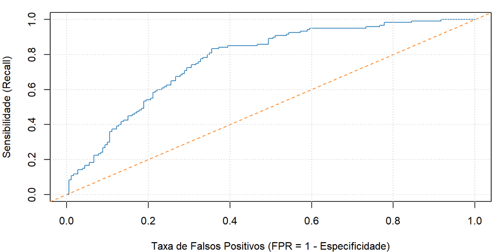

**Fonte:** Elaborado pelo autor (2026).

- **(k) Área sob a Curva ROC (AUROC):** Na prática, para fins de comparação entre classificadores, a informação contida na curva ROC pode ser sintetizada por meio da área sob a curva, denominada AUROC (*Area Under the ROC Curve*), a qual caracteriza a *capacidade discriminativa global* do classificador ao integrar seu comportamento ao longo de todos os limiares de decisão. Sob essa perspectiva, a AUROC pode ser interpretada como a probabilidade de que o escore atribuído a uma observação positiva exceda aquele atribuído a uma observação negativa escolhidas ao acaso. Formalmente, a AUROC é definida por:
  $$\begin{align}\\
  \text{AUROC} = \int_{-\infty}^{\infty} \text{Recall}(t)\, d\left(\text{FPR}(t)\right)\\\\
  \end{align}$$
  em que $t$ é um parâmetro contínuo associado ao limiar de decisão aplicado ao escore do classificador; neste contexto, AUC = 1 corresponde a um *classificador perfeito*, enquanto que AUC = 0,5 indica desempenho equivalente ao de um *palpite aleatório*.
- **(l) Curva PR (*Precision-Recall*):** é uma representação gráfica do desempenho de um classificador ao longo de diferentes limiares de decisão, expressando a relação entre a precisão (valor preditivo positivo) e a sensibilidade (*recall*). Assim como na curva ROC, cada ponto da curva corresponde a um limiar aplicado ao escore do classificador, conforme ilustrado na Figura 4.4. A curva PR, em particular, é mais informativa em cenários de *desbalanceamento entre classes*, pois evidencia diretamente o compromisso entre a capacidade do modelo em identificar corretamente a classe positiva e a confiabilidade das predições positivas realizadas. Além disso, diferentemente da curva ROC, a curva PR não é simétrica em relação às classes e é fortemente influenciada pela prevalência da classe positiva, razão pela qual se mostra mais adequada quando o interesse principal recai sobre o desempenho do classificador na classe minoritária.

  **Figura 4.4.** Ilustração da curva PR (*Precision-Recall*) de um classificador.

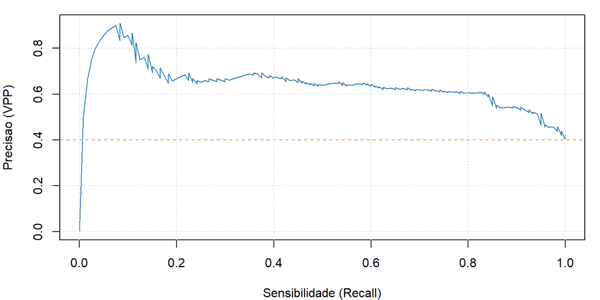

**Fonte:** Elaborado pelo autor (2026).

- **(m) Área sob a Curva PR (AUPRC):** De forma análoga ao que ocorre com a curva ROC, a informação contida na curva PR também pode ser sintetizada por meio da área sob a curva, denominada AUPRC (*Area Under the Precision–Recall Curve*). Essa medida, em particular, fornece uma avaliação global do desempenho do classificador ao longo de todos os limiares de decisão, capturando explicitamente o compromisso entre precisão (valor preditivo positivo) e sensibilidade (*recall*). Em termos matemáticos, a AUPRC é definida por:
  $$\begin{align}\\
  \text{AUPRC} = \int_{-\infty}^{\infty} \text{Precisão}(t)\, d\left(\text{Recall}(t)\right)\\\\
  \end{align}$$
  em que $t$ é um parâmetro contínuo associado ao limiar de decisão aplicado ao escore do classificador.

Embora as medidas de desempenho apresentadas acima forneçam uma avaliação quantitativa da qualidade preditiva do classificador, elas não são suficientes para caracterizar como essa performance é obtida. Nesse contexto, a análise da importância das variáveis constitui um critério complementar de avaliação, ao explicitar a dependência funcional do modelo em relação às covariáveis e ao identificar a contribuição de cada variável para a redução do risco esperado associado à regra de decisão. Formalmente, seja $\hat{f}(\mathbf{X})$ um classificador ajustado e $L$ uma função de perda associada à medida de desempenho considerada. Denotando por $\mathbf{X}^{\pi_j}$ o vetor de variáveis explicativas no qual a $j$-ésima componente $X_j$ é substituída por uma permutação aleatória $X_j^{\pi}$ de suas observações — que preserva a distribuição marginal de $X_j$, mas rompe sua associação com $Y$ e com as demais variáveis — define-se a *importância por permutação* de $X_j$ (Hastie, Tibshirani, e Friedman 2009; A. Fisher, Rudin, e Dominici 2019) como:
$$\begin{align}\\
\mathcal{I}_j = \mathbb{E}\!\left[ L\big(Y, \hat{f}(\mathbf{X}^{\pi_j})\big) - L\big(Y, \hat{f}(\mathbf{X})\big) \right]\\\\
\end{align}$$
Essa quantidade representa a variação esperada do risco associada à neutralização da informação fornecida por $X_j$, mantendo-se inalteradas as demais componentes do classificador. Por construção, espera-se $\mathcal{I}_j \geqslant 0$, e valores elevados indicam maior relevância da variável para a capacidade discriminatória do modelo. Como a definição independe da forma funcional de $\hat{f}$, a importância por permutação é aplicável tanto a classificadores lineares quanto a modelos não lineares, desde que a função de perda adotada seja compatível com o problema de classificação binária.

## 4.5. Desbalanceamento de Classes

Em tarefas de classificação supervisionada, é comum que, na prática, as classes apresentem distribuições assimétricas, com uma ou mais classes ocorrendo com frequência substancialmente menor do que as demais. Esse fenômeno é usualmente referido como *desbalanceamento de classes* (Definição 4.3) e influencia tanto o processo de aprendizagem quanto a avaliação do desempenho preditivo. Nessas situações, medidas globais como a acurácia passam a ter interpretação limitada, uma vez que classificadores que privilegiam a classe majoritária podem apresentar valores elevados mesmo quando a identificação da classe minoritária é insatisfatória (Hastie, Tibshirani, e Friedman 2009).

Definição 4.3 (Desbalanceamento de Classes - Hastie, Tibshirani, e Friedman 2009; Zhou 2021)

Considere um problema de classificação supervisionada com conjunto finito de rótulos (classes) $\mathcal{Y} = \{c_1, \ldots, c_K\}$, com $K \geqslant 2$, e variável resposta $Y$. Denote por $\pi_k = P(Y = c_K)$ a prevalência da classe $c_k$. Diz-se que o problema apresenta *desbalanceamento de classes* quando existe pelo menos uma classe $c_k$ tal que $\pi_k \ll \pi_j$ para algum $j \neq k$.

Entre as estratégias empregadas para lidar com o desbalanceamento de classes, destacam-se aquelas que atuam diretamente sobre o conjunto de dados de treinamento por meio de procedimentos de reamostragem, sem modificar o algoritmo de classificação. Essas abordagens incluem tanto a *subamostragem da classe majoritária* (*undersampling*), que inclui técnicas como *random undersampling*, *NearMiss* e *Tomek Links*; quanto a *superamostragem da classe minoritária* (*oversampling*), realizada via replicação de observações ou geração sintética de exemplos. Nesse último caso, destacam-se métodos baseados em interpolação no espaço de atributos, como o *Synthetic Minority Over-sampling Technique* (SMOTE) e suas extensões, incluindo *Borderline*-SMOTE e *Adaptive Synthetic Sampling* (ADASYN). O objetivo dessas estratégias é reduzir o viés induzido pela predominância da classe majoritária durante o processo de aprendizagem, aumentando a representatividade da classe minoritária no conjunto de treinamento e favorecendo um equilíbrio mais adequado entre viés e variância (Hastie, Tibshirani, e Friedman 2009).

### 4.5.1. *Random Undersampling*

Considere um conjunto de treinamento $\mathcal{D} = \{(x_i, y_i)\}_{i=1}^n$, com $y_i \in \mathcal{Y} = \{c_1,\ldots,c_K\}$. Para cada classe $c_k$, defina $\mathcal{D}_k = \{(x_i, y_i) \in \mathcal{D} : y_i = c_k\}$, com cardinalidade $n_k = |\mathcal{D}_k|$. Sem perda de generalidade, suponha que $c_M$ denote uma *classe majoritária*, isto é, $n_M = \max_k (n_k)$, e denote por $\mathcal{D}_{-M} = \bigcup_{k\, \neq\, M} \mathcal{D}_k$ o conjunto das demais classes, mantido inalterado no procedimento. A técnica de *random undersampling* consiste, então, em selecionar um subconjunto $\mathcal{D}_M^\ast \subset \mathcal{D}_M$ por amostragem aleatória simples sem reposição, com tamanho-alvo $n_M^\ast < n_M$, e então definir o novo conjunto de treinamento como:
$$\begin{align}\\
\mathcal{D}^\ast = \mathcal{D}_{-M} \cup \mathcal{D}_M^\ast, \qquad |\mathcal{D}_M^\ast| = n_M^\ast < n_M\\\\
\end{align}$$
A escolha de $n_M^\ast$ determina o grau de reequilíbrio obtido em $\mathcal{D}^\ast$. No caso binário, por exemplo, é comum adotar $n_M^\ast \approx n_m$, onde $n_m$ denota a cardinalidade da *classe minoritária*, resultando em um conjunto aproximadamente balanceado. Em problemas multiclasse, $n_M^\ast$ é usualmente definido em função de uma razão-alvo entre classes (ou de um limite superior para $n_M^\ast$), evitando que a classe majoritária permaneça desproporcionalmente dominante no treinamento. Embora simples e computacionalmente eficiente, o *random undersampling* pode acarretar perda de informação relevante da classe majoritária, o que tende a aumentar a variância do estimador, especialmente quando essa classe apresenta elevada heterogeneidade (Shalev-Shwartz e Ben-David 2014; Fernández et al. 2018).

O Código 4.1 ilustra, em detalhes computacionais, a aplicação da técnica de *random undersampling* no cenário de classificação binária com desbalanceamento de classes descrito anteriormente. Especificamente, o exemplo contempla a simulação de uma base de dados desbalanceada, o particionamento em conjuntos de treinamento e teste, a construção de um conjunto de treinamento reamostrado por meio de subamostragem aleatória da classe majoritária (sem reposição) e, por fim, o ajuste e a avaliação comparativa de um classificador baseado em regressão logística no conjunto de teste, considerando-se os cenários com e sem reamostragem.

**Código 4.1.** Ilustração da técnica de *random undersampling* em uma base desbalanceada: simulação dos dados, particionamento treino–teste, subamostragem aleatória da classe majoritária no treino (sem reposição) e avaliação comparativa do desempenho preditivo no conjunto de teste.

```r
## ------------------------------ Simulação da Base de Dados ------------------------------ ##

## Semente

set.seed(20260120)

## Configurações iniciais

n               <- 4000
p               <- 6
X               <- as.data.frame(matrix(rnorm(n * p), nrow = n, ncol = p))
names(X)        <- paste0("x", 1:p)

## Gerar evento raro (usando intercepto negativo no modelo logístico)

eta             <- -3.0 + 0.9*X$x1 - 0.8*X$x2 + 0.6*X$x3 + 0.2*rnorm(n)
prob            <- 1 / (1 + exp(-eta))
y               <- rbinom(n, size = 1, prob = prob)

## Juntar em `data.frame`

dados           <- cbind(X, y = factor(y, levels = c(0, 1)))

## Proporção das classes

fa              <- table(dados$y)
fr              <- prop.table(fa)

cat(" # ------------------------------------ #\n",
    "# Proporção de Classes (Base Completa) #\n",
    "# ------------------------------------ #\n\n",

    paste("",
      capture.output(
        cbind(
          "Frequência" = fa,
          "Proporção (%)" = round(100 * fr, 2)
        )
      ),
      collapse = "\n"
    )
)
```

```
 # ------------------------------------ #
 # Proporção de Classes (Base Completa) #
 # ------------------------------------ #

    Frequência Proporção (%)
 0       3642         91.05
 1        358          8.95
```

```r
## -------------------------- Separação da Base em Treino/Teste --------------------------- ##

idx             <- sample(seq_len(n), size = floor(0.7 * n))
train           <- dados[idx, ]
test            <- dados[-idx, ]

## ---------------------- Funções Auxiliares: Medidas de Desempenho ----------------------- ##

conf_mat        <- function(y_true, y_pred)
{
  tab           <- table(Real = y_true, Pred = y_pred)
  all_levels    <- c("0", "1")
  tab2          <- matrix(0, nrow = 2, ncol = 2,
                          dimnames = list(Real = all_levels, Pred = all_levels))
  tab2[rownames(tab), colnames(tab)] <- tab
  tab2
}

metrics_cm      <- function(cm)
{
  TN            <- cm["0", "0"]
  FP            <- cm["0", "1"]
  FN            <- cm["1", "0"]
  TP            <- cm["1", "1"]

  acc           <- (TP + TN) / sum(cm)
  sens          <- if ((TP + FN) > 0) TP / (TP + FN) else NA
  spec          <- if ((TN + FP) > 0) TN / (TN + FP) else NA
  prec          <- if ((TP + FP) > 0) TP / (TP + FP) else NA
  f1            <- if (!is.na(prec) && !is.na(sens) && (prec + sens) > 0) {
                      2 * prec * sens / (prec + sens)
                   } else NA

  c(Acuracia = acc,
    Sensibilidade = sens,
    Especificidade = spec,
    Precisao = prec,
    F1 = f1)
}

predict_class   <- function(model, newdata, cutoff = 0.5)
{
  pr            <- predict(model, newdata = newdata, type = "response")
  factor(ifelse(pr >= cutoff, 1, 0), levels = c(0, 1))
}

## --------------- Ajuste do Modelo: Regressão Logística (Sem Reamostragem) --------------- ##

m0              <- glm(y ~ ., data = train, family = binomial())
pred0           <- predict_class(m0, test, cutoff = 0.5)
cm0             <- conf_mat(test$y, pred0)
met0            <- metrics_cm(cm0)

## Proporção das classes (treino)

fa              <- table(train$y)
fr              <- prop.table(fa)

cat(" # ---------------------------------------------- #\n",
    "# Proporção de Classes (Base de Treino Original) #\n",
    "# ---------------------------------------------- #\n\n",

    paste("",
      capture.output(
        cbind(
          "Frequência" = fa,
          "Proporção (%)" = round(100 * fr, 2)
        )
      ),
      collapse = "\n"
    ),"\n\n",

    "# ----------------------------- #\n",
    "# Resultados - Sem Reamostragem #\n",
    "# ----------------------------- #\n\n",

    paste(
      capture.output({
        cat("Matriz de Confusão:\n")
        print(cm0)

        cat("\nMétricas de Desempenho:\n")
        print(round(met0, 4))
      }),
      collapse = "\n"
    ),
    "\n"
)
```

```
 # ---------------------------------------------- #
 # Proporção de Classes (Base de Treino Original) #
 # ---------------------------------------------- #

    Frequência Proporção (%)
 0       2544         90.86
 1        256          9.14

 # ----------------------------- #
 # Resultados - Sem Reamostragem #
 # ----------------------------- #

 Matriz de Confusão:
    Pred
Real    0 1
   0 1098 0
   1   94 8

Métricas de Desempenho:
      Acuracia  Sensibilidade Especificidade       Precisao             F1
        0.9217         0.0784         1.0000         1.0000         0.1455
```

```r
## ------------------- Random Undersampling no Conjunto de Treino (1:1) ------------------- ##

## Separar índices por classe no treino

idx_M           <- which(train$y == "0")  # Majoritária
idx_m           <- which(train$y == "1")  # Minoritária
n_M             <- length(idx_M)
n_m             <- length(idx_m)

## Definir tamanho-alvo: igualar majoritária à minoritária (balanceamento 1:1)

n_M_star        <- n_m
idx_M_star      <- sample(idx_M, size = n_M_star, replace = FALSE)

## Construir conjunto de treino reamostrado

train_under     <- train[c(idx_m, idx_M_star), ]
train_under     <- train_under[sample(seq_len(nrow(train_under))), ] # embaralhar

## --------------- Ajuste do Modelo: Regressão Logística (Com Reamostragem) --------------- ##

m1              <- glm(y ~ ., data = train_under, family = binomial())
pred1           <- predict_class(m1, test, cutoff = 0.5)
cm1             <- conf_mat(test$y, pred1)
met1            <- metrics_cm(cm1)

## Proporção das classes (teste)

fa              <- table(train_under$y)
fr              <- prop.table(fa)


cat(" # ----------------------------- #\n",
    "# Tamanho das Classes no Treino #\n",
    "# ----------------------------- #\n\n",

    paste("",
      capture.output(
        cbind(
          "Majoritária" = n_M,
          "Minoritária" = n_m
        )
      ),
      collapse = "\n"
    ),"\n\n",

    "# ----------------------------------------------------------- #\n",
    "# Proporção de Classes (Random Undersampling - Base de Teino) #\n",
    "# ----------------------------------------------------------- #\n\n",

    paste("",
      capture.output(
        cbind(
          "Frequência" = fa,
          "Proporção (%)" = round(100 * fr, 2)
        )
      ),
      collapse = "\n"
    ),"\n\n",

    "# --------------------------------- #\n",
    "# Resultados - Random Undersampling #\n",
    "# --------------------------------- #\n\n",

    paste(
      capture.output({
        cat("Matriz de Confusão:\n")
        print(cm1)

        cat("\nMétricas de Desempenho:\n")
        print(round(met1, 4))
      }),
      collapse = "\n"
    ),
    "\n"
)
```

```
 # ----------------------------- #
 # Tamanho das Classes no Treino #
 # ----------------------------- #

       Majoritária Minoritária
 [1,]        2544         256

 # ----------------------------------------------------------- #
 # Proporção de Classes (Random Undersampling - Base de Teino) #
 # ----------------------------------------------------------- #

    Frequência Proporção (%)
 0        256            50
 1        256            50

 # --------------------------------- #
 # Resultados - Random Undersampling #
 # --------------------------------- #

 Matriz de Confusão:
    Pred
Real   0   1
   0 842 256
   1  23  79

Métricas de Desempenho:
      Acuracia  Sensibilidade Especificidade       Precisao             F1
        0.7675         0.7745         0.7668         0.2358         0.3616
```

Dos resultados obtidos, observa-se que o classificador apresenta desempenho elevado em termos de acurácia, consequência direta da forte predominância da classe negativa. O modelo praticamente não identifica a classe positiva, como indicado pela sensibilidade extremamente baixa (7,8%), enquanto a especificidade e a precisão iguais a 1 decorrem do fato de que nenhuma observação da classe negativa foi classificada como positiva, evidenciando um comportamento conservador, no qual se evitam falsos positivos à custa de ignorar quase completamente a classe de interesse, padrão característico de modelos ajustados em bases desbalanceadas sem a adoção de estratégias corretivas. Após a aplicação do *random undersampling*, observa-se uma mudança substancial no comportamento do classificador, com aumento expressivo da sensibilidade (de 0,08 para 0,77), indicando maior capacidade de identificação das observações pertencentes à classe positiva, objetivo central em problemas envolvendo eventos raros; em contrapartida, verifica-se redução da especificidade, refletindo um aumento controlado no número de falsos positivos. A diminuição da acurácia global é esperada e resulta da eliminação do efeito artificial de dominância da classe majoritária, enquanto a elevação da medida $F1$ (de 0,15 para 0,36) evidencia um equilíbrio mais adequado entre precisão e sensibilidade, tornando-a uma métrica mais informativa nesse contexto. Em síntese, os resultados confirmam que o *random undersampling* não maximiza a acurácia, mas reorienta o processo de aprendizagem para o objetivo substantivo do problema, deslocando o foco da classe majoritária para a detecção efetiva da classe positiva.

$$\small
\begin{align}
\tag*{$\blacksquare$}\\\\\\
\end{align}$$

Atividade Prática 4.1

Implemente, em R, um experimento computacional para um *problema de classificação binária* utilizando a base `SAheart` da biblioteca `ElemStatLearn`, a qual reúne informações clínicas e comportamentais associadas à ocorrência de doença coronariana. Nesta atividade, o objetivo em prever a presença de doença coronariana, representada pela variável resposta `chd`, em que $y=1$ indica presença da doença (classe positiva) e $y=0$ indica ausência (classe negativa). As variáveis explicativas disponíveis incluem: pressão arterial sistólica (`sbp`), consumo de tabaco (`tobacco`), colesterol LDL (`ldl`), adiposidade (`adiposity`), histórico familiar de doença coronariana (`famhist`), escore de personalidade tipo A (`typea`), obesidade (`obesity`), consumo de álcool (`alcohol`) e idade (`age`). Para isto, dado que a variável `chd` apresenta *desbalanceamento moderado*, com cerca de $65\%$ de indivíduos sem doença e $35\%$ com doença, será considerado o ajuste de um classificador baseado em regressão logística sob dois cenários: sem reamostragem (mantendo-se o desbalanceamento original) e com reamostragem via **random undersampling** (balanceamento no conjunto de treinamento). O procedimento experimental deve ser conduzido conforme as etapas a seguir:

- Fixar uma semente aleatória para reprodutibilidade (por exemplo, `set.seed(1212)`);
- Carregar a base `SAheart`, definir a variável resposta `chd` como fator com níveis $\{0,1\}$ e tratar `famhist` como variável categórica, mantendo as demais como quantitativas;
- Particionar os dados em conjuntos de treinamento e teste utilizando o método *hold-out*, com $70\%$ das observações destinadas ao treino e $30\%$ ao teste, reportando a distribuição de classes em cada subconjunto;
- Ajustar um modelo de *regressão logística*, via `glm()`, no conjunto de treinamento *sem reamostragem*, obter probabilidades previstas no conjunto de teste, convertê-las em classes preditas por meio de um ponto de corte fixo (por exemplo, $0{,}5$), e calcular a matriz de confusão e métricas de desempenho;
- Aplicar *random undersampling* exclusivamente no conjunto de treinamento, reduzindo aleatoriamente a classe majoritária ($y=0$) até obter um conjunto aproximadamente balanceado (razão 1:1), e reportar a distribuição de classes após a reamostragem;
- Ajustar novamente o modelo de regressão logística, via `glm()`, no conjunto de treinamento reamostrado e avaliá-lo *no mesmo conjunto de teste*, registrando matriz de confusão e métricas diretamente comparáveis às obtidas no cenário sem reamostragem.

Ao final, organize os resultados em um quadro comparativo e elabore uma síntese interpretativa que discuta (i) por que a acurácia pode se mostrar inflada em situações de desbalanceamento moderado, (ii) como o **random undersampling** reorienta o processo de ajuste do modelo em direção à classe positiva e (iii) quais métricas devem ser priorizadas quando o objetivo é a identificação de indivíduos com doença coronariana.

### 4.5.2. *Synthetic Minority Over-sampling Technique*

Considere um conjunto de treinamento $\mathcal{D} = \{(x_i, y_i)\}_{i=1}^n$, com $y_i \in \mathcal{Y} = \{c_1,\ldots,c_K\}$. Para cada classe $c_k$, defina $\mathcal{D}_k = \{(x_i, y_i) \in \mathcal{D} : y_i = c_k\}$, com cardinalidade $n_k = |\mathcal{D}_k|$. Sem perda de generalidade, suponha que $c_m$ denote uma *classe minoritária*, isto é, $n_m = \min_k (n_k)$, e denote por $\mathcal{D}_{-m} = \bigcup_{k\, \neq \, m} \mathcal{D}_k$ o conjunto das demais classes. A técnica *Synthetic Minority Over-sampling Technique* (SMOTE) consiste em *aumentar artificialmente a representatividade da classe minoritária* por meio da *geração de novas observações sintéticas*, em vez da simples replicação de exemplos existentes. Para esse fim, o método explora a estrutura local dos dados da classe minoritária no espaço de atributos, utilizando relações de vizinhança entre observações. Formalmente, para cada observação $\mathbf{x}_i \in \mathcal{D}_m$, define-se o conjunto $\mathcal{N}_k(\mathbf{x}_i) \subset \mathcal{D}_m$ composto por seus $k$ vizinhos mais próximos, segundo uma métrica de distância previamente especificada (em geral, a distância euclidiana). Um novo exemplo sintético $\tilde{\mathbf{x}}$ é então gerado por interpolação linear entre $\mathbf{x}_i$ e um vizinho $\mathbf{x}_{j} \in \mathcal{N}_k(\mathbf{x}_i)$, selecionado aleatoriamente, de acordo com:
$$\begin{align}\\
\tilde{\mathbf{x}} = \mathbf{x}_i + \lambda \left( \mathbf{x}_{j} - \mathbf{x}_i \right), \qquad \lambda \sim \mathcal{U}(0,1)\\\\
\end{align}$$
O procedimento é repetido até que se atinja um número-alvo $n_m^\ast > n_m$ de observações da classe minoritária, produzindo um conjunto de treinamento reamostrado $\mathcal{D}^\ast = \mathcal{D}_{-m} \cup \mathcal{D}_m^\ast$, em que $\mathcal{D}_{-m}$ permanece inalterado e $\mathcal{D}_m^\ast$ contém tanto as observações originais quanto os exemplos sintéticos gerados pelo SMOTE. Do ponto de vista estatístico, enquanto o *random undersampling* altera a distribuição empírica das classes por subtração de massa amostral da classe majoritária, o SMOTE promove uma redistribuição geométrica da classe minoritária no espaço de atributos, densificando regiões locais definidas pela estrutura de vizinhança. Essa distinção implica diferentes compromissos no balanço viés–variância: o *random undersampling* pode aumentar a variância pela perda de informação, ao passo que o SMOTE tende a preservar a variabilidade global, embora possa introduzir sobreposição artificial entre classes quando a fronteira de decisão é complexa ou quando a classe minoritária apresenta elevada heterogeneidade, o que justifica o uso criterioso do método ou de extensões que incorporam informação da fronteira, como *Borderline-SMOTE* (Shalev-Shwartz e Ben-David 2014; Fernández et al. 2018).

O Código 4.2 apresenta os detalhes computacionais da aplicação do SMOTE no cenário descrito, incluindo simulação dos dados, particionamento treino–teste, reamostragem por geração sintética no treino e avaliação comparativa do desempenho preditivo no teste, considerando-se ambos os cenários.

**Código 4.2.** Ilustração da técnica de SMOTE em uma base desbalanceada: simulação dos dados, particionamento treino–teste, geração de exemplos sintéticos da classe minoritária no conjunto de treinamento e avaliação comparativa do desempenho preditivo no conjunto de teste.

```r
## ------------------------------ Importação das Bibliotecas ------------------------------ ##

library(smotefamily)

## ------------------------------ Simulação da Base de Dados ------------------------------ ##

## Semente

set.seed(20260120)

## Configurações iniciais

n               <- 4000
p               <- 6
X               <- as.data.frame(matrix(rnorm(n * p), nrow = n, ncol = p))
names(X)        <- paste0("x", 1:p)

## Gerar evento raro (usando intercepto negativo no modelo logístico)

eta             <- -3.0 + 0.9*X$x1 - 0.8*X$x2 + 0.6*X$x3 + 0.2*rnorm(n)
prob            <- 1 / (1 + exp(-eta))
y               <- rbinom(n, size = 1, prob = prob)

## Juntar em `data.frame`

dados           <- cbind(X, y = factor(y, levels = c(0, 1)))

## Proporção das classes

fa              <- table(dados$y)
fr              <- prop.table(fa)

cat(" # ------------------------------------ #\n",
    "# Proporção de Classes (Base Completa) #\n",
    "# ------------------------------------ #\n\n",

    paste("",
      capture.output(
        cbind(
          "Frequência" = fa,
          "Proporção (%)" = round(100 * fr, 2)
        )
      ),
      collapse = "\n"
    )
)
```

```
 # ------------------------------------ #
 # Proporção de Classes (Base Completa) #
 # ------------------------------------ #

    Frequência Proporção (%)
 0       3642         91.05
 1        358          8.95
```

```r
## -------------------------- Separação da Base em Treino/Teste --------------------------- ##

idx             <- sample(seq_len(n), size = floor(0.7 * n))
train           <- dados[idx, ]
test            <- dados[-idx, ]

## ---------------------- Funções Auxiliares: Medidas de Desempenho ----------------------- ##

conf_mat        <- function(y_true, y_pred)
{
  tab           <- table(Real = y_true, Pred = y_pred)
  all_levels    <- c("0", "1")
  tab2          <- matrix(0, nrow = 2, ncol = 2,
                          dimnames = list(Real = all_levels, Pred = all_levels))
  tab2[rownames(tab), colnames(tab)] <- tab
  tab2
}

metrics_cm      <- function(cm)
{
  TN            <- cm["0", "0"]
  FP            <- cm["0", "1"]
  FN            <- cm["1", "0"]
  TP            <- cm["1", "1"]

  acc           <- (TP + TN) / sum(cm)
  sens          <- if ((TP + FN) > 0) TP / (TP + FN) else NA
  spec          <- if ((TN + FP) > 0) TN / (TN + FP) else NA
  prec          <- if ((TP + FP) > 0) TP / (TP + FP) else NA
  f1            <- if (!is.na(prec) && !is.na(sens) && (prec + sens) > 0) {
                      2 * prec * sens / (prec + sens)
                   } else NA

  c(Acuracia = acc,
    Sensibilidade = sens,
    Especificidade = spec,
    Precisao = prec,
    F1 = f1)
}

predict_class   <- function(model, newdata, cutoff = 0.5)
{
  pr            <- predict(model, newdata = newdata, type = "response")
  factor(ifelse(pr >= cutoff, 1, 0), levels = c(0, 1))
}

## --------------- Ajuste do Modelo: Regressão Logística (Sem Reamostragem) --------------- ##

m0              <- glm(y ~ ., data = train, family = binomial())
pred0           <- predict_class(m0, test, cutoff = 0.5)
cm0             <- conf_mat(test$y, pred0)
met0            <- metrics_cm(cm0)

## Proporção das classes (treino)

fa              <- table(train$y)
fr              <- prop.table(fa)

cat(" # ---------------------------------------------- #\n",
    "# Proporção de Classes (Base de Treino Original) #\n",
    "# ---------------------------------------------- #\n\n",

    paste("",
      capture.output(
        cbind(
          "Frequência" = fa,
          "Proporção (%)" = round(100 * fr, 2)
        )
      ),
      collapse = "\n"
    ),"\n\n",

    "# ----------------------------- #\n",
    "# Resultados - Sem Reamostragem #\n",
    "# ----------------------------- #\n\n",

    paste(
      capture.output({
        cat("Matriz de Confusão:\n")
        print(cm0)

        cat("\nMétricas de Desempenho:\n")
        print(round(met0, 4))
      }),
      collapse = "\n"
    ),
    "\n"
)
```

```
 # ---------------------------------------------- #
 # Proporção de Classes (Base de Treino Original) #
 # ---------------------------------------------- #

    Frequência Proporção (%)
 0       2544         90.86
 1        256          9.14

 # ----------------------------- #
 # Resultados - Sem Reamostragem #
 # ----------------------------- #

 Matriz de Confusão:
    Pred
Real    0 1
   0 1098 0
   1   94 8

Métricas de Desempenho:
      Acuracia  Sensibilidade Especificidade       Precisao             F1
        0.9217         0.0784         1.0000         1.0000         0.1455
```

```r
## ----------------------------- SMOTE no Conjunto de Treino ------------------------------ ##

## Observação: A função `SMOTE` da biblioteca `smotefamily` espera:
##
## data:     matriz/data.frame numérica com preditores
## class:    vetor 0/1 (numérico ou fator)
## k:        número de vizinhos
## dup_size: controla a quantidade de sintéticos

X_train         <- subset(train, select = -y)
y_train         <- as.integer(as.character(train$y))

## Configuração:
##
## k:        vizinhos
## dup_size: fator aproximado de oversampling da classe minoritária
##
## Ajustar dup_size conforme necessidade para chegar perto de 1:1 no treino.

sm              <- SMOTE(X_train, y_train, K = 5, dup_size = 8)
train_smote     <- sm$data

## sm$data traz a coluna "class" como resposta (0/1)

train_smote$class <- factor(train_smote$class, levels = c(0, 1))
names(train_smote)[names(train_smote) == "class"] <- "y"

## -------------------- Ajuste do Modelo: Regressão Logística (SMOTE) --------------------- ##

m1              <- glm(y ~ ., data = train_smote, family = binomial())
pred1           <- predict_class(m1, test, cutoff = 0.5)
cm1             <- conf_mat(test$y, pred1)
met1            <- metrics_cm(cm1)

## Proporção das classes (teste)

fa              <- table(train_smote$y)
fr              <- prop.table(fa)

cat(" # -------------------------------------------- #\n",
    "# Proporção de Classes (SMOTE - Base de Teino) #\n",
    "# -------------------------------------------- #\n\n",

    paste("",
      capture.output(
        cbind(
          "Frequência" = fa,
          "Proporção (%)" = round(100 * fr, 2)
        )
      ),
      collapse = "\n"
    ),"\n\n",

    "# ------------------ #\n",
    "# Resultados - SMOTE #\n",
    "# ------------------ #\n\n",

    paste(
      capture.output({
        cat("Matriz de Confusão:\n")
        print(cm1)

        cat("\nMétricas de Desempenho:\n")
        print(round(met1, 4))
      }),
      collapse = "\n"
    ),
    "\n"
)
```

```
 # -------------------------------------------- #
 # Proporção de Classes (SMOTE - Base de Teino) #
 # -------------------------------------------- #

    Frequência Proporção (%)
 0       2544         52.48
 1       2304         47.52

 # ------------------ #
 # Resultados - SMOTE #
 # ------------------ #

 Matriz de Confusão:
    Pred
Real   0   1
   0 864 234
   1  24  78

Métricas de Desempenho:
      Acuracia  Sensibilidade Especificidade       Precisao             F1
        0.7850         0.7647         0.7869         0.2500         0.3768
```

Dos resultados obtidos, observa-se que o classificador ajustado sem a aplicação de técnicas de reamostragem apresenta desempenho elevado em termos de acurácia, consequência direta da forte predominância da classe negativa. Nesse cenário, o modelo praticamente não identifica a classe positiva, como indicado pela sensibilidade extremamente baixa (7,8%), enquanto a especificidade e a precisão iguais a 1 decorrem do fato de que nenhuma observação da classe negativa foi classificada como positiva, evidenciando um comportamento conservador, no qual se evitam falsos positivos à custa de ignorar quase completamente a classe de interesse, padrão característico de modelos ajustados em bases desbalanceadas sem a adoção de estratégias corretivas. Após a aplicação do SMOTE, observa-se uma mudança substancial no comportamento do classificador, com aumento expressivo da sensibilidade (para 0,76), indicando maior capacidade de identificação das observações pertencentes à classe positiva, objetivo central em problemas envolvendo eventos raros; em contrapartida, verifica-se redução da especificidade, refletindo um aumento controlado no número de falsos positivos. A diminuição da acurácia global é esperada e resulta da eliminação do efeito artificial de dominância da classe majoritária, enquanto a elevação da medida $F1$ para 0,38 evidencia um equilíbrio mais adequado entre precisão e sensibilidade, tornando-a uma métrica mais informativa nesse contexto. Resultados semelhantes aos obtidos com o *random undersampling* foram observados, com diferenças associadas principalmente à natureza da reamostragem: enquanto o SMOTE *preserva todas as observações originais* e introduz variabilidade por meio de interpolação no espaço de atributos, reduzindo a perda de informação da classe majoritária, o *random undersampling* atua pela sua *remoção direta*. Em ambos os casos, observa-se ganho comparável na detecção da classe positiva; a escolha entre as técnicas passa, sobretudo, pelo mecanismo de reequilíbrio adotado e pelas restrições do problema em análise. Em particular, o SMOTE tende a ser mais adequado quando se busca preservar o tamanho amostral e a estrutura global dos dados, enquanto o *random undersampling* se mostra mais apropriado quando a redução da classe majoritária não implica perda relevante de informação ou quando há interesse em simplificar o conjunto de treinamento.

$$\small
\begin{align}
\tag*{$\blacksquare$}\\\\\\
\end{align}$$

Atividade Prática 4.2

Dando continuidade à Atividade Prática 4.1, implemente, em R, novamente um experimento computacional para o mesmo *problema de classificação binária* com a base `SAheart` da biblioteca `ElemStatLearn`. O objetivo permanece a predição da presença de doença coronariana, representada pela variável resposta `chd`, em que $y=1$ indica presença da doença (classe positiva) e $y=0$ indica ausência (classe negativa). Mantendo-se o contexto de *desbalanceamento moderado* em `chd` (cerca de $65\%$ em $y=0$ e $35\%$ em $y=1$), considere agora o ajuste de um classificador baseado em regressão logística sob dois cenários: sem reamostragem (desbalanceamento original) e com reamostragem via **SMOTE**, por meio da geração de observações sintéticas da classe minoritária no conjunto de treinamento. O procedimento experimental deve ser conduzido conforme as etapas a seguir:

- Fixar uma semente aleatória para reprodutibilidade (por exemplo, `set.seed(1212)`);
- Carregar a base `SAheart`, definir a variável resposta `chd` como fator com níveis $\{0,1\}$ e tratar `famhist` como variável categórica, mantendo as demais como quantitativas;
- Particionar os dados em conjuntos de treinamento e teste utilizando o método *hold-out*, com $70\%$ das observações destinadas ao treino e $30\%$ ao teste, reportando a distribuição de classes em cada subconjuntos;
- Ajustar um modelo de *regressão logística*, via `glm()`, no conjunto de treinamento *sem reamostragem*, obter probabilidades previstas no conjunto de teste, convertê-las em classes preditas por meio de um ponto de corte fixo (por exemplo, $0{,}5$), e calcular a matriz de confusão e métricas de desempenho;
- Aplicar *SMOTE exclusivamente no conjunto de treinamento*, gerando observações sintéticas da classe minoritária ($y=1$) até obter um conjunto aproximadamente balanceado (razão 1:1), e reportar a distribuição de classes após a reamostragem;
- Ajustar novamente o modelo de regressão logística, via `glm()`, no conjunto de treinamento reamostrado e avaliá-lo *no mesmo conjunto de teste*, registrando matriz de confusão e métricas diretamente comparáveis às obtidas no cenário sem reamostragem.

Ao final, organize os resultados em um quadro comparativo e elabore uma síntese interpretativa que discuta (i) por que a acurácia pode se mostrar inflada em situações de desbalanceamento moderado, (ii) como o **SMOTE** altera a composição do conjunto de treinamento e afeta o compromisso entre sensibilidade e precisão para a classe positiva, e (iii) quais métricas devem ser priorizadas quando o objetivo é a identificação de indivíduos com doença coronariana.

## 4.6. Algoritmos de Classificação Supervionada

Nesta seção são apresentados os principais algoritmos de classificação supervisionada, com foco na descrição de seus fundamentos conceituais, hipóteses, vantagens, limitações e contextos de aplicação, de modo a estabelecer a base necessária para as análises desenvolvidas posteriormente. São discutidos métodos baseados em proximidade, com destaque para o *k-nearest neighbors* (Seção 4.6.1), que utiliza medidas de distância no espaço dos preditores para definir regras de decisão, bem como modelos probabilísticos clássicos, incluindo a regressão logística (Seção 4.6.2) e o *naïve Bayes* (Seção 4.6.3), além de seus derivados, que se apoiam em suposições sobre independência condicional. Em seguida, são abordados modelos baseados em partições do espaço amostral, como as árvores de decisão (Seção 4.6.4) e suas extensões, que buscam maior estabilidade e desempenho preditivo, assim como as máquinas de vetor de suporte (*support vector machines*) (Seção 4.6.5), que exploram a maximização de margens e o uso de funções de núcleo (*kernel*) para lidar com fronteiras de decisão não lineares. Por fim, são apresentadas as redes neurais do tipo *multilayer perceptron* (Seção 4.6.6), que permitem modelar relações entre variáveis por meio de camadas ocultas e funções de ativação não lineares, oferecendo uma visão integrada das diferentes abordagens de classificação que serão detalhadas nas seções subsequentes.

### 4.6.1. *k-Nearest Neighbors*

O algoritmo ($k$-*Nearest Neighbors* – $k$-NN – Kramer 2013) é um método de classificação não-paramétrico fundamentado na hipótese de que observações com características semelhantes tendem a localizar-se em regiões próximas do espaço de atributos. No âmbito da classificação supervisionada, a atribuição de rótulo a uma nova observação $\tilde{x}$ é realizada a partir da avaliação de sua proximidade em relação às observações $x_i$ pertencentes ao conjunto de treinamento, segundo uma métrica de distância previamente definida. Após o cálculo dessas distâncias, os $k$ vizinhos mais próximos são identificados, e a classe associada a $\tilde{x}$ é determinada com base na agregação das classes desses vizinhos, de acordo com uma regra de decisão especificada, conforme ilustrado na Figura 4.5.

**Figura 4.5.** Ilustração do algoritmo $k$-NN para tarefas de classificação.

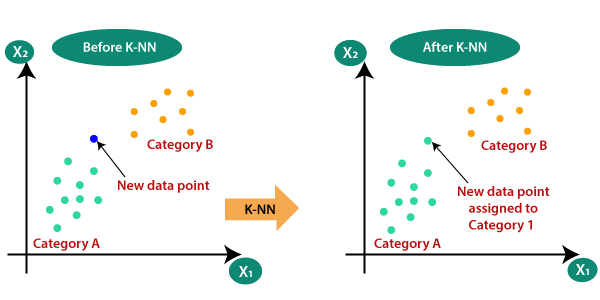

**Fonte:** *K-Nearest Neighbor ($k$-NN) Algorithm for Machine Learning* | Javatpoint (2026).

**(I) Métricas de Distância**

No algoritmo $k$-Nearest Neighbors, a métrica de distância constitui um componente estrutural do procedimento de classificação, pois define a noção de similaridade entre observações e estabelece a vizinhança local associada a cada ponto do espaço de características. Diferentes escolhas de métrica implicam distintas estruturas de vizinhança, com impacto direto sobre o comportamento do classificador. Nesse contexto, as métricas de distância mais comumente empregadas incluem:

- **(a) Euclidiana (ou norma $\ell_2$)**: Representa a distância “em linha reta” (distância geométrica) entre dois pontos, isto é,
  $$\begin{align}\\
  d_{\text{euclid}}(x, x_i) = \sqrt{\sum_{j \ = \ 1}^{p} (x_j - x_{ij})^2}\\\\
  \end{align}$$
- **(b) Manhattan (ou norma $\ell_1$ ou *city-block*)**: Corresponde ao somatório dos deslocamentos absolutos em cada coordenada, isto é,
  $$\begin{align}\\
  d_{\text{manhattan}}(x, x_i) = \sum_{j\ = \ 1}^{p} |x_j - x_{ij}|\\\\
  \end{align}$$
- **(c) Distância de Minkowski**: Métrica geral de dissimilaridade em espaços vetoriais multidimensionais que engloba, como casos particulares, a distância de Manhattan $(q = 1)$ e a distância de Euclidiana $(q=2)$, sendo dada por:
  $$\begin{align}\\
  d_{\text{minkowski}}(x, x_i) = \left( \sum_{j\ = \ 1}^{p} |x_j - x_{ij}|^q \right)^{1/q}\\\\
  \end{align}$$
- **(d) Distância de Chebyshev (ou norma $\ell_\infty$)**: Mede apenas a maior diferença absoluta entre as coordenadas, isto é,
  $$\begin{align}\\
  d_{\text{chebyshev}}(x, x_i) = \max_{1 \ \leqslant \ j \ \leqslant \ p} |x_j - x_{ij}|\\\\
  \end{align}$$
- **(e) Distância de Canberra**: Define-se como a soma das diferenças absolutas normalizadas pela soma das coordenadas correspondentes, isto é,
  $$\begin{align}\\
  d_{\text{canberra}}(x, x_i) = \sum_{j \ = \ 1}^{p} \frac{|x_j - x_{ij}|}{|x_j| + |x_{ij}|}\\\\
  \end{align}$$

**(II) Escolha do Parâmetro $k$**

Além das métricas de distância, outra questão relevante no algoritmo $k$-Nearest Neighbors é a determinação do valor do parâmetro $k$, correspondente ao número de vizinhos considerados no processo de classificação. Uma abordagem para essa tarefa consiste na utilização de *validação cruzada em $m$ folds*. Para tal, suponha-se que o conjunto de treinamento contenha $n_{\text{train}}$ observações e seja particionado em $m$ subconjuntos disjuntos $D_1, D_2, \dots, D_m$. Para cada valor candidato de $k$, procede-se da seguinte forma:

- **1º Passo**: Um dos subconjuntos $D_j$ é separado e utilizado como conjunto de validação, enquanto os $m-1$ subconjuntos restantes constituem o conjunto de treinamento temporário.
- **2º Passo**: O classificador $k$-NN é ajustado com base nos $m-1$ subconjuntos de treinamento e avaliado sobre o conjunto de validação $D_j$, resultando em uma medida de desempenho $E_j(k)$, como o erro de classificação ou a acurácia.
- **3º Passo**: O procedimento é repetido para $j = 1, \dots, m$, e o desempenho global associado ao valor $k$ é estimado por meio do erro médio de validação cruzada, dado por:
  $$\begin{align}\\
  E_{\text{CV}}(k) = \frac{1}{m} \sum_{j=1}^{m} E_j(k)\\\\
  \end{align}$$
  O valor ótimo de $k$ é então determinado como aquele que *minimiza o erro médio de validação cruzada*, isto é,
  $$\begin{align}\\
  k_{\text{opt}} = \arg \min_{k} E_{\text{CV}}(k)\\\\
  \end{align}$$

Como alternativa à validação cruzada, pode-se recorrer a *regras heurísticas* para a escolha do valor de $k$. Na prática, a mais comum dessas regras é definir o valor de $k$ por $k \approx \sqrt{n_{\text{train}}}$, em que $n_{\text{train}}$ denota o número de observações no conjunto de treinamento. Essa escolha, em particular, fornece um valor inicial que busca equilibrar a sensibilidade local do método com maior estabilidade global, embora não assegure desempenho ótimo em todos os contextos de aplicação.

**(III) Classificação de Novas Instâncias**

Considere um conjunto de treinamento definido por:
$$\begin{align}\\
\mathcal{D} = \{(x_1, y_1), (x_2, y_2), \dots, (x_{n_{\text{train}}}, y_{n_{\text{train}}})\}\\\\
\end{align}$$
onde $x_i \in \mathbb{R}^p$ denota o vetor de características do $i$-ésimo exemplo e $y_i \in \{1, 2, \dots, C\}$ representa sua respectiva classe, sendo $C$ o número total de classes. Assim, dado um novo ponto $\tilde x \in \mathbb{R}^p$, o algoritmo $k$-NN atribui sua classe com base na proximidade de $\tilde x$ às observações do conjunto $\mathcal{D}$, seguindo as etapas:

- **(a) Cálculo das Distâncias**: Para cada ponto de treinamento $x_i$, calcula-se a distância $d(\tilde x, x_i)$ (por exemplo, Euclidiana, Manhattan ou Minkowski). A partir dessas distâncias, seleciona-se o subconjunto,
  $$\begin{align}\\
  \mathcal{N}_k(\tilde x) = \{\tilde x_{(1)}, \tilde x_{(2)}, \dots, \tilde x_{(k)}\}\\\\
  \end{align}$$
  correspondente aos $k$ pontos de treinamento com menores distâncias a $\tilde x$.
- **(b) Votação Majoritária**: O ponto $\tilde x$ é classificado de acordo com a classe mais frequente entre seus $k$ vizinhos:
  $$\begin{align}\\
  \hat{y} = \arg\max_{c \ \in \ \{1, \dots, C\}} \sum_{x_i \ \in \ \mathcal{N}_k(\tilde x)} \mathbb{I}_{\{y_i = c\}}\\\\
  \end{align}$$
  onde $\mathbb{I}_{\{y_i \ =\ c\}}$ é a função indicadora, igual a 1 se $y_i = c$ e 0 caso contrário. Em caso de empate entre duas ou mais classes, adota-se como critério de desempate a classe associada ao vizinho mais próximo de $\tilde x$ dentre os $k$ considerados. Persistindo o empate, a classe é selecionada segundo uma regra pré-definida, como a escolha aleatória uniforme entre as classes empatadas.

**(IV) Implementação Computacional**

Conforme discutido anteriormente, o algoritmo $k$-NN fundamenta-se na hipótese de que observações semelhantes tendem a ocupar regiões próximas em um espaço de características de dimensão possivelmente elevada, sendo a decisão de classificação determinada pela proximidade entre pontos, quantificada por meio de uma métrica de distância previamente definida. Embora diversas plataformas computacionais ofereçam implementações eficientes do método, esses ambientes tendem a impor restrições à escolha e à parametrização das métricas de distância, assim como à forma de construção da vizinhança e à definição da regra de decisão. Em determinadas aplicações, tais restrições reduzem o controle do pesquisador sobre o procedimento de classificação. Nesse contexto, a implementação computacional própria do algoritmo constitui alternativa adequada, pois permite controle direto sobre a métrica de distância, a formação da vizinhança e a regra de decisão adotada. O Código 4.3 apresenta um pseudocódigo que ilustra essa implementação para tarefas de classificação.

**Código 4.3.** Pseudocódigo do algoritmo $k$-NN para tarefas de classificação supervisionada.

**Input**

$\quad$ **1:** $\mathcal{D}_{\mathrm{train}}=\{(x_j,y_j)\}_{j=1}^{n_{\mathrm{train}}}$ com $x_j \in \mathbb{R}^d$ e $y_j\in\{1,\ldots,C\}$;  
$\quad$ **2:** $\mathcal{D}_{\mathrm{test}}=\{\tilde{x}_i\}_{i=1}^{n_{\mathrm{test}}}$ com $\tilde{x}_i \in \mathbb{R}^d$;  
$\quad$ **3:** $n_{\mathrm{train}}$ (número total de instâncias no conjunto de treino);  
$\quad$ **4:** $n_{\mathrm{test}}$ (número total de instâncias no conjunto de teste);  
$\quad$ **5:** $d$ (métrica de distância);  
$\quad$ **6:** $\mathrm{weighted}\in\{0,1\}$ (controla a forma de agregação do voto);  
$\quad$ **7:** $C$ (número de classes).

**Execution**

$\quad$ **8:** Inicialize $\widehat{\mathbf{y}} \in \{1,\ldots,C\}^{n_{\mathrm{test}}}$  
$\quad$ **9:** **for** $i = 1, \ldots, n_{\mathrm{test}}$ **do**  
$\quad$ **10:** $\qquad$ Inicialize $\mathbf{d} \in \mathbb{R}^{n_{\mathrm{train}}}$  
$\quad$ **11:** $\qquad$ **for** $j = 1, \ldots, n_{\mathrm{train}}$ **do**  
$\quad$ **12:** $\qquad\qquad$ $\mathbf{d}_j \gets d(x_j,\tilde{x}_i)$  
$\quad$ **13:** $\qquad$ **end for**  
$\quad$ **14:** $\qquad$ $\mathcal{N}_k(\tilde{x}_i) \gets$ índices dos $k$ menores valores de $\mathbf{d}$  
$\quad$ **15:** $\qquad$ **if** $\mathrm{weighted}=0$ **then**  
$\quad$ **16:** $\qquad\qquad$ $\hat{f}(\tilde{x}_i) \gets \arg\max\limits_{c\in\{1,\ldots,C\}} \sum\limits_{j \in \mathcal{N}_k(\tilde{x}_i)} \mathbb{I}(y_j=c)$  
$\quad$ **17:** $\qquad$ **else**  
$\quad$ **18:** $\qquad\qquad$ **for all** $j \in \mathcal{N}_k(\tilde{x}_i)$ **do**  
$\quad$ **19:** $\qquad\qquad\qquad$ $w_j \gets \dfrac{1}{\mathbf{d}_j}$  
$\quad$ **20:** $\qquad\qquad$ **end for**  
$\quad$ **21:** $\qquad\qquad$ $\hat{f}(\tilde{x}_i) \gets \arg\max\limits_{c\in\{1,\ldots,C\}} \sum\limits_{j \in \mathcal{N}_k(\tilde{x}_i)} w_j\,\mathbb{I}(y_j=c)$  
$\quad$ **22:** $\qquad$ **end if**  
$\quad$ **23:** $\qquad$ $\widehat{\mathbf{y}}_i \gets \hat{f}(\tilde{x}_i)$  
$\quad$ **24:** **end for**  
$\quad$ **25:** **return** $\widehat{\mathbf{y}}$

**Output**

$\quad$ **26:** Vetor de predições $\widehat{\mathbf{y}} \in \{1,\ldots,C\}^{n_{\mathrm{test}}}$, em que $\widehat{\mathbf{y}}_i = \hat{f}(\tilde{x}_i)$

**Fonte:** Elaborado pelo autor (2026).

Atividade Prática 4.3

Com base no Código 4.3, implemente, em R, uma função para executar o algoritmo $k$-NN em problemas de *classificação supervisionada*. A implementação deve conter a definição explícita dos argumentos de *entrada* e de *saída*, os quais determinam (i) os objetos utilizados nas etapas de treinamento e de predição, (ii) a métrica de dissimilaridade empregada no cálculo da proximidade entre observações, e (iii) a forma como o resultado da classificação é retornado ao usuário. Nesse contexto, os *argumentos de entrada* da função devem incluir:

- `train`: matriz (`matrix`) ou quadro de dados (`data.frame`) contendo as observações do conjunto de treinamento.
- `test`: matriz (`matrix`) ou quadro de dados (`data.frame`) contendo as observações do conjunto de teste.
- `tr.class`: objeto contendo os rótulos de classe associados às observações do conjunto de treinamento.
- `te.class`: objeto contendo os rótulos de classe associados às observações do conjunto de teste.
- `k`: número de vizinhos considerados no processo de classificação.
- `dist`: métrica de distância utilizada no cálculo da similaridade entre observações.
- `lambda`: parâmetro da distância de Minkowski, especificado apenas quando `dist = "minkowski"`.
- `show_cm_plot`: indicador lógico que define se a representação gráfica da *matriz de confusão* deve (`TRUE`) ou não (`FALSE`) ser exibida.

Para o teste da implementação, utilize o conjunto de dados `iris`, coletado pelo estatístico e geneticista britânico Sir Ronald Aylmer Fisher (R. A. Fisher 1936), amplamente empregado como exemplo clássico na literatura de aprendizado estatístico. O conjunto de dados contém medições morfológicas de flores do gênero *Iris*, abrangendo três espécies distintas — *Iris setosa*, *Iris versicolor* e *Iris virginica* — cujas diferenças estão associadas, sobretudo, às dimensões das sépalas e pétalas. Neste problema, considere como variáveis explicativas as medidas morfológicas das plantas e como variável resposta a espécie da flor. O objetivo é avaliar o desempenho do algoritmo $k$-NN na tarefa de classificação supervisionada, atribuindo corretamente a espécie a partir das variáveis explicativas, com base em uma amostra previamente rotulada. Para tal, particione a base de dados segundo o *método hold-out*, destinando $70\%$ das observações ao conjunto de treinamento e os $30\%$ restantes ao conjunto de teste. Além disso, devem ser consideradas as seguintes configurações do algoritmo:

- o número de vizinhos $k \in \{3,5,7,9,11\}$;
- a métrica de distância utilizada para o cálculo da proximidade entre observações.

Por fim, o desempenho preditivo do modelo, para cada combinação dessas configurações, deve ser avaliado com base nas medidas de desempenho apresentadas na Seção 4.4.

**(V) Bibliotecas do R**

Como alternativa à implementação computacional direta do algoritmo $k$-NN, o ambiente R disponibiliza diversas bibliotecas que diferem quanto ao nível de automatização, ao grau de abstração algorítmica e à integração com rotinas de avaliação preditiva. Em geral, essas bibliotecas oferecem implementações otimizadas e padronizadas do k-NN, reduzindo o esforço de codificação manual e permitindo que a análise se concentre no ajuste do parâmetro $k$ e na avaliação do desempenho preditivo (Lantz 2019). Contudo, muitas dessas bibliotecas impõem limitações metodológicas, sobretudo no que se refere à escolha da métrica de distância, que frequentemente é fixa ou restrita a um conjunto reduzido de opções, o que pode restringir a flexibilidade do método em aplicações que demandam diferentes noções de similaridade.

**Biblioteca `FNN`**

A biblioteca `FNN` (*Fast Nearest Neighbor Search Algorithms and Applications* – Beygelzimer et al. 2024) fornece implementações eficientes do algoritmo $k$-NN, com ênfase em desempenho computacional e escalabilidade. Seu foco principal reside em algoritmos rápidos de busca por vizinhos mais próximos, o que a torna adequada para aplicações envolvendo conjuntos de dados de grande porte ou alta dimensionalidade.

- **Função**: `knn()`
- **Argumentos**:
  - `train`: matriz (`matrix`) ou quadro de dados (`data.frame`) correspondente ao conjunto de treinamento.
  - `test`: matriz (`matrix`) ou quadro de dados (`data.frame`) correspondente ao conjunto de teste.
  - `cl`: vetor contendo as classes associadas às observações do conjunto de treinamento.
  - `k`: número de vizinhos considerados na regra de decisão.
  - `algorithm`: método utilizado na busca dos vizinhos mais próximos (`kd_tree`, `cover_tree`, `brute`).

Atividade Prática 4.4

Para a aplicação do algoritmo $k$-NN em um contexto de *classificação supervisionada* utilizando a biblioteca `FNN`, considere o conjunto de dados `iris`. Nesse conjunto, assuma como variável resposta a espécie da flor, representada por `Species`, e como variáveis explicativas as medidas morfológicas `Sepal.Length`, `Sepal.Width`, `Petal.Length` e `Petal.Width`. A prática deve ser conduzida de acordo com as seguintes instruções:

- Particionar o conjunto de dados em conjuntos de treinamento e teste, por exemplo, nas proporções de $70\%$ e $30\%$;
- Ajustar um classificador $k$-NN por meio da função `knn()` (biblioteca `FNN`);
- Investigar diferentes configurações do algoritmo, variando:
  - o número de vizinhos $k$ (por exemplo, $k \in {3,5,7,9,11}$);
  - a métrica de distância utilizada para o cálculo da proximidade entre observações;
  - a padronização prévia ou não das variáveis explicativas;
- Obter as predições de `Species` no conjunto de teste para cada configuração considerada e comparar o desempenho preditivo com base em medidas de avaliação para classificação discutidas Seção 4.4.

**Biblioteca `kknn`**

A biblioteca `kknn` (Schliep e Hechenbichler 2016) implementa o método $k$-NN a partir de uma formulação baseada em funções de núcleo (*kernel*), na qual a contribuição dos vizinhos é ponderada em função da distância ao ponto de interesse. Essa abordagem generaliza o procedimento clássico ao empregar esquemas de ponderação contínuos, permitindo maior controle sobre a influência relativa dos vizinhos e resultando em uma regra de decisão mais suave.

- **Função**: `kknn()`
- **Argumentos**:
  - `formula`: fórmula que descreve a relação entre a variável resposta categórica e as variáveis explicativas.
  - `train`: quadro de dados (`data.frame`) correspondente ao conjunto de treinamento.
  - `test`: quadro de dados (`data.frame`) correspondente ao conjunto de teste.
  - `k`: número de vizinhos considerados no processo de estimação.
  - `distance`: parâmetro associado à distância de Minkowski.
  - `kernel`: função de ponderação empregada na agregação dos vizinhos (por exemplo, `rectangular`, `triangular`, `epanechnikov`, `gaussian`).
  - `scale`: indicador lógico que define se as variáveis explicativas devem ser padronizadas antes do cálculo das distâncias.

Atividade Prática 4.5

Para a aplicação do algoritmo $k$-NN em um contexto de *classificação supervisionada* utilizando a biblioteca `kknn`, considere o conjunto de dados `SAheart`, disponibilizado na biblioteca `ElemStatLearn`. Nesse conjunto, assuma como variável resposta a presença de doença cardíaca coronariana, representada por `chd`, e como variáveis explicativas os fatores de risco cardiovasculares `sbp`, `tobacco`, `ldl`, `adiposity`, `famhist`, `typea`, `obesity`, `alcohol` e `age`. A prática deve ser conduzida de acordo com as seguintes instruções:

- Particionar o conjunto de dados em conjuntos de treinamento e teste, por exemplo, nas proporções de $70\%$ e $30\%$;
- Ajustar um classificador $k$-NN por meio da função `kknn()` (biblioteca `kknn`), especificando a relação entre a variável resposta e as variáveis explicativas via uma fórmula do tipo `chd ~ sbp + tobacco + ldl + adiposity + famhist + typea + obesity + alcohol + age`;
- Investigar diferentes configurações do algoritmo, variando:
  - o número de vizinhos $k$ (por exemplo, $k \in {3,5,7,9,11}$);
  - a métrica de distância utilizada no cálculo da proximidade entre observações (por exemplo, por meio do parâmetro `distance`, com destaque para a família de Minkowski);
  - o critério de agregação empregado na decisão de classe, considerando voto não ponderado e voto ponderado pela distância (por exemplo, via o argumento `kernel`);
  - a padronização prévia ou não das variáveis explicativas;
- Obter as predições de `chd` no conjunto de teste para cada configuração considerada e comparar o desempenho preditivo com base nas medidas de avaliação para classificação discutidas na Seção 4.4.

**Biblioteca `caret`**

A biblioteca `caret` (*Classification and Regression Training* – Kuhn 2008) para o $k$-NN, atua como um *framework* de treinamento que integra rotinas de pré-processamento, seleção de hiperparâmetros e avaliação de desempenho, automatizando a escolha do número de vizinhos $k$ por meio de técnicas de reamostragem, como validação cruzada. Em contrapartida, essa abordagem oferece menor flexibilidade para a especificação direta de métricas de distância, quando comparada a implementações dedicadas do $k$-NN.

- **Função**: `train()`
- **Argumentos**:
  - `x`, `y` ou `formula`: especificação da relação entre a variável resposta e as variáveis explicativas, podendo ser feita por meio do par variáveis explicativas–resposta (`x`, `y`) ou por uma interface baseada em fórmula (por exemplo, `$y \sim x_1 + x_2$`). A interface `x`, `y` é, em geral, preferida por razões de eficiência computacional.
  - `data`: quadro de dados (`data.frame`) contendo as variáveis especificadas em `formula`, correspondente ao conjunto de treinamento.
  - `method`: método a ser utilizado no treinamento; para classificação via $k$-NN, adota-se `"knn"`.
  - `trControl`: objeto que define os parâmetros de controle do processo de treinamento, incluindo a estratégia de reamostragem e as métricas de avaliação do desempenho preditivo.
  - `tuneGrid`: quadro de dados (`data.frame`) que especifica os valores candidatos para o ajuste dos hiperparâmetros do modelo, em particular o número de vizinhos $k$.
  - `tuneLength`: inteiro que denota o número de níveis padrão a serem gerados automaticamente para cada hiperparâmetro do modelo, controlando a granularidade da busca automática por hiperparâmetros quando `tuneGrid` não é especificado.
  - `preProcess` (opcional): conjunto de operações de pré-processamento aplicadas às variáveis preditoras, como centralização e padronização, especialmente relevantes em métodos baseados em distância.
  - `metric`: critério utilizado para selecionar o melhor modelo durante o processo de reamostragem.

Atividade Prática 4.6

Para a aplicação do algoritmo $k$-NN em um contexto de *classificação supervisionada* utilizando a biblioteca `caret`, considere a base de dados `biopsy`, que reúne informações de biópsias de tumores mamários avaliadas no Hospital da Universidade de Wisconsin. Nesse conjunto, a variável resposta indica a classe do tumor, representada por `class`, com categorias *benign* e *malignant*, enquanto as variáveis explicativas correspondem aos atributos citológicos `V1` (espessura do aglomerado celular), `V2` (uniformidade do tamanho das células), `V3` (uniformidade do formato das células), `V4` (adesão marginal), `V5` (tamanho das células epiteliais únicas), `V6` (núcleos nus), `V7` (cromatina branda), `V8` (nucléolos normais) e `V9` (mitoses), todos mensurados em escalas ordinais de 1 a 10. A prática deve ser conduzida de acordo com as seguintes instruções:

- Realizar o pré-processamento dos dados, contemplando:
  - a remoção ou tratamento das observações com valores ausentes, em especial na variável `V6`;
  - a exclusão da variável identificadora `ID`, quando apropriado;
- Particionar o conjunto de dados em conjuntos de treinamento e teste, por exemplo, nas proporções de $70\%$ e $30\%$, garantindo a preservação das proporções das classes;
- Ajustar um classificador $k$-NN por meio da função `train()` da biblioteca `caret`, especificando `method = "knn"` e utilizando uma formulação do tipo `class ~ V1 + V2 + V3 + V4 + V5 + V6 + V7 + V8 + V9`;
- Investigar diferentes configurações do algoritmo, variando:
  - o número de vizinhos $k$ (por exemplo, $k \in {3,5,7,9,11}$), por meio do parâmetro de *tuning* do modelo;
  - a padronização prévia das variáveis explicativas, considerando procedimentos como centralização e escalonamento;
  - a estratégia de reamostragem adotada no ajuste, como validação cruzada $K$-*fold*;
- Obter as predições da variável `class` no conjunto de teste para o melhor modelo selecionado e avaliar o desempenho preditivo com base nas medidas de avaliação para classificação discutidas na Seção 4.4.

### 4.6.2. Regressão Logística

No âmbito do aprendizado de máquinas, a *regressão logística* (Hosmer e Lemeshow 2000) configura-se como um modelo estatístico empregado para a resolução de *problemas de classificação binária*, nos quais a variável resposta assume dois estados mutuamente exclusivos (por exemplo, “sim” ou “não”, “positivo” ou “negativo”, etc). Este modelo, em particular, baseia-se na *função logística*, também denominada *função sigmoide*, cuja finalidade é mapear uma combinação linear das variáveis preditoras em uma probabilidade associada à classe de interesse. Esse mapeamento assegura que as previsões do modelo pertençam ao intervalo $[0,1]$, o que viabiliza sua interpretação probabilística. Formalmente, a função logística é expressa por:
$$\begin{align}\\
\sigma(z)= \dfrac{1}{1 +\exp(-z)}\\\\
\end{align}$$
em que $z$ representa o *preditor linear*, definido como uma combinação linear dos atributos explicativos do modelo. A Figura 4.6 ilustra o comportamento da *função sigmoide* para valores distintos de $z$, evidenciando seu característico formato em “S”. Além do formato em “S”, outro aspecto aspecto importante dessa função é seu comportamento assintótico (Hosmer e Lemeshow 2000), isto é,

- Quando $z \rightarrow \infty$, tem-se $\sigma(z) \rightarrow 1$;
- Quando $z \rightarrow -\infty$, $\sigma(z) \rightarrow 0$.

Essa propriedade garante que a função esteja *sempre limitada ao intervalo $[0,1]$*, o que permite interpretar sua saída como uma *probabilidade*. Essa interpretação probabilística define a atribuição de classes de acordo com $P(Y = 1 \mid X) = \sigma(z)$ e $P(Y = 0 \mid X) = 1 - \sigma(z)$, de modo que a classe de uma nova instância é determinada pela *classe de maior probabilidade*.

**Figura 4.6.** Ilustração do comportamento da *função sigmoide* para diferentes valores de $z$.

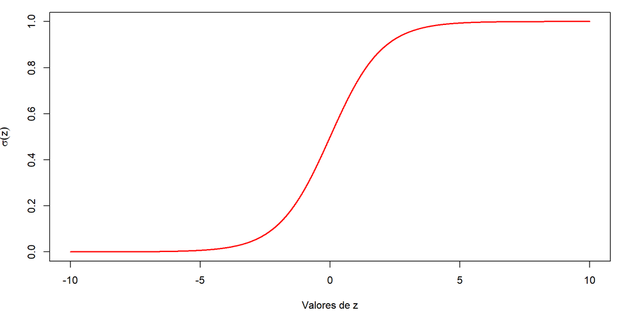

**Fonte:** Elaborado pelo autor (2026).

Na presença de múltiplas variáveis independentes $X_i$ ($i = 1,\ldots, m$) torna-se necessário reformular a *função sigmoide* em termos do preditor linear $z = \beta_0 + \beta_1 X_1 + \ldots + \beta_m X_m$ incorporando o efeito conjunto dos atributos explicativos. Nessa configuração, a *função de decisão da regressão logística* pode ser expressa como:
$$\begin{align}\\
h_\beta(x) = \frac{1}{1 + \exp\big\{-\beta_0 + \beta_1 X_1 + \ldots + \beta_m X_m\big\}}\\\\
\end{align}$$
em que $\beta_0$ representa o *intercepto* do modelo, e $\beta_i$ ($i = 1,\ldots,m$) denotam os *coeficientes de regressão* associados às variáveis independentes $X_i$. Para esste modelo, o processo de treinamento tem por objetivo estimar os parâmetros $\beta_j$ ($j = 0,1,\ldots,m$) de modo a estabelecer uma relação funcional entre o vetor de entradas $X$ e a probabilidade de pertencimento à *classe positiva*, isto é, isto é, à ocorrência do evento de interesse (Hastie, Tibshirani, e Friedman 2009; Alpaydin 2021). Para estimar tais parâmetros, uma das abordagens mais comuns na literatura é o método do *gradiente descendente* (Hastie, Tibshirani, e Friedman 2009), cujo objetivo consiste na *minimização* de uma *função de custo*. Em problemas de classificação binária, essa função, denotada $\mathcal{J}(\beta)$, é definida como o negativo do logaritmo da função de verossimilhança associada ao modelo logístico, resultando na conhecida *função de entropia cruzada*. Tal função é expressa por:
$$\begin{align}\\
\mathcal{J}(\beta) = -\frac{1}{m} \sum_{i=1}^{m} \Big\{ y^{(i)} \log\left[h_\beta\left(x^{(i)}\right)\right] + \left(1 - y^{(i)}\right) \log\left[1 - h_\beta\left(x^{(i)}\right)\right] \Big\}\\\\
\end{align}$$
em que $m$ representa o número de instâncias, $y^{(i)} \in \{0,1\}$ representa o rótulo da $i$-esima instância, e $h_\beta(x^{(i)})$ corresponde à probabilidade estimada de pertencimento à classe positiva. Vide regra, valores menores de $\mathcal{J}(\beta)$ indicam maior aderência do modelo aos dados observados. O gradiente dessa função em relação ao vetor de parâmetros $\beta = (\beta_0, \beta_1, \ldots, \beta_m)$ é dado por:
$$\begin{align}\\
\nabla_\beta \mathcal{J}(\beta) = \frac{1}{m} \sum_{i=1}^{m} \big( h_\beta(x^{(i)}) - y^{(i)} \big) x^{(i)}\\\\
\end{align}$$
o que conduz a um esquema iterativo de atualização dos parâmetros segundo a regra:
$$\begin{align}\\
\beta \leftarrow \beta - \alpha \nabla_\beta \mathcal{J}(\beta)\\\\
\end{align}$$
em que $\alpha$ é a *taxa de aprendizado*, responsável por controlar a magnitude do deslocamento a cada iteração (Hastie, Tibshirani, e Friedman 2009). Como a função de custo associada à regressão logística é convexa, o gradiente aponta a direção de máximo crescimento da função, de modo que a atualização no sentido oposto conduz à redução de $\mathcal{J}(\beta)$ e à convergência para a solução ótima global. Essa formulação conjunta da função de custo e do procedimento de otimização fundamenta o processo de treinamento do modelo de regressão logística (Hastie, Tibshirani, e Friedman 2009).

**(I) Classificação de Novas Instâncias**

Considere um conjunto de treinamento,
$$\begin{align}\\
\mathcal{D} = \{(x_1, y_1), (x_2, y_2), \dots, (x_{n_{\text{train}}}, y_{n_{\text{train}}})\}\\\\
\end{align}$$
em que $x_i \in \mathbb{R}^p$ representa o vetor de características associado ao $i$-ésimo exemplo e $y_i \in \{0,1\}$ denota o rótulo de classe correspondente. Dado um novo ponto $x \in \mathbb{R}^p$, o algoritmo de regressão logística realiza a classificação desse ponto a partir das etapas:

- **(a) Cálculo da Probabilidade de Classe**: Para cada instância $x_i$, a regressão logística modela a probabilidade de pertencimento à classe positiva ($y_i = 1$)por meio da função logística, dada por:
  $$\begin{align}\\
  P(y_i=1 \mid x_i) = \sigma(z_i) = \frac{1}{1 + e^{-z_i}}, \quad z_i = \beta_0 + \sum_{j=1}^{p} \beta_j x_{ij}\\\\
  \end{align}$$
  em que $\beta_0$ representa o intercepto do modelo, $\beta_j$ são os coeficientes associados às características $x_{ij}$, $\sigma(\cdot)$ denota a função sigmoide, e $z_i$ corresponde ao preditor linear, frequentemente referido como *logit*.
- **(b) Estimação dos Coeficientes**: Os parâmetros $\boldsymbol{\beta} = (\beta_0, \beta_1, \dots, \beta_p)$ são estimados de modo a maximizar a verossimilhança dos dados observados. Equivalentemente, essa estimação pode ser formulada como um *problema de minimização da função de custo* definida como o negativo da log-verossimilhança média, expressa por:
  $$\begin{align}\\
  \mathcal{J}(\boldsymbol{\beta}) = - \frac{1}{n_{\text{train}}} \sum_{i=1}^{n_{\text{train}}} \Big[ y_i \log h_\beta(x_i) + (1 - y_i) \log (1 - h_\beta(x_i)) \Big]\\\\
  \end{align}$$
  em que $h_\beta(x_i) = \sigma(z_i)$ representa a probabilidade prevista pelo modelo para a $i$-ésima instância, com $z_i = \beta_0 + \sum_{j=1}^{p} \beta_j x_{ij}$. A solução ótima do problema é, portanto, dada por:
  $$\begin{align}\\
  \hat{\boldsymbol{\beta}} = \arg \min_{\boldsymbol{\beta}} \mathcal{J}(\boldsymbol{\beta})\\\\
  \end{align}$$
- **(c) Predição de Novas Instâncias**: Dado um novo ponto $x \in \mathbb{R}^p$, o modelo de regressão logística calcula a probabilidade estimada de pertencimento à classe positiva com base nos coeficientes ajustados $\hat{\boldsymbol{\beta}}$, isto é,
  $$\begin{align}\\
  \hat{P}(y=1 \mid x) = \frac{1}{1 + e^{-(\hat{\beta}_0 + \sum_{j=1}^{p} \hat{\beta}_j x_j)}}\\\\
  \end{align}$$
  Aqui, a função sigmoide garante que esta probabilidade esteja sempre no intervalo $[0,1]$, permitindo sua interpretação probabilística. A decisão final de classificação é obtida pela comparação dessa probabilidade com um *limiar de decisão* $\tau$ segundo a regra:
  $$\begin{align}\\
  \hat{y} =
  \begin{cases}
  1, & \text{se } \hat{P}(y=1 \mid x) \geqslant \tau, \\\\
  0, & \text{caso contrário}.
  \end{cases}\\\\
  \end{align}$$
  Usualmente, adota-se $\tau = 0,5$, embora esse valor possa ser ajustado conforme o objetivo da análise, de modo a controlar o *trade-off* entre sensibilidade e especificidade. Em particular, valores menores de $\tau$ tendem a aumentar a sensibilidade, ao passo que valores maiores favorecem a especificidade (Hosmer e Lemeshow 2000; Hastie, Tibshirani, e Friedman 2009).

**(II) Implementação Computacional**

Conforme discutido anteriormente, a regressão logística constitui um método de classificação amplamente empregado em problemas de classificação binária, nos quais a variável resposta assume dois estados mutuamente exclusivos. O modelo fundamenta-se na modelagem da probabilidade condicional de pertencimento à classe de interesse por meio da aplicação da função logística a uma combinação linear das variáveis explicativas. Embora existam diversas implementações computacionais prontas desse modelo, tais abordagens frequentemente impõem restrições quanto à parametrização do procedimento de otimização, à definição da função de custo e aos critérios de convergência, o que pode limitar o controle analítico do pesquisador sobre o processo de classificação. Em determinadas aplicações, essas restrições tornam desejável a implementação computacional direta do modelo, pois esta permite controle explícito sobre a função de custo, o método de otimização e a regra de decisão adotada, além de favorecer uma compreensão mais aprofundada do funcionamento interno do algoritmo. Nesse contexto, o Código 4.4 apresenta um pseudocódigo simplificada da regressão logística voltada a tarefas de classificação binária, com o objetivo de ilustrar seu mecanismo interno e viabilizar ajustes e personalizações conforme a finalidade da análise.

**Código 4.4.** Pseudocódigo do algoritmo de regressão logística para tarefas de classificação binária.

**Input**

$\quad$ **1:** $\mathcal{D}_{\mathrm{train}}=\{(x_i,y_i)\}_{i=1}^{n_{\mathrm{train}}}$ com $x_i\in\mathbb{R}^p$ e $y_i\in\{0,1\}$;  
$\quad$ **2:** $\mathcal{D}_{\mathrm{test}}=\{\tilde{x}_i\}_{i=1}^{n_{\mathrm{test}}}$ com $\tilde{x}_i\in\mathbb{R}^p$;  
$\quad$ **3:** $n_{\mathrm{train}}$ (número total de instâncias no conjunto de treino);  
$\quad$ **4:** $n_{\mathrm{test}}$ (número total de instâncias no conjunto de teste);  
$\quad$ **5:** $\tau\in(0,1)$ (limiar de decisão);  
$\quad$ **6:** $\sigma(z)=\dfrac{1}{1+e^{-z}}$ (função sigmoide).

**Execution**

$\quad$ **7:** Inicialize o vetor de parâmetros $\boldsymbol{\beta}=(\beta_0,\beta_1,\ldots,\beta_p)$  
$\quad$ **8:** Estime $\hat{\boldsymbol{\beta}} \gets \arg\min_{\boldsymbol{\beta}} \mathcal{J}(\boldsymbol{\beta})$, em que  
$\quad$ **9:** $\qquad$ $\mathcal{J}(\boldsymbol{\beta})=-\dfrac{1}{n_{\mathrm{train}}}\sum_{i=1}^{n_{\mathrm{train}}}\left[y_i\log h_\beta(x_i)+(1-y_i)\log(1-h_\beta(x_i))\right]$  
$\quad$ **10:** $\qquad$ $h_\beta(x_i)=\sigma\!\left(\beta_0+\sum_{j=1}^{p}\beta_j x_{ij}\right)$

$\quad$ **11:** Inicialize $\widehat{\mathbf{y}}\in\{0,1\}^{n_{\mathrm{test}}}$  
$\quad$ **12:** **for** $i=1,\ldots,n_{\mathrm{test}}$ **do**  
$\quad$ **13:** $\qquad$ Calcule $\hat{P}(y=1\mid \tilde{x}_i)\gets \sigma\!\left(\hat{\beta}_0+\sum_{j=1}^{p}\hat{\beta}_j \tilde{x}_{ij}\right)$  
$\quad$ **14:** $\qquad$ **if** $\hat{P}(y=1\mid \tilde{x}_i)\geqslant \tau$ **then**  
$\quad$ **15:** $\qquad\qquad$ $\widehat{\mathbf{y}}_i\gets 1$  
$\quad$ **16:** $\qquad$ **else**  
$\quad$ **17:** $\qquad\qquad$ $\widehat{\mathbf{y}}_i\gets 0$  
$\quad$ **18:** $\qquad$ **end if**  
$\quad$ **19:** **end for**  
$\quad$ **20:** **return** $\widehat{\mathbf{y}}$

**Output**

$\quad$ **21:** Vetor de rótulos preditos $\widehat{\mathbf{y}}\in\{0,1\}^{n_{\mathrm{test}}}$.

**Fonte:** Elaborado pelo autor (2026).

Atividade Prática 4.7

Com base no Código 4.4, implemente, em R, uma função para executar o algoritmo de *regressão logística* em problemas de *classificação binária*. A implementação deve conter a definição explícita dos argumentos de *entrada* e de *saída*, os quais determinam (i) os objetos utilizados nas etapas de ajuste do modelo e de predição, (ii) as escolhas de otimização e os critérios de convergência adotados para a estimação dos parâmetros, e (iii) a forma como as probabilidades estimadas e os rótulos preditos são retornados ao usuário. Nesse contexto, os *argumentos de entrada* da função devem incluir:

- `data`: matriz (`matrix`) ou quadro de dados (`data.frame`) contendo as observações e as variáveis do estudo.
- `response_var`: nome da variável resposta (rótulo) associada à tarefa de classificação binária no conjunto de dados.
- `predictors`: vetor contendo os nomes das variáveis preditoras a serem incluídas no modelo.
- `positive_class`: rótulo da classe considerada positiva no problema de classificação binária; as demais categorias são tratadas como classe negativa.
- `alpha`: valor do parâmetro $\alpha$ (taxa de aprendizado) empregado no método do gradiente descendente.
- `num_iters`: número máximo de iterações do algoritmo de gradiente descendente, utilizado como limite computacional superior para o processo de otimização.
- `tol`: valor do limiar de tolerância adotado como critério de convergência; o algoritmo é interrompido quando a variação absoluta da função de custo entre iterações sucessivas é inferior a esse valor.
- `test_ratio`: proporção destinada ao conjunto de teste na partição dos dados; por exemplo, `test_ratio = 0.2` indica que 20% das observações compõem o conjunto de teste e 80% o conjunto de treinamento.
- `tau`: limiar de decisão empregado na conversão das probabilidades preditas em rótulos de classe, sendo tipicamente fixado em $\tau = 0.5$, mas ajustável conforme o objetivo da análise.
- `seed`: valor utilizado para inicialização da semente do gerador de números aleatórios, garantindo reprodutibilidade na divisão dos dados em treino e teste.
- `show_plots`: valor lógico que indica se as representações gráficas dos resultados (matriz de confusão, curva ROC e curva Precision–Recall) devem (`TRUE`) ou não (`FALSE`) ser exibidas.

Para o teste da implementação, utilize o conjunto de dados `PimaIndiansDiabetes`, disponibilizado na biblioteca `mlbench`, o qual reúne observações clínicas e antropométricas de mulheres adultas da população Pima. Nesse conjunto, considere como variável resposta `diabetes`, com rótulos `pos` (presença do desfecho) e `neg` (ausência do desfecho), e como variáveis explicativas: número de gestações (`pregnant`), concentração de glicose (`glucose`), pressão diastólica (`pressure`), espessura da prega cutânea do tríceps (`triceps`), nível sérico de insulina (`insulin`), índice de massa corporal (`mass`), função pedigree para diabetes (`pedigree`) e idade (`age`). O objetivo é avaliar o desempenho do modelo de regressão logística na atribuição do rótulo de classe a partir das probabilidades estimadas para a classe positiva (`pos`), utilizando uma amostra previamente rotulada. Para esse fim, particione a base segundo o *método hold-out*, destinando $70\%$ das observações ao treinamento do modelo e $30\%$ ao conjunto de teste. Além disso, investigue o comportamento do algoritmo de otimização sob diferentes configurações, considerando cenários que variem:

- A taxa de aprendizado $\alpha$ (por exemplo, $\alpha \in \{0.001, 0.01, 0.05, 0.1\}$);
- O limiar de decisão $\tau$ na conversão de probabilidades em rótulos (por exemplo, $\tau \in \{0.3, 0.5, 0.7\}$);
- A tolerância `tol` como critério de convergência (por exemplo, `tol` $\in \{10^{-6}, 10^{-5}, 10^{-4}\}$);
- O número máximo de iterações `num_iters` (por exemplo, `num_iters` $\in \{500, 1000, 5000, 10000\}$).

Por fim, avalie o desempenho preditivo do modelo, para cada combinação de configurações considerada, com base nas medidas de avaliação para classificação discutidas na Seção 4.4, destacando o impacto conjunto de $\alpha$, `tol` e `num_iters` na convergência e de $\tau$ no compromisso entre sensibilidade e especificidade.

**(III) Bibliotecas do R**

Como alternativa à implementação computacional direta da regressão logística, o ambiente R disponibiliza diversas bibliotecas que diferem quanto ao nível de automatização, ao grau de abstração algorítmica e à integração com rotinas de avaliação preditiva. Em geral, essas bibliotecas oferecem implementações otimizadas e padronizadas do modelo, reduzindo o esforço de codificação manual e permitindo que a análise se concentre na especificação do modelo, na seleção de variáveis explicativas e na interpretação dos coeficientes associados às razões de chances, bem como na avaliação do desempenho preditivo (Lantz 2019). Contudo, muitas dessas bibliotecas impõem limitações metodológicas, sobretudo no que se refere à escolha da função de ligação, às estratégias de regularização e aos critérios de seleção de variáveis, o que pode restringir a flexibilidade do modelo em aplicações que exigem diferentes compromissos entre interpretabilidade, parcimônia e capacidade preditiva.

**Biblioteca `caret`**

A biblioteca `caret` (*Classification and Regression Training* – Kuhn 2008) fornece uma interface unificada para o ajuste, a validação e a comparação de modelos preditivos, incluindo a *regressão logística*, integrando rotinas de pré-processamento, seleção de hiperparâmetros e avaliação de desempenho. No caso específico da regressão logística, o `caret` atua como um framework de treinamento que automatiza a definição do modelo por meio de técnicas de reamostragem, permite a incorporação de estratégias de regularização (como *ridge*, *lasso* e *elastic net*) e padroniza o fluxo analítico, facilitando a comparação entre diferentes especificações do modelo, ainda que com menor controle direto sobre detalhes de estimação em relação a implementações mais especializadas.

- **Função**: `train()`
- **Argumentos**:
  - `x`, `y` ou `formula`: especificação da relação entre a variável resposta e as variáveis explicativas, podendo ser feita por meio do par variáveis explicativas–resposta (`x`, `y`) ou por uma interface baseada em fórmula (por exemplo, `$y \sim x_1 + x_2$`). A interface `x`, `y` é, em geral, preferida por razões de eficiência computacional.
  - `data`: quadro de dados (`data.frame`) contendo as variáveis especificadas em `formula`, correspondente ao conjunto de treinamento.
  - `method`: método a ser utilizado no treinamento; adota-se `"glm"` para regressão logística (isto é, um modelo linear generalizado com família binomial).
  - `trControl`: objeto que define os parâmetros de controle do processo de treinamento, incluindo a estratégia de reamostragem e as métricas de avaliação do desempenho preditivo.
  - `tuneGrid`: quadro de dados (`data.frame`) que especifica valores candidatos para ajuste de hiperparâmetros do modelo; na regressão logística clássica via `"glm"`, em geral não há hiperparâmetros a serem otimizados, de modo que `tuneGrid` pode ser omitido. Em versões penalizadas (por exemplo, via `"glmnet"`), `tuneGrid` pode ser usado para definir valores de $\lambda$ e, quando pertinente, $\alpha$.
  - `tuneLength`: inteiro que denota o número de níveis padrão a serem gerados automaticamente para cada hiperparâmetro do modelo, controlando a granularidade da busca automática por hiperparâmetros quando `tuneGrid` não é especificado.
  - `preProcess` (opcional): conjunto de operações de pré-processamento aplicadas às variáveis preditoras, como centralização e padronização, especialmente relevantes em métodos baseados em distância.
  - `metric`: critério utilizado para selecionar o melhor modelo durante o processo de reamostragem.

Atividade Prática 4.8

Para a aplicação do modelo de *regressão logística* em um contexto de *classificação binária* utilizando a biblioteca `caret`, considere o conjunto de dados `PimaIndiansDiabetes`, disponibilizado na biblioteca `mlbench`, o qual reúne observações clínicas e antropométricas de mulheres adultas da população Pima. Nesse conjunto, assuma como variável resposta `diabetes`, com rótulos `pos` (presença do desfecho) e `neg` (ausência do desfecho), e como variáveis explicativas: número de gestações (`pregnant`), concentração de glicose (`glucose`), pressão diastólica (`pressure`), espessura da prega cutânea do tríceps (`triceps`), nível sérico de insulina (`insulin`), índice de massa corporal (`mass`), função pedigree para diabetes (`pedigree`) e idade (`age`). A prática deve ser conduzida de acordo com as seguintes instruções:

- Realizar o pré-processamento dos dados, contemplando:
  - a verificação de valores ausentes e a definição de uma estratégia de tratamento (remoção ou imputação), quando aplicável;
  - a padronização opcional das variáveis explicativas, quando pertinente à estabilidade numérica do ajuste;
- Particionar o conjunto de dados em conjuntos de treinamento e teste, por exemplo, nas proporções de $70%$ e $30%$, garantindo a preservação das proporções das classes;
- Ajustar um modelo de *regressão logística* por meio da função `train()` da biblioteca `caret`, especificando `method = "glm"` com `family = binomial`, e utilizando uma formulação do tipo `diabetes ~ pregnant + glucose + pressure + triceps + insulin + mass + pedigree + age`;
- Investigar diferentes configurações do processo de ajuste e decisão, variando:
  - a estratégia de reamostragem adotada no ajuste, como validação cruzada $K$-*fold*;
  - a função de sumarização e as métricas de seleção do modelo, incorporando medidas como AUC (curva ROC), sensibilidade e especificidade;
  - o limiar de decisão $\tau$ empregado na conversão das probabilidades preditas em rótulos de classe (por exemplo, $\tau \in \{0.3, 0.5, 0.7\}$);
- Obter as probabilidades preditas para a classe positiva (`pos`) e os rótulos preditos no conjunto de teste para o modelo ajustado, e avaliar o desempenho preditivo com base nas medidas de avaliação para classificação discutidas na Seção 4.4.

**(IV) Regularização**

Conforme discutido anteriormente, o treinamento do modelo de regressão logística baseia-se na minimização da função de custo associada à entropia cruzada, a qual decorre do negativo da log-verossimilhança do modelo. Embora essa formulação conduza a uma solução ótima global devido à convexidade do problema, em diversos cenários práticos, o ajuste por máxima verossimilhança pode resultar em modelos com elevada variância e desempenho preditivo insatisfatório (Hastie, Tibshirani, e Friedman 2009; Alpaydin 2021). Nesse contexto, introduz-se a *regularização* como um mecanismo de controle da complexidade do modelo, por meio da incorporação de termos de penalização à função de custo original. Esses termos impõem restrições sobre a magnitude dos coeficientes estimados e atuam diretamente sobre o compromisso entre viés e variância do estimador. Do ponto de vista matemático, a regularização corresponde à resolução de um *problema de otimização penalizado*, no qual a função de custo da regressão logística é modificada pela adição de um termo dependente do vetor de parâmetros $\boldsymbol{\beta}$. A forma geral da função de custo regularizada pode ser expressa por:
$$\begin{align}\\
\mathcal{J}_{\text{reg}}(\boldsymbol{\beta}) = \mathcal{J}(\boldsymbol{\beta}) + \lambda \, \Omega(\boldsymbol{\beta})\\\\
\end{align}$$
em que $\mathcal{J}(\boldsymbol{\beta})$ denota a função de entropia cruzada previamente definida, $\Omega(\boldsymbol{\beta})$ representa o termo de penalização, e $\lambda \geqslant 0$ é o *parâmetro de regularização*, responsável por controlar a intensidade da penalização imposta ao modelo. Entre as penalizações mais empregadas na regressão logística destacam-se as regularizações $\ell_2$ (*ridge*), $\ell_1$ (*lasso*) e a combinação convexa de ambas, conhecida como *elastic net*. Na regularização $\ell_2$, o termo de penalização é definido como:
$$\begin{align}\\
\Omega_{\ell_2}(\boldsymbol{\beta}) = \sum_{j=1}^{p} \beta_j^2\\\\
\end{align}$$
o que conduz à função de custo penalizada:
$$\begin{align}\\
\mathcal{J}_{\text{ridge}}(\boldsymbol{\beta}) = \mathcal{J}(\boldsymbol{\beta}) + \lambda \sum_{j=1}^{p} \beta_j^2\\\\
\end{align}$$
Essa penalização desencoraja coeficientes de grande magnitude, sem, entretanto, anulá-los exatamente, sendo particularmente eficaz na mitigação de efeitos associados à multicolinearidade entre variáveis explicativas (Hastie, Tibshirani, e Friedman 2009). A regularização $\ell_1$, por outro lado, baseia-se na soma dos valores absolutos dos coeficientes:
$$\begin{align}\\
\Omega_{\ell_1}(\boldsymbol{\beta}) = \sum_{j=1}^{p} |\beta_j|\\\\
\end{align}$$
resultando na função de custo:
$$\begin{align}\\
\mathcal{J}_{\text{lasso}}(\boldsymbol{\beta}) =\mathcal{J}(\boldsymbol{\beta}) + \lambda \sum_{j=1}^{p} |\beta_j|\\\\
\end{align}$$
Uma propriedade dessa penalização é a indução de esparsidade no vetor de parâmetros, uma vez que alguns coeficientes são estimados exatamente como zero. Esse comportamento confere ao modelo um mecanismo de seleção automática de variáveis, sendo particularmente relevante em contextos com grande número de variáveis explicativas (Tibshirani 1996; Zou e Hastie 2005). Por fim, a regularização *elastic net* combina as penalizações $L_1$ e $L_2$ por meio de um parâmetro adicional $\alpha \in [0,1]$, sendo definida por:
$$\begin{align}\\
\Omega_{\text{EN}}(\boldsymbol{\beta}) =(1-\alpha)\sum_{j=1}^{p} \beta_j^2 + \alpha \sum_{j=1}^{p} |\beta_j|\\\\
\end{align}$$
o que conduz à função de custo penalizada:
$$\begin{align}\\
\mathcal{J}_{\text{elastic}}(\boldsymbol{\beta}) =\mathcal{J}(\boldsymbol{\beta}) +\lambda \left[(1-\alpha)\sum_{j=1}^{p} \beta_j^2 +\alpha \sum_{j=1}^{p} |\beta_j|\right]\\\\
\end{align}$$
Essa formulação permite explorar, de forma conjunta, os efeitos estabilizadores da penalização $\ell_2$ e a indução de esparsidade característica da penalização $\ell_1$, sendo especialmente apropriada em cenários com grupos de variáveis altamente correlacionadas (Zou e Hastie 2005). No R, todas essas formulações penalizadas são implementadas pela biblioteca `glmnet`, a qual resolve o problema de otimização convexa associado às penalizações $\ell_1$, $\ell_2$ e *elastic net* por meio de algoritmos de *coordinate descent*. Essa abordagem permite estimar trajetórias completas de soluções para diferentes valores do parâmetro de regularização $\lambda$, viabilizando a seleção do grau de penalização por meio de procedimentos de validação cruzada. Em particular, o parâmetro $\alpha$ controla a combinação entre penalizações $\ell_1$ e $\ell_2$, de modo que $\alpha=1$ corresponde à *regressão logística lasso*, $\alpha=0$ à *regressão logística ridge*, e valores intermediários definem o modelo *elastic net* (J. Friedman, Hastie, e Tibshirani 2010; Hastie, Tibshirani, e Friedman 2009).

**Biblioteca `glmnet`**

A biblioteca `glmnet` (J. Friedman, Hastie, e Tibshirani 2010) é dedicada ao ajuste de *modelos lineares generalizados penalizados*, incluindo a regressão logística, por meio de penalidades convexas aplicadas aos coeficientes do modelo. A implementação baseia-se na combinação das normas $\ell_1$ e $\ell_2$, possibilitando a estimação de modelos *lasso*, *ridge* e *elastic net*. Essa abordagem permite seleção automática de variáveis, controle da complexidade do modelo e maior estabilidade das estimativas, sendo adequada a cenários com alta dimensionalidade ou colinearidade entre preditores.

- **Função**: `cv.glmnet()`
- **Argumentos**:
  - `x`: matriz numérica das variáveis explicativas.
  - `y`: vetor numérico correspondente à variável resposta.
  - `family`: família de distribuições assumida para o modelo; no caso da regressão logística, adota-se `"binomial"`.
  - `alpha`: parâmetro que controla a forma da penalização aplicada aos coeficientes do modelo, com `alpha = 1` correspondendo à penalização do tipo *lasso* ($\ell_1$), `alpha = 0` à *ridge* ($\ell_2$) e valores intermediários à *elastic net*.
  - `lambda`: sequência de valores não negativos do parâmetro de regularização, responsável por controlar a intensidade da penalização aplicada aos coeficientes.

Atividade Prática 4.9

Para a aplicação de *regressão logística regularizada* em um contexto de *classificação binária* utilizando a biblioteca `glmnet`, considere a base de dados `biopsy`, que reúne informações de biópsias de tumores mamários. Nesse conjunto, assuma como variável resposta a classe do tumor, representada por `class`, com categorias *benign* e *malignant*, e como variáveis explicativas os atributos citológicos `V1` (espessura do aglomerado celular), `V2` (uniformidade do tamanho das células), `V3` (uniformidade do formato das células), `V4` (adesão marginal), `V5` (tamanho das células epiteliais únicas), `V6` (núcleos nus), `V7` (cromatina branda), `V8` (nucléolos normais) e `V9` (mitoses), mensurados em escalas ordinais de 1 a 10. A prática deve ser conduzida de acordo com as seguintes instruções:

- Realizar o pré-processamento dos dados, contemplando:
  - a remoção ou tratamento das observações com valores ausentes, em especial na variável `V6`;
  - a exclusão da variável identificadora `ID`, quando apropriado;
  - a construção da matriz de projeto $X$ a partir das variáveis explicativas e a codificação da variável resposta em formato binário adequado;
- Particionar o conjunto de dados em conjuntos de treinamento e teste, por exemplo, nas proporções de $70\%$ e $30\%$, garantindo a preservação das proporções das classes;
- Ajustar modelos de *regressão logística regularizada* por meio da função `glmnet()`, especificando `family = "binomial"`, considerando:
  - A penalização $\ell_2$ (*ridge*), com $\alpha = 0$;
  - A penalização $\ell_1$ (*lasso*), com $\alpha = 1$;
  - Opcionalmente, a penalização *elastic net*, com $\alpha \in [0,1]$;
- Estimar a trajetória de soluções para diferentes valores do parâmetro de regularização $\lambda$ e selecionar o valor ótimo de $\lambda$ por meio de validação cruzada, utilizando a função `cv.glmnet()`;
- Para o valor selecionado de $\lambda$, obter as probabilidades preditas de pertencimento à classe positiva e os rótulos preditos no conjunto de teste, adotando um limiar de decisão $\tau$ (por exemplo, $\tau = 0.5$) e explorando valores alternativos de $\tau$ quando pertinente;
- Comparar o desempenho preditivo dos modelos regularizados com aquele obtido no caso não penalizado, discutindo o impacto da regularização sobre a magnitude dos coeficientes, a estabilidade das estimativas e as medidas de desempenho para classificação apresentadas na Seção 4.4.

### 4.6.3. Naïve Bayes

O algoritmo *Naïve Bayes* (ou *Bayes “ingênuo”*) é um classificador probabilístico baseado no *Teorema de Bayes*, que utiliza uma abordagem probabilística para prever a classe de uma amostra com base em suas características. A principal suposição que torna o modelo *“naïve”* (*ingênuo*) é a independência condicional entre as características, ou seja, assume que a presença ou ausência de uma característica em uma classe é independente das outras características (Hastie, Tibshirani, e Friedman 2009; Wang et al. 2016; Alpaydin 2021; Zhou 2021). Para a contrução ao algoritmo, suponha que $C$ é uma variável de classes, e $X_1, X_2, \dots, X_n$ são as instâncias do conjunto de dados e que o objetivo seja treinar um classificador que produza a distribuição de probabilidade sobre possíveis valores de $C$, para que uma nova instância $X$ seja classificada de acordo com essa probabilidade. Logo, a expressão para a probabilidade de que $C$ tome o valor da sua $k$-ésima possível classe, segundo o *Teorema de Bayes*, é:
$$\begin{align}\\
P(C = c_k \mid X_1, \dots, X_n) = \frac{P(C_k) \times P(X \mid C_k)}{P(X)}\\\\
\end{align}$$
em que $C_k$ é a $k$-ésima classe e $X = (X_1, X_2, \dots, X_n)$ é o vetor da observação; $P(C_k \mid X)$ é a probabilidade condicional da $k$-ésima classe $C_k$ dado o vetor de características $X$; $P(X \mid C_k)$ é a probabilidade condicional do vetor de características $X$ dada a $k$-ésima classe $C_k$; $P(C_k)$ é a probabilidade a priori da $k$-ésima classe $C_k$; e $P(X)$ é a probabilidade a priori do vetor de características $X$. Nessa relação, note que $P(X)$ é um denominador comum a todas as probabilidades e, como queremos obter a maior probabilidade, podemos omiti-lo. Deste modo, a probabilidade condicional $P(C_k \mid X)$ se reduz a:
$$\begin{align}\\
P(C_k \mid X) \propto P(X \mid C_k) \times P(C_k)\\\\
\end{align}$$
Como os $X_i$ são condicionalmente independentes, a regra de classificação para uma nova classe, $C^{\text{new}}$, chamada de *classificador Naïve Bayes*, é descrita como:
$$\begin{align}\\
C^{\text{new}} = \underset{k \in \{1, \ldots, K\}}{\text{argmax}} \, P(C_k) \prod_{i=1}^n P(X_i \mid C_k)\\\\
\end{align}$$

**(I) Tipos de Classificadores Naïve Bayes**

- **Gaussian Naïve Bayes (Hastie, Tibshirani, e Friedman 2009; Reddy et al. 2022)**: O *Gaussian Naïve Bayes* (GNB) é usado quando os atributos $X_i$ são contínuos. A suposição é que cada atributo segue uma distribuição normal (gaussiana), ou seja, $X_i \mid C_k \sim \mathcal{N}(\mu_{C_k,i}, \sigma_{C_k,i}^2)$, onde $\mu_{C_k,i}$ e $\sigma_{C_k,i}$ são a média e o desvio padrão da $i$-ésima característica, dado que a classe é $C_k$. A probabilidade condicional $P(X \mid C_k)$ para $n$ atributos é dada por:
  $$\begin{align}\\
  P(X \mid C_k) = \prod_{i=1}^{n} \frac{1}{\sqrt{2\pi\sigma_{C_k,i}^2}} \exp\left\{\frac{(x_i - \mu_{C_k,i})^2}{2\sigma_{C_k,i}^2}\right\}\\\\
  \end{align}$$
  em que $x_i$ é o valor da $i$-ésima característica. $\mu_{C_k,i}$ é a média da $i$-ésima característica para a classe $C_k$, e $\sigma_{C_k,i}^2$ é a variância da $i$-ésima característica para a classe $C_k$.
- **Multinomial Naïve Bayes (Reddy et al. 2022)**: O *Multinomial Naïve Bayes* (MNB) é utilizado principalmente em tarefas de processamento de linguagem natural, onde os atributos são representados como contagens de frequências (por exemplo, contagem de palavras em um documento). Supondo que o vetor de características $X = (x_1, x_2, \dots, x_n)$ representa as contagens de ocorrência de atributos $x_i$, a suposição é que $P(X \mid C_k)$ segue uma distribuição multinomial. A fórmula para a probabilidade condicional é:
  $$\begin{align}\\
  P(X \mid C_k) = \frac{(\sum_{i=1}^{n} x_i )!}{\prod_{i=1}^{n} x_i!} \prod_{i=1}^{n} \theta_{C_k,i}^{x_i}\\\\
  \end{align}$$
  em que $x_i$ é a contagem da $i$-ésima característica (por exemplo, a frequência de uma palavra em um documento), e $\theta_{C_k,i} = P(x_i | C_k)$ é a probabilidade de observar a $i$-ésima característica na classe $C_k$. É importante destacar que o classificador MNB torna-se um *classificador linear* quando expresso no espaço logarítmico, isto é,
  $$\begin{align}\\
  \log p(C_k \mid \mathbf{x}) \varpropto \log \left( p(C_k) \prod_{i=1}^{n} \theta_{C_k,i}^{x_i} \right) = \log p(C_k) + \sum_{i=1}^{n} x_i \cdot \log \theta_{C_k,i} = b + \mathbf{w}_k^{\top} \mathbf{x}\\\\
  \end{align}$$
  em que $b = \log p(C_k)$ e $w_{ki} = \log \theta_{C_k,i}$.
- **Bernoulli Naïve Bayes (Reddy et al. 2022)**: O *Bernoulli Naïve Bayes* é apropriado quando os atributos são binários (por exemplo, se uma palavra aparece ou não em um documento). Aqui, a suposição é que cada atributo $X_i$ segue uma distribuição de Bernoulli, isto é, $X_i \in \{0, 1\}$, e para cada atributo $i$, existe uma probabilidade $\theta_{C_k,i}$ de $X_i = 1$ dado que a classe é $C_k$. A probabilidade condicional $P(X \mid C_k)$, neste caso, é descrita por:
  $$\begin{align}\\
  P(X \mid C_k) = \prod_{i=1}^{n} \theta_{C_k,i}^{x_i} (1 - \theta_{C_k,i})^{(1 - x_i)}\\\\
  \end{align}$$
  em que $x_i$ é o valor binário da $i$-ésima característica, e $\theta_{C_k,i}$ é a probabilidade de a característica $i$ ser 1 na classe $C_k$.
- **Poisson Naïve Bayes (Kim, Seo, e Rim 2003; Reddy et al. 2022)**: O *Poisson Naïve Bayes* é uma variante usada quando as características seguem uma distribuição de Poisson, o que é comum em problemas envolvendo dados de contagem. Neste modelo, a probabilidade condicional $P(x_i \mid C_k)$ segue a distribuição de Poisson. Isto é, para um conjunto de variáveis $X = (x_1, x_2, \dots, x_n)$, onde $x_i$ representa a contagem da $i$-ésima característica, e assumindo que $X_i \mid C_k \sim \text{Poisson}(\lambda_{C_k,i})$, a probabilidade condicional $P(X \mid C_k)$ é dada por:
  $$\begin{align}\\
  P(X \mid C_k) = \prod_{i=1}^{n} \frac{\lambda_{C_k,i}^{x_i} e^{-\lambda_{C_k,i}}}{x_i!}\\\\
  \end{align}$$
  em que $\lambda_{C_k,i}$ é o parâmetro de Poisson, que representa a taxa média de ocorrência da característica $i$ na classe $C_k$.
- **Kernel Naïve Bayes (Hastie, Tibshirani, e Friedman 2009; Reddy et al. 2022):** O *Kernel Naïve Bayes* é uma variante do Naïve Bayes para dados contínuos que relaxa a suposição de que as características seguem uma distribuição gaussiana. Em vez disso, usa estimadores de *densidade de kernel} (por exemplo, o kernel Gaussiano) para modelar a distribuição condicional $P(X_i \mid C_k)$. Neste caso, para o atributo contínuo $X_i$ e uma amostra $X_{i,n}$ da classe $C_k$, a densidade de probabilidade $P(X_i \mid C_k)$ é estimada usando a função de kernel $K$:
  $$\begin{align}\\
  P(X_i \mid C_k) \approx \frac{1}{N_k h} \sum_{n=1}^{N_k} K \left( \frac{X_i - X_{i,n}}{h} \right)\\\\
  \end{align}$$
  em que $N_k$ é o número de amostras da classe $C_k$, $h$ é o parâmetro de suavização (largura de banda) do kernel, $K(\cdot)$ é a função kernel, como a função Gaussiana:
  $$\begin{align}\\
  K(u) = \frac{1}{\sqrt{2\pi}} \exp\left(-\frac{u^2}{2}\right)\\\\
  \end{align}$$
- **Hidden Naïve Bayes (HNB) (Hastie, Tibshirani, e Friedman 2009; Reddy et al. 2022)**: O *Hidden Naïve Bayes* é uma extensão do Naïve Bayes que relaxa parcialmente a suposição de independência entre os atributos, incorporando uma dependência oculta entre as características. Em vez de assumir independência total entre $X_i$, o HNB modela a influência de uma característica $X_i$ sobre outra característica $X_j$ via uma variável oculta. No HNB, a probabilidade condicional de $X_i$ é ajustada com base nas outras características $X_j$, isto é,
  $$\begin{align}\\
  P(X_i \mid C_k) = \lambda_i P(X_i \mid C_k) + (1 - \lambda_i) P(X_i \mid C_k, X_j)\\\\
  \end{align}$$
  em que $\lambda_i$ é um parâmetro que controla o grau de dependência entre $X_i$ e as outras características $X_j$.

**(II) Classificação de Novas Instâncias**

Considere um conjunto de treinamento,
$$\begin{align}\\
\mathcal{D} = \{(x_1, y_1), (x_2, y_2), \dots, (x_{n_{\text{train}}}, y_{n_{\text{train}}})\}\\\\
\end{align}$$
em que $x_i \in \mathbb{R}^p$ representa o vetor de características associado ao $i$-ésimo exemplo e $y_i \in \{0,1\}$ denota o rótulo de classe correspondente. Dado um novo ponto $x \in \mathbb{R}^p$, o classificador Naïve Bayes realiza a atribuição de classe a partir das seguintes etapas:

- **(a) Estimação dos Parâmetros das Distribuições Condicionais**: Nesta etapa, são estimados, a partir do conjunto de treinamento, os parâmetros necessários para caracterizar as distribuições condicionais $P(x_j \mid y)$ associadas a cada atributo $x_j$ e a cada classe $y$. Esses parâmetros descrevem o comportamento das variáveis explicativas dentro de cada grupo e permanecem fixos durante a fase de classificação de novas instâncias. Não ocorre, neste momento, qualquer avaliação de novas observações.
- **(b) Cálculo das Probabilidades a Priori**: Em seguida, são determinadas as probabilidades a priori das classes, $P(y), y\in \{0,1\}$, as quais representam o conhecimento prévio sobre a frequência relativa de cada classe antes da observação das variáveis explicativas. Essas probabilidades são, em geral, estimadas a partir das proporções observadas no conjunto de treinamento e exercem influência direta na decisão final de classificação.
- **(c) Cálculo das Probabilidades Condicionais**: Dado um novo vetor de características $x =(x_1, \ldots, x^p)$, calcula-se, para cada classe $y$, a verossimilhança associada à observação,
  $$\begin{align}\\
  P(x \mid y) = \prod_{j=1}^p P(x_j \mid y)\\\\
  \end{align}$$
  Nesta etapa, com os parâmetros já estimados, as distribuições condicionais encontram-se fixadas, e a equação é utilizada apenas para avaliar, de forma numérica, o grau de compatibilidade do novo ponto com cada classe.
- **(d) Cálculo das Probabilidades a Posteriori e Regra de Decisão**: Por fim, combinam-se as verossimilhanças obtidas e as probabilidades a priori por meio da regra de Bayes, resultando em quantidades proporcionais às probabilidades a posteriori,
  $$\begin{align}\\
  P(x \mid y) = \prod_{j=1}^p P(x_j \mid y)\\\\
  \end{align}$$
  A decisão final é tomada atribuindo-se ao novo ponto o rótulo correspondente à classe que maximiza essa expressão, isto é,
  $$\begin{align}\\
  \hat{y} = \underset{y \in \{0,1\}}{\text{argmax}} \, P(y) P(x \mid y)\\\\
  \end{align}$$

**Exemplo 4.4 (Filtro de *Spam*).** Neste exemplo, considera-se o problema de detecção automática de *spam* em uma plataforma de e-mails, um tema clássico em aprendizado supervisionado e filtragem de texto. O objetivo consiste em desenvolver um algoritmo capaz de classificar mensagens recebidas em duas categorias mutuamente exclusivas: *spam* e *não-spam*, a partir de características extraídas do conteúdo das mensagens. O conjunto de dados (Tabela 4.3) utilizado é simulado e tem caráter ilustrativo, permitindo controlar o comportamento das variáveis e facilitar a compreensão do processo de modelagem. Cada observação representa um e-mail, descrito por duas variáveis explicativas de natureza quantitativa. A primeira corresponde à contagem total de palavras, refletindo o tamanho da mensagem e, de forma indireta, o grau de verbosidade do texto. A segunda variável indica a contagem de links, característica frequentemente associada a mensagens promocionais ou maliciosas, nas quais o direcionamento para páginas externas é recorrente. A variável resposta identifica a classe atribuída a cada e-mail. Mensagens rotuladas como *spam* tendem a apresentar maior número de palavras e links, enquanto mensagens *não-spam* costumam ser mais curtas e conter poucos ou nenhum link. Embora simplificada, essa configuração reproduz padrões observados em sistemas reais de filtragem automática de e-mails e fornece uma base adequada para a discussão de métodos de classificação supervisionada em um espaço de atributos bidimensional.

**Tabela 4.3.** Base de dados simulada de e-mails descritos pelas contagens de palavras e links, utilizada em um problema de classificação de *spam*.

| Contagem de Palavras | Contagem de Links | Classe |
| --- | --- | --- |
| 200 | 10 | Spam |
| 150 | 5 | Não-Spam |
| 300 | 20 | Spam |
| 100 | 0 | Não-Spam |
| 250 | 15 | Spam |
| 50 | 1 | Não-Spam |

**Fonte:** Elaborado pelo autor (2026).

$$\small
\begin{align}
\tag*{$\blacksquare$}\\\\
\end{align}$$

**(III) Implementação Computacional**

Conforme discutido anteriormente, o classificador naïve Bayes fundamenta-se na aplicação da regra de Bayes e na suposição de independência condicional entre as variáveis explicativas, dado o rótulo de classe, de modo que a probabilidade de pertencimento de uma observação a determinada classe resulta da combinação das probabilidades condicionais dos atributos e das probabilidades a priori. Embora existam diversas implementações computacionais prontas desse método, elas frequentemente abstraem etapas relevantes do processo de classificação, como a estimação explícita dos parâmetros probabilísticos e o cálculo direto das quantidades envolvidas na regra de decisão, o que pode limitar a compreensão analítica de seu funcionamento. Diante dessas considerações, em aplicações que demandam maior transparência conceitual e controle metodológico, torna-se desejável a implementação direta do classificador. Assim, o Código 4.5 apresenta o pseudocódigo do *classificador naïve Bayes Gaussiano*, escolhido, entre as variantes abordadas neste texto, por sua ampla utilização em cenários com variáveis contínuas e por permitir a ilustração clara das etapas fundamentais do algoritmo; para as demais versões do Naïve Bayes, o fluxo do procedimento é análogo, diferindo essencialmente na forma de modelagem das distribuições condicionais.

**Código 4.5.** Pseudocódigo do classificador naïve Bayes Gaussiano para tarefas de classificação.

**Input**

$\quad$ **1:** $\mathcal{D}_{\mathrm{train}}=\{(x_i,y_i)\}_{i=1}^{n_{\mathrm{train}}}$ com $x_i\in\mathbb{R}^p$ e $y_i\in\{1,\ldots,C\}$;  
$\quad$ **2:** $\mathcal{D}_{\mathrm{test}}=\{\tilde{x}_i\}_{i=1}^{n_{\mathrm{test}}}$ com $\tilde{x}_i\in\mathbb{R}^p$;  
$\quad$ **3:** $n_{\mathrm{train}}$ (número total de instâncias no conjunto de treino);  
$\quad$ **4:** $n_{\mathrm{test}}$ (número total de instâncias no conjunto de teste);  
$\quad$ **5:** $C$ (número de classes).

**Execution**

$\quad$ **6:** **for** $c=1,\ldots,C$ **do**  
$\quad$ **7:** $\qquad$ Defina $\mathcal{I}_c\gets\{i:y_i=c\}$  
$\quad$ **8:** $\qquad$ Estime a probabilidade a priori $\pi_c\gets\dfrac{|\mathcal{I}_c|}{n_{\mathrm{train}}}$  
$\quad$ **9:** $\qquad$ **for** $j=1,\ldots,p$ **do**  
$\quad$ **10:** $\qquad\qquad$ $\mu_{cj}\gets \dfrac{1}{|\mathcal{I}_c|}\sum_{i\in\mathcal{I}_c} x_{ij}$  
$\quad$ **11:** $\qquad\qquad$ $\sigma_{cj}^2\gets \dfrac{1}{|\mathcal{I}_c|}\sum_{i\in\mathcal{I}_c}(x_{ij}-\mu_{cj})^2$  
$\quad$ **12:** $\qquad$ **end for**  
$\quad$ **13:** **end for**

$\quad$ **14:** Inicialize $\widehat{\mathbf{y}}\in\{1,\ldots,C\}^{n_{\mathrm{test}}}$  
$\quad$ **15:** **for** $i=1,\ldots,n_{\mathrm{test}}$ **do**  
$\quad$ **16:** $\qquad$ **for** $c=1,\ldots,C$ **do**  
$\quad$ **17:** $\qquad\qquad$ Inicialize $s_c\gets \log \pi_c$  
$\quad$ **18:** $\qquad\qquad$ **for** $j=1,\ldots,p$ **do**  
$\quad$ **19:** $\qquad\qquad\qquad$ $s_c\gets s_c -\dfrac{1}{2}\log(2\pi\sigma_{cj}^2)-\dfrac{(\tilde{x}_{ij}-\mu_{cj})^2}{2\sigma_{cj}^2}$  
$\quad$ **20:** $\qquad\qquad$ **end for**  
$\quad$ **21:** $\qquad$ **end for**  
$\quad$ **22:** $\qquad$ $\widehat{\mathbf{y}}_i\gets \arg\max_{c\in\{1,\ldots,C\}} s_c$  
$\quad$ **23:** **end for**  
$\quad$ **24:** **return** $\widehat{\mathbf{y}}$

**Output**

$\quad$ **25:** Vetor de rótulos preditos $\widehat{\mathbf{y}}\in\{1,\ldots,C\}^{n_{\mathrm{test}}}$.

**Fonte:** Elaborado pelo autor (2026).

Atividade Prática 4.10

Com base no Código 4.5, implemente, em R, uma função para executar o *algoritmo naïve Bayes Gaussiano* em problemas de *classificação supervisionada*. A implementação deve conter a definição explícita dos argumentos de *entrada* e de *saída*, os quais determinam (i) os objetos utilizados nas etapas de estimação dos parâmetros do modelo e de predição, (ii) a forma como as probabilidades a priori e as distribuições condicionais são construídas a partir do conjunto de treinamento, e (iii) como as probabilidades (ou escores) e os rótulos preditos são retornados ao usuário. Nesse contexto, os *argumentos de entrada* da função devem incluir:

- `formula`: fórmula que especifica a relação entre variável resposta e variáveis explicativas, na forma `y ~ x1 + x2 + ... + xp`, determinando quais variáveis serão utilizadas na estimação dos parâmetros e na etapa de predição.
- `data`: quadro de dados (`data.frame`) contendo as observações e as variáveis definidas em `formula`.
- `priori`: vetor numérico opcional contendo as probabilidades a priori das classes; quando `priori = NULL`, as probabilidades a priori são estimadas a partir das frequências relativas das classes no conjunto de treinamento.
- `split_ratio`: proporção de observações destinada ao conjunto de treinamento; por exemplo, `split_ratio = 0.7` indica que 70% das observações compõem o treinamento e 30% o teste.
- `seed`: valor utilizado para inicialização da semente do gerador de números aleatórios, garantindo reprodutibilidade na partição dos dados.
- `show_cm_plot`: valor lógico que indica se a representação gráfica da *matriz de confusão* deve (`TRUE`) ou não (`FALSE`) ser exibida.

Para o teste da implementação, utilize o conjunto de dados `BreastCancer`, disponibilizado na biblioteca `mlbench`. Nesse conjunto, considere como variável resposta `Class`, com rótulos `benign` e `malignant`, e como variáveis explicativas os atributos citológicos `Cl.thickness` (espessura do aglomerado celular), `Cell.size` (uniformidade do tamanho celular), `Cell.shape` (uniformidade do formato celular), `Marg.adhesion` (adesão marginal), `Epith.c.size` (tamanho de células epiteliais únicas), `Bare.nuclei` (núcleos nus), `Bl.cromatin` (cromatina branda), `Normal.nucleoli` (nucléolos normais) e `Mitoses` (mitoses), registrados em escala ordinal de 1 a 10. A variável `Id` deve ser tratada como identificadora e, portanto, excluída do conjunto de variáveis explicativas. Neste problema, ajuste o modelo *naïve Bayes Gaussiano* com o objetivo de avaliar seu desempenho na atribuição do rótulo de classe a partir dos escores (ou probabilidades a posteriori) estimados para cada classe, utilizando uma amostra previamente rotulada. Para esse fim, particione a base segundo o *método hold-out*, destinando $70\%$ das observações ao treinamento e $30\%$ ao conjunto de teste. Além disso, avalie o comportamento do classificador sob diferentes cenários, considerando:

- Diferentes especificações de probabilidades a priori via `priori`, comparando:
  - `priori = NULL` (estimação empírica pelas frequências relativas no treinamento);
  - priori balanceada (por exemplo, `priori = c(0.5, 0.5)` para `benign` e `malignant`);
  - priori assimétrica, refletindo maior custo relativo para falsos negativos em `malignant` (por exemplo, `priori = c(0.3, 0.7)`), quando pertinente ao objetivo da análise;

Por fim, obtenha as predições no conjunto de teste, retornando tanto os rótulos previstos quanto os escores (ou probabilidades) associados às classes, e avalie o desempenho preditivo do modelo, para cada cenário considerado, com base nas medidas de avaliação para classificação discutidas na Seção 4.4.

**(III) Bibliotecas do R**

Como alternativa à implementação computacional direta do *classificador naïve Bayes Gaussiano*, o ambiente R disponibiliza diversas bibliotecas que diferem quanto ao nível de automatização, ao grau de abstração algorítmica e à integração com rotinas de avaliação preditiva. Em geral, essas bibliotecas fornecem implementações otimizadas e padronizadas do classificador, reduzindo o esforço de codificação manual e permitindo que a análise se concentre na especificação do problema, na escolha das variáveis preditoras e na interpretação das probabilidades *a posteriori* associadas às classes, bem como na avaliação do desempenho preditivo (Lantz 2019). Contudo, muitas dessas bibliotecas impõem restrições operacionais e metodológicas, sobretudo no que se refere às suposições distribucionais adotadas para as variáveis contínuas, ao tratamento de preditores categóricos e dados ausentes, e à forma de estimação e suavização das probabilidades (por exemplo, correções do tipo Laplace), o que pode limitar a adequação do modelo em aplicações que exigem diferentes compromissos entre simplicidade, robustez e capacidade preditiva.

**Biblioteca `caret`**

A biblioteca `caret` (*Classification and Regression Training* – Kuhn 2008), no caso do *naïve Bayes Gaussiano*, atua como um framework de treinamento que automatiza o processo de estimação a partir de técnicas de reamostragem, possibilita o ajuste de opções como suavização de probabilidades e padroniza o fluxo analítico, facilitando a comparação entre diferentes configurações do classificador, ainda que com menor controle direto sobre as hipóteses distribucionais e os detalhes do cálculo das probabilidades condicionais em relação a implementações mais especializadas.

- **Função**: `train()`
- **Argumentos**:
  - `x`, `y` ou `formula`: especificação da relação entre a variável resposta contínua e as variáveis explicativas, podendo ser feita por meio do par preditores–resposta (`x`, `y`) ou por uma interface baseada em fórmula (por exemplo, $y \sim x_1 + x_2$). A interface `x`, `y` é, em geral, preferida por razões de eficiência computacional.
  - `data`: quadro de dados (`data.frame`) contendo as variáveis especificadas em `formula`, correspondente ao conjunto de treinamento.
  - `method`: método a ser utilizado no treinamento; para o *classificador naïve Bayes*, adota-se `"nb"`;
  - `trControl`: objeto que define os parâmetros de controle do processo de treinamento, incluindo a estratégia de reamostragem e as métricas de avaliação do desempenho preditivo.
  - `tuneGrid`: quadro de dados (`data.frame`) que especifica os valores candidatos para o ajuste dos hiperparâmetros do modelo.
  - `tuneLength`: inteiro que denota o número de níveis padrão a serem gerados automaticamente para cada hiperparâmetro do modelo, controlando a granularidade da busca automática por hiperparâmetros quando `tuneGrid` não é especificado.
  - `preProcess` (opcional): conjunto de operações de pré-processamento aplicadas às variáveis preditoras, como centralização e padronização, especialmente relevantes em métodos baseados em distância.
  - `metric`: critério utilizado para selecionar o melhor modelo durante o processo de reamostragem.

Atividade Prática 4.11

Para a aplicação do *naïve Bayes Gaussiano* utilizando a biblioteca `caret`, considere o conjunto de dados `BreastCancer`, disponibilizado na biblioteca `mlbench`. Nesse conjunto, assuma como variável resposta `Class`, com rótulos `benign` e `malignant`, e como variáveis explicativas os atributos citológicos `Cl.thickness` (espessura do aglomerado celular), `Cell.size` (uniformidade do tamanho celular), `Cell.shape` (uniformidade do formato celular), `Marg.adhesion` (adesão marginal), `Epith.c.size` (tamanho de células epiteliais únicas), `Bare.nuclei` (núcleos nus), `Bl.cromatin` (cromatina branda), `Normal.nucleoli` (nucléolos normais) e `Mitoses` (mitoses), registrados em escala ordinal de 1 a 10. A variável `Id` deve ser tratada como identificadora e, portanto, excluída do conjunto de variáveis explicativas. A prática deve ser conduzida de acordo com as seguintes instruções:

- Realizar o pré-processamento dos dados, contemplando:
  - a remoção ou tratamento das observações com valores ausentes, em especial em `Bare.nuclei`;
  - a exclusão da variável identificadora `Id`;
  - a conversão das variáveis preditoras para formato numérico, quando necessário, e a verificação de consistência dos níveis da variável resposta `Class`;
- Particionar o conjunto de dados em conjuntos de treinamento e teste, por exemplo, nas proporções de $70\%$ e $30\%$, garantindo a preservação das proporções das classes;
- Ajustar um classificador *naïve Bayes* por meio da função `train()` da biblioteca `caret`, especificando `method = "nb"`;
- Investigar diferentes configurações do modelo e do processo de ajuste, variando:
  - a estratégia de reamostragem adotada no ajuste, como validação cruzada $K$-*fold*;
  - a escolha da métrica de seleção do modelo, incorporando medidas como AUC (curva ROC), sensibilidade e especificidade;
  - a especificação de probabilidades a priori das classes, quando suportado pela parametrização do ajuste, comparando a priori empírica (frequências no treinamento) e alternativas balanceadas;
- Obter as probabilidades (ou escores) preditos para a classe *malignant* e os rótulos preditos no conjunto de teste para o melhor modelo selecionado e avaliar o desempenho preditivo com base nas medidas de avaliação para classificação discutidas na Seção 4.4.

**Biblioteca `naivebayes`**

A biblioteca `naivebayes` (Majka 2024) destina-se à implementação de *classificadores naïve Bayes*, contemplando diferentes especificações probabilísticas para variáveis preditoras contínuas e categóricas. A biblioteca oferece suporte a distribuições como Gaussiana, Bernoulli, multinomial e categórica, permitindo a adequação do classificador às propriedades estatísticas dos dados analisados. Adicionalmente, a `naivebayes` disponibiliza procedimentos para a estimação das probabilidades *a priori* e das probabilidades condicionais, bem como mecanismos de suavização, possibilitando maior controle sobre as hipóteses distribucionais assumidas. Essas características tornam a biblioteca apropriada para aplicações em que a formulação probabilística do modelo e a explicitação de suas suposições desempenham papel central na análise.

- **Função principal**: `naive_bayes()`
- **Argumentos principais**:
  - `formula`: expressão do tipo fórmula que especifica a relação entre a variável resposta (classes) e as variáveis preditoras.
  - `data`: objeto do tipo `data.frame` que contém a variável resposta e as variáveis preditoras utilizadas no ajuste do classificador.
  - `laplace`: valor numérico que define o parâmetro de suavização de Laplace aplicado à estimação das probabilidades condicionais, com o objetivo de evitar probabilidades nulas.
  - `usekernel`: argumento lógico que indica se devem ser empregadas estimativas por kernel para modelar a distribuição das variáveis contínuas.
  - `prior`: vetor numérico que especifica as probabilidades *a priori* associadas a cada classe.

Atividade Prática 4.12

Para a aplicação do *naïve Bayes Gaussiano* em um contexto de *classificação binária* utilizando a biblioteca `naivebayes`, considere o conjunto de dados `PimaIndiansDiabetes`, disponibilizado na biblioteca `mlbench`. Nesse conjunto, assuma como variável resposta `diabetes`, com rótulos `pos` (presença do desfecho) e `neg` (ausência do desfecho), e como variáveis explicativas: número de gestações (`pregnant`), concentração de glicose (`glucose`), pressão diastólica (`pressure`), espessura da prega cutânea do tríceps (`triceps`), nível sérico de insulina (`insulin`), índice de massa corporal (`mass`), função pedigree para diabetes (`pedigree`) e idade (`age`). A prática deve ser conduzida de acordo com as seguintes instruções:

- Realizar o pré-processamento dos dados, contemplando:
  - a verificação de valores ausentes e a definição de uma estratégia de tratamento (remoção ou imputação), quando aplicável;
  - a checagem do tipo das variáveis explicativas, garantindo que sejam tratadas como numéricas para a modelagem Gaussiana;
  - a verificação de consistência dos níveis da variável resposta `diabetes`;
- Particionar o conjunto de dados em conjuntos de treinamento e teste, por exemplo, nas proporções de $70\%$ e $30\%$, garantindo a preservação das proporções das classes;
- Ajustar um classificador *naïve Bayes Gaussiano* por meio da função `naive_bayes()` (biblioteca `naivebayes`), especificando a relação entre a resposta e as variáveis explicativas via uma fórmula;
- Investigar diferentes configurações do modelo e do processo de decisão, variando:
  - a presença ou não de suavização nas probabilidades, quando disponível na parametrização do ajuste;
  - a especificação de probabilidades a priori das classes, comparando a priori empírica (frequências no treinamento) e alternativas balanceadas;
  - o limiar de decisão $\tau$ empregado na conversão das probabilidades preditas para a classe `pos` em rótulos de classe (por exemplo, $\tau \in \{0.3, 0.5, 0.7\}$);
- Obter as probabilidades (ou escores) preditos para a classe positiva (`pos`) e os rótulos preditos no conjunto de teste para cada configuração considerada e avaliar o desempenho preditivo com base nas medidas de avaliação para classificação discutidas na Seção 4.4.

### 4.6.4. Árvores de Decisão

Os algoritmos de *árvores de decisão* (J. R. Quinlan 1986; Breiman et al. 2017; Greenwell 2022) constituem modelos hierárquicos de aprendizado supervisionado que representam regras de decisão baseadas nos valores dos atributos, organizadas em uma *estrutura de árvore* composta por elementos denominados *nódulos*. Formalmente, essa estrutura pode ser definida de forma recursiva da seguinte maneira:

- **Nódulo Raiz**: Uma árvore é formada, inicialmente, por um único nódulo, denominado *raiz*.
- **Caminhos na Árvore**: Se $t_1, \ldots, t_k$ formarem uma sequência de nódulos em que $t_i$ é o nódulo-pai de $t_{i+1}$ para $1 \leqslant i < k$, essa sequência é denominada *caminho*, ligando o nódulo $t_1$ ao nódulo $t_k$.
- **Nódulos Terminais (Folhas)**: Todos os nódulos que não possuem filhos são denominados *nódulos terminais* ou *folhas*.

O *processo de classificação* em uma árvore de decisão inicia-se no *nódulo raiz*, no qual é selecionado um atributo $A$ a ser testado. Seja $x = (x_1, \ldots, x_p)$ um vetor de atributos correspondente a uma instância a ser classificada. No nódulo corrente, aplica-se uma *regra de decisão* da forma:

Se $x_j \in S$ então seguir para o ramo à esquerda, caso contrário, seguir para o ramo à direita, em que $x_j$ é o valor do atributo $A_j$ associado ao nódulo, e $S$ representa o subconjunto de valores (ou intervalo) definido como critério de divisão.

Esse procedimento é repetido recursivamente em cada *subárvore* até que o percurso atinja um *nódulo folha*. A folha fornece a predição final, geralmente correspondente à classe majoritária entre as instâncias que ali chegam:
$$\begin{align}\\
\hat{y}(x) = \arg \max_{c \ \in \ \mathcal{C}} \, P(Y = c \mid x \in \text{folha})\\\\
\end{align}$$

onde $\mathcal{C}$ é o conjunto de classes possíveis. A sequência de decisões tomadas ao longo do caminho da raiz até a folha corresponde, portanto, a uma conjunção de testes sobre atributos individuais. Essa característica permite interpretar cada caminho completo da árvore como uma regra de decisão global do tipo *IF–THEN*, formada pela composição das regras locais definidas em cada nódulo. Tal interpretação constitui a base para o processo de extração de regras a partir de árvores de decisão, discutido na sequência.

**(I) Extração de Regras**

As árvores de decisão realizam a *extração de características de forma intrínseca ao próprio processo de indução*, selecionando, em cada nível da árvore, apenas as variáveis relevantes para a separação dos dados. Como consequência, após a construção do modelo, é comum que parte dos atributos disponíveis não seja utilizada. Os atributos posicionados mais próximos da raiz tendem a exercer maior influência na estrutura global da árvore, uma vez que participam das decisões iniciais e afetam um número maior de instâncias. Uma das principais vantagens desses algoritmos é sua interpretabilidade estrutural. Cada nó interno da árvore contém uma condição de decisão simples, baseada em testes sobre atributos individuais. Dessa forma, cada caminho que parte da raiz e termina em um nó folha representa uma sequência ordenada de condições que devem ser satisfeitas para que uma instância seja atribuída à folha correspondente. Esses caminhos podem ser expressos como um conjunto de regras do tipo *IF–THEN*, conhecidas como regras de extração, formando uma base de regras explícita, transparente e de fácil interpretação, o que favorece a análise do modelo e a comunicação dos resultados. De maneira formal, as regras de extração consistem em expressões lógicas que descrevem relações entre atributos de entrada e a variável resposta. Cada regra pode ser representada como:
$$\begin{align}\\
R: \text{IF (SE) } (C_1 \land C_2 \land \ldots \land C_k) \text{ THEN (ENTÃO) } Y = y\\\\
\end{align}$$
em que $R$ denota a regra extraída da árvore; $C_i, i\ldots, k$ representa condições associadas a testes sobre atributos do conjunto de dados; $Y$ corresponde à variável de saída ou classe de interesse; e $y$ indica o valor atribuído à variável $Y$. É importante destacar que as condições $C_i$ assumem formas que dependem do tipo do atributo considerado, podendo envolver testes de igualdade, desigualdade ou pertencimento a conjuntos (Breiman et al. 2017; Greenwell 2022). Em árvores de decisão, as principais propriedades matemáticas dessas regras são:

- **(a) Condições Discretas e Numéricas:** Cada condição $C_i$ pode ser expressa como:
  $$\begin{align}\\
  C_i: A_j \in D \quad \text{ou} \quad A_j \geqslant v \quad \text{ou} \quad A_j < v\\\\
  \end{align}$$
  em que $A_j$ é um atributo, $D$ representa um conjunto de valores discretos e $v$ corresponde a um ponto de corte definido durante o processo de indução da árvore.
- **(b) Suporte da Regra:** O suporte de uma regra $R$, denotado por $\text{support}(R)$, mede a proporção de instâncias do conjunto de treinamento que satisfazem simultaneamente todas as condições da regra, sendo definido por:
  $$\begin{align}\\
  \text{support}(R) = \frac{N_R}{N_T}\\\\
  \end{align}$$
  em que $N_R$ é o número de instâncias cobertas pela regra $R$ e $N_T$ é o total de instâncias disponíveis no conjunto de treinamento.
- **(c) Combinação de Regras.** Quando múltiplas regras conduzem à mesma classe de saída, estas podem ser combinadas por meio de uma operação lógica de disjunção, resultando em uma regra composta da forma:
  $$\begin{align}\\
  C: \text{IF (SE) } R_1 \lor R_2 \lor \ldots \lor R_m \text{ THEN (ENTÃO) } Y = y\\\\
  \end{align}$$
  em que $R_1, R_2, \ldots, R_m$ são regras distintas associadas ao mesmo valor da variável resposta. Essa representação evidencia que uma classe pode ser caracterizada por diferentes padrões nos dados, todos capturados pela estrutura da árvore.

**(II) Medidas de Impureza**

A construção da árvore caracteriza um processo *ganancioso*, no qual as divisões são realizadas localmente, sem retrocesso para reavaliar partições anteriores. Para determinar a “qualidade” de uma divisão em um nódulo $t$, considera-se uma medida de *impureza*, conforme descrito na Definição 4.4.

Definição 4.4 (Medida de Impureza - Alpaydin 2021)

Suponha, para um nódulo $m$, que $N_m$ é o número de instâncias de treinamento que alcançam o nódulo $m$, e que, para o nódulo raiz, este número é descrito por $N$. Agora, suponha que $N_m^i$ de $N_m$ pertença a uma classe $C_i$ tal que $\sum_{i} N_m^i = N_m$. Então, dado que uma instância alcança o nódulo $m$, a estimativa para a *probabilidade da classe* $C_i$ é descrita por:

$$\begin{align}\\
\hat{P}(C_i \mid x, m) \equiv p_m^i = \frac{N_m^i}{N_m}\\\\
\end{align}$$

Dessa probabilidade, diz-se que um nódulo $m$ é *puro* se $p_m^i$ é igual a 0 ou 1 para todo $i$. Particularmente, $p_m^i$ será igual a 0 quando nenhuma das instâncias que alcançam o nódulo $m$ pertence à classe $C_i$, e será igual a 1 se todas essas instâncias pertencem à classe $C_i$.

Na prática, a forma mais comum de quantificar a impureza de um nódulo é utilizando uma função chamada de *entropia*. Para um conjunto de instâncias que podem ser classificadas em diferentes classes, a entropia quantifica a quantidade de informação necessária para identificar a classe de uma instância aleatória. De acordo com J. R. Quinlan (1986), a *entropia* $\mathcal H$ de um nódulo $m$ pode ser definida como:
$$\begin{align}\\
\mathcal{H}_m = -\sum_{i=1}^K p_m^i \log_2 p_m^i\\\\
\end{align}$$
em que $K$ é o número total de classes, $p_m^i$ é a proporção de instâncias no nódulo $m$ que pertencem à classe $C_i$. Por convenção, será definido que $0 \log_2 0 =0$. A entropia, em particular, assume valores entre 0 e $\log_2 K$, e especifica o *número mínimo de bits* necessários para codificar o código da classe de uma instância. Por exemplo, em um problema de duas classes, se $p_1 = 1$ e $p_2 = 0$, todos os exemplos pertencem a $C_1$; nesse caso, não é necessário enviar nenhuma informação, resultando em uma entropia de 0. Por outro lado, se $p_1 = p_2 = 0.5$, precisamos enviar um bit para indicar uma das duas classes, levando a uma entropia de 1. Entre esses extremos, podemos criar códigos que utilizam menos de um bit por mensagem, atribuindo códigos mais curtos à classe mais provável e códigos mais longos à classe menos provável. Quando existem $K > 2$ classes, essa lógica se mantém, e a entropia máxima alcançada é $\log_2 K$ quando $p_i = 1/K$ (Figura 4.7).

**Figura 4.7.** Ilustração do comportamento da *entropia*, $\mathcal{H}_m$, para um problema de duas classes, assumindo diferentes valores de $p$.

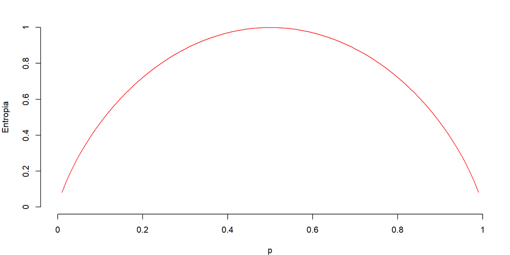

**Fonte:** Elaborado pelo autor (2026).

Contudo, a entropia não é a única medida de quantificação da impureza disponível. Para um problema de duas classes, em que $p_1 \equiv p$ e $p_2 = 1 - p$, pode-se definir, por exemplo, a função $\phi(p, 1 - p)$ que é uma função não-negativa que mede a impureza se satisfizer as seguintes propriedades:

- $\phi\left(1/2, 1/2\right) \geqslant \phi(p, 1 - p)$, para qualquer $p \in [0, 1]$; e $\phi(0, 1) = \phi(1, 0) = 0$.
- $\phi(p, 1 - p)$ é crescente para $p \in [0, 1/2]$ e decrescente para $p \in [1/2, 1]$.

Alguns exemplos do uso de $\phi(p, 1 - p)$ incluem:

- **Entropia**: $\phi(p, 1 - p) = -p \log_2 p - (1 - p) \log_2(1 - p)$.
- **Índice de Gini** (Breiman et al. 2017): $\phi(p, 1 - p) = 2p(1 - p)$
- **Erro de Classificação**: $\phi(p, 1 - p) = 1 - \max(p, 1 - p)$.

Por outro lado, se o nódulo $m$ não é puro, as instâncias precisam ser divididas para reduzir a impureza, e há diversos atributos nos quais essa divisão pode ser realizada. Para entender melhor esta ideia, consideremos que, no nódulo $m$, $N_{mj}$ de $N_m$ segue o ramo $j$; ou seja, esses são $x_t$ para os quais o teste $f_m(x_t)$ retorna o resultado definido por $j$. Para um *atributo discreto* com $n$ valores, existem $n$ resultados possíveis, enquanto para um *atributo numérico*, há apenas dois resultados possíveis ($n = 2$). Em ambos os casos, é válido que o número total de instâncias no nódulo seja preservado pela partição, e que, em cada ramo, a soma das instâncias por classe coincida com o total que alcança esse ramo, isto é,
$$\begin{align}\\
\sum_{j=1}^{n} N_{mj} = N_m \quad \text{e} \quad \sum_{i=1}^K N_{mj}^i = N_{mj}, \forall j = 1, \ldots, n\\\\
\end{align}$$
Similarmente, tem-se que $\sum_{j=1}^{n} N_{mj}^i = N_{m}^i$. Logo, dado que no nódulo $m$ o teste retorna o resultado $j$, a estimativa para a *probabilidade da classe* $C_i$ é dada por:
$$\begin{align}\\
\hat{P}(C_i \mid x, m, j) \equiv p_{mj}^i = \frac{N_{mj}^i}{N_{mj}}\\\\
\end{align}$$
Neste caso, a *impureza total* após a divisão é definida por:
$$\begin{align}\\
\mathcal{H}_{m,split} = -\sum_{j=1}^{n} \frac{N_{mj}}{N_m} \sum_{i=1}^{K} p_{mj}^i \log_2 p_{mj}^i\\\\
\end{align}$$

A partir da definição da impureza antes e após a divisão, é possível quantificar o *benefício* associado à partição de um nódulo por meio de uma medida denominada *ganho de informação*. Intuitivamente, o ganho de informação expressa a redução da incerteza sobre a classe das instâncias decorrente da aplicação de um determinado teste de divisão. Formalmente, o *ganho de informação* associado à divisão do nódulo $m$ segundo o teste $f_m(\cdot)$ é definido como a diferença entre a impureza do nódulo antes da divisão e a impureza total após a divisão, isto é,
$$\begin{align}\\
\text{Gain}(m) = \mathcal{H}_m - \mathcal{H}_{m,\text{split}}\\\\
\end{align}$$
Substituindo a expressão da impureza após a divisão, tem-se:
$$\begin{align}\\
\text{Gain}(m) = \mathcal{H}_m - \sum_{j=1}^{n} \frac{N_{mj}}{N_m} \sum_{i=1}^{K} p_{mj}^i \log_2 p_{mj}^i\\\\
\end{align}$$
O ganho de informação assume valores não negativos, sendo igual a zero quando a divisão não reduz a incerteza em relação à variável resposta. Quanto maior o valor do ganho, mais eficaz é a divisão no sentido de produzir subnódulos mais homogêneos em termos de classe. No processo de indução da árvore, o atributo e o critério de divisão selecionados em cada nódulo correspondem àqueles que maximizam o ganho de informação entre todas as divisões candidatas. Esse princípio orienta algoritmos clássicos de árvores de decisão, como ID3 e C4.5, estabelecendo uma estratégia local de otimização voltada à redução progressiva da impureza ao longo da estrutura da árvore.

**(III) Critérios de Poda**

O crescimento recursivo de uma árvore de decisão, guiado exclusivamente pela minimização da impureza em cada nódulo, pode resultar em estruturas excessivamente complexas, ajustadas de forma muito próxima aos dados de treinamento. Esse fenômeno caracteriza o *sobreajuste*, no qual o modelo apresenta baixo desempenho quando aplicado a novos dados. Para mitigar esse problema e controlar a complexidade estrutural da árvore, empregam-se os chamados *critérios de poda*. De forma geral, a poda consiste em restringir ou reduzir a estrutura da árvore, eliminando divisões que não contribuem de forma significativa para a capacidade preditiva do modelo. Os métodos de poda podem ser classificados em duas categorias principais: *poda prévia* (*pre-pruning*) e *poda posterior* (*post-pruning*).

- **(a) Poda Prévia (*Pre-pruning*)**: A *poda prévia* interrompe o crescimento da árvore antes que ela atinja seu tamanho máximo. Nesse caso, a decisão de não realizar uma divisão adicional em um nódulo é tomada durante o processo de indução, com base em critérios definidos a priori. Exemplos comuns incluem (i) limite máximo de profundidade da árvore; (ii) número mínimo de instâncias em um nódulo; e (iii) redução mínima de impureza exigida para efetuar uma divisão. Formalmente, seja $\Delta \mathcal{H}_m$ a redução de impureza obtida ao dividir o nódulo $m$. A divisão é realizada apenas se:
  $$\begin{align}\\
  \Delta \mathcal{H}_m \geqslant \varepsilon\\\\
  \end{align}$$
  em que $\varepsilon > 0$ é um limiar previamente estabelecido. Caso essa condição não seja satisfeita, o nódulo $m$ é convertido diretamente em um nódulo folha. Embora simples do ponto de vista computacional, a poda prévia pode interromper prematuramente o crescimento da árvore, impedindo a descoberta de estruturas relevantes em níveis mais profundos.
- **(b) Poda Posterior (*Post-pruning*)**: Na *poda posterior*, a árvore é inicialmente construída até sua forma máxima, obedecendo apenas aos critérios de divisão baseados na impureza. Em seguida, subárvores são avaliadas e, se necessário, removidas de forma retroativa. Para esclarecer esta ideia, considere um nódulo interno $t$ e a subárvore $T_t$ enraizada nesse nódulo. A poda consiste em substituir $T_t$ por um único nódulo folha, atribuindo-lhe uma predição baseada nas instâncias que alcançam $t$. Essa substituição é realizada se a eliminação da subárvore não resultar em pior desempenho do modelo segundo um critério de validação. Um exemplo clássico desse tipo de abordagem é a *poda por custo–complexidade*, utilizada no algoritmo CART. Nesse caso, define-se a função de custo:
  $$\begin{align}\\
  R_\alpha(T) = R(T) + \alpha \lvert T \rvert\\\\
  \end{align}$$
  em que $R(T)$ representa o erro empírico da árvore $T$, $\lvert T \rvert$ é o número de nódulos terminais da árvore e $\alpha \geqslant 0$ é um parâmetro que penaliza a complexidade estrutural do modelo. À medida que $\alpha$ aumenta, árvores menores passam a ser favorecidas, produzindo uma sequência aninhada de árvores podadas. Por fim, o objetivo é encontrar a árvore $T^\ast$ que minimiza $R_\alpha(T)$.

Tanto a poda prévia quanto a poda posterior buscam estabelecer um compromisso entre *ajuste aos dados* e *capacidade de generalização*. Enquanto a poda prévia atua de forma preventiva, a poda posterior permite maior flexibilidade ao avaliar explicitamente o impacto da complexidade do modelo após sua construção completa (Mitchell 1983; Alpaydin 2021; Greenwell 2022). Esses critérios de controle estrutural são fundamentais para garantir que árvores de decisão mantenham interpretabilidade e desempenho preditivo, além de estabelecerem a base para a apresentação dos algoritmos clássicos de indução de árvores, discutidos a seguir.

**(IV) Algoritmos de Árvores de Decisão**

- **ID3 (*Iterative Dichotomiser 3*)**: É um dos algoritmos fundadores para indução de árvores de decisão, proposto por J. R. Quinlan (1986), no qual a árvore é construída de forma recursiva por meio da seleção, em cada nó, do atributo que maximiza o *ganho de informação*, critério diretamente associado à redução da incerteza medida pela entropia. O algoritmo é destinado exclusivamente a *problemas de classificação*, operando apenas com atributos categóricos e sem mecanismos internos de poda, característica que o torna suscetível ao sobreajuste em conjuntos ruidosos ou de alta dimensionalidade. Nesse contexto, a entropia $H(S)$ de um conjunto de dados $S$, composto por $c$ classes, é definida por:
  $$\begin{align}\\
  H(S) = - \sum_{i=1}^{c} p_i \log_2 p_i\\\\
  \end{align}$$
  em que $p_i$ representa a proporção de instâncias pertencentes à classe $i$ no conjunto $S$, assumindo valor mínimo igual a zero quando o conjunto é puro e valor máximo quando as classes estão uniformemente distribuídas. A partir dessa medida de incerteza, considere um atributo categórico $A$, com valores possíveis $\{v_1, \ldots, v_k\}$, cuja partição divide $S$ em subconjuntos $S_{v_j}$. O *ganho de informação* associado a $A$ é então definido como:
  $$\begin{align}\\
  IG(S, A) = H(S) - \sum_{j=1}^{k} \frac{|S_{v_j}|}{|S|} H(S_{v_j})\\\\
  \end{align}$$
  sendo o atributo selecionado para o nó corrente aquele que maximiza $IG(S, A)$. Esse procedimento é repetido recursivamente até que uma das seguintes condições seja satisfeita: (i) todas as instâncias pertençam à mesma classe, (ii) não existam mais atributos disponíveis para particionamento ou (iii) o conjunto de instâncias seja vazio, situação em que se adota uma regra de decisão baseada na classe majoritária. Apesar de sua importância histórica e conceitual, o ID3 apresenta limitações relevantes, pois não trata atributos contínuos de forma nativa, não lida explicitamente com valores ausentes e não incorpora estratégias de regularização estrutural, fatores que comprometem sua capacidade de generalização.
- **C4.5**: Proposto por J. R. Quinlan (1993) como uma extensão direta do ID3, foi desenvolvido com o objetivo de superar limitações estruturais do algoritmo original, mantendo o mesmo princípio indutivo baseado na redução da incerteza, porém incorporando suporte a atributos contínuos, tratamento de valores ausentes e um mecanismo de poda. Assim como o ID3, o C4.5 é aplicado a *problemas de classificação* e constrói a árvore de forma recursiva, mas substitui o critério de ganho de informação simples pela *razão de ganho*, de modo a reduzir o viés em favor de atributos com grande número de valores distintos. Nesse contexto, recordando o ganho de informação $IG(S,A)$, a *razão de ganho* associada a um atributo $A$ é definida como:
  $$\begin{align}\\
  GR(S, A) = \frac{IG(S, A)}{H_A(S)} \\\\
  \end{align}$$
  em que $H_A(S)$ representa a entropia do atributo $A$, expressa por:
  $$\begin{align}\\
  H_A(S) = - \sum_{j=1}^{k} \frac{|S_{v_j}|}{|S|}
  \log_2 \left(\frac{|S_{v_j}|}{|S|} \right) \\\\
  \end{align}$$
  sendo ${v_1, \ldots, v_k}$ os valores possíveis de $A$ e $S_{v_j}$ os subconjuntos induzidos pela partição. O atributo selecionado em cada nó é aquele que maximiza $GR(S,A)$, desde que o ganho de informação associado seja positivo. Para atributos contínuos, o C4.5 avalia partições binárias da forma $A \leqslant \theta$ e $A > \theta$, considerando diferentes valores de corte $\theta$ obtidos a partir dos valores ordenados do atributo, e seleciona aquele que maximiza a razão de ganho. O algoritmo também lida com valores ausentes por meio de ponderação probabilística das instâncias ao longo dos ramos da árvore. Após a construção completa, o C4.5 aplica um procedimento de *poda pós-construção* baseado em estimativas de erro, removendo subárvores cuja complexidade não seja justificada pelo ganho preditivo, o que resulta em modelos mais compactos e com melhor capacidade de generalização em comparação ao ID3.
- **CART (*Classification and Regression Trees*)**: Proposto por Breiman et al. (1984), introduz uma formulação unificada para *problemas de classificação e regressão*, distinguindo-se dos algoritmos baseados em ganho de informação por empregar exclusivamente *divisões binárias* em todos os nós da árvore, característica que simplifica a estrutura do modelo e facilita extensões baseadas em comitês. No contexto da classificação, o CART utiliza como medida de impureza o *índice de Gini*, que quantifica a probabilidade de erro de rotulagem de uma instância escolhida aleatoriamente no conjunto $S$, sendo definido por:
  $$\begin{align}\\
  G(S) = 1 - \sum_{i=1}^{c} p_i^2 \\\\
  \end{align}$$
  em que $c$ representa o número de classes e $p_i$ a proporção de observações da classe $i$ em $S$. Para um candidato a divisão que particiona $S$ em dois subconjuntos $S_L$ e $S_R$, a qualidade da partição é avaliada pela impureza ponderada dos nós filhos, sendo selecionada a divisão que minimiza essa quantidade. O processo de construção da árvore prossegue de forma recursiva até que critérios de parada sejam atendidos, como profundidade máxima ou número mínimo de observações por nó. Diferentemente do ID3 e do C4.5, o CART incorpora explicitamente um procedimento de *poda por custo-complexidade*, no qual se busca minimizar uma função objetivo que equilibra o erro de ajuste e a complexidade da árvore, expressa por:
  $$\begin{align}\\
  R_\alpha(T) = R(T) + \alpha |T|\\\\
  \end{align}$$
  em que $R(T)$ representa o erro empírico da árvore $T$, $|T|$ o número de folhas e $\alpha$ um parâmetro de regularização. Esse mecanismo confere ao CART maior controle sobre o sobreajuste e estabelece uma base formal para o desenvolvimento de *métodos de ensemble* baseados em árvores de decisão.
- **Floresta Aleatória**: Proposto por Breiman (2001), é um método de *ensemble* baseado na combinação de múltiplas árvores de decisão, construídas de forma independente a partir da introdução controlada de aleatoriedade tanto nos dados quanto no processo de escolha das variáveis de divisão. O algoritmo fundamenta-se no princípio do *bootstrap aggregation* (*bagging*), segundo o qual cada árvore é ajustada sobre uma amostra *bootstrap* do conjunto de treinamento original, preservando o viés dos classificadores individuais, mas reduzindo a variância do classificador agregado. No entanto, diferentemente do *bagging* clássico, as florestas aleatórias incorporam uma segunda fonte essencial de aleatoriedade ao selecionar, em cada nó da árvore, apenas um subconjunto aleatório de $m < p$ variáveis candidatas à divisão, sendo $p$ o número total de preditores. Esse mecanismo tem como objetivo explícito reduzir a correlação entre as árvores individuais, evitando que variáveis altamente preditivas dominem sistematicamente as divisões iniciais e conduzam a estruturas semelhantes em todo o conjunto de árvores. Seja $\{\hat{C}_b(x)\}_{b=1}^{B}$ o conjunto de classificadores induzidos, em que cada árvore fornece uma predição de classe para a observação $x$, a predição final da floresta aleatória, no contexto de *classificação*, é obtida por meio de voto majoritário entre as árvores, sendo formalmente definida por:
  $$\begin{align}\\
  \hat{C}_{\text{rf}}(x) = \arg \max_k \sum_{b=1}^{B} \mathbb{I}\{\hat{C}_b(x) = k\}\\\\
  \end{align}$$
  em que $B$ representa o número total de árvores no *ensemble*, $k$ indexa as classes possíveis e $\mathbb{I}(\cdot)$ denota a função indicadora. Esse esquema de agregação pode ser interpretado probabilisticamente, uma vez que a proporção de árvores que votam em cada classe fornece uma estimativa empírica da probabilidade condicional associada àquela classe. A amostragem *bootstrap* implica que, em média, aproximadamente um terço das observações não seja utilizado no treinamento de cada árvore, possibilitando a obtenção de estimativas internas do erro de generalização por meio das chamadas amostras *out-of-bag* (OOB), sem necessidade de procedimentos explícitos de validação cruzada. A utilização de árvores profundamente crescidas, geralmente sem poda, mantém baixo o viés dos classificadores base, enquanto a redução da correlação entre as árvores, promovida pela seleção aleatória de atributos em cada divisão, potencializa a redução da variância do classificador agregado. Como resultado, a floresta aleatória apresenta elevado desempenho preditivo, robustez a ruído e estabilidade em problemas de classificação, além de permitir a obtenção de medidas de importância das variáveis baseadas na redução média de impureza ou no impacto das predições sobre o erro OOB, o que contribui para sua interpretabilidade mesmo em cenários de alta dimensionalidade.
- **Gradient Boosting**: Proposto originalmente por J. H. Friedman (2001), é um método de *ensemble* baseado na construção *sequencial e aditiva* de classificadores fracos, cujo objetivo é reduzir o erro de classificação por meio da correção iterativa dos erros cometidos pelos modelos anteriores. Diferentemente de métodos baseados em *bagging*, como a floresta aleatória, nos quais os classificadores são treinados de forma independente, o *boosting* estabelece uma dependência entre os modelos, fazendo com que cada nova árvore seja ajustada para capturar padrões ainda não explicados pelo *ensemble* corrente. No contexto de *classificação*, essa estratégia pode ser interpretada como um procedimento de minimização iterativa de uma função de perda diferenciável $L(y, f(x))$, na qual o classificador final é construído como uma soma aditiva de funções base, tipicamente árvores de decisão rasas. Formalmente, após $M$ iterações, o modelo resultante pode ser expresso como:
  $$\begin{align}\\
  f_M(x) = \sum_{m=1}^{M} \gamma_m h_m(x)\\\\
  \end{align}$$
  em que $h_m(x)$ representa o classificador ajustado na iteração $m$ e $\gamma_m$ o peso associado à sua contribuição no *ensemble*. Em cada etapa, a nova árvore é treinada para aproximar os resíduos negativos do gradiente da função de perda em relação às predições atuais do modelo, calculados como:
  $$\begin{align}\\
  r_i^{(m)} = - \left. \frac{\partial L(y_i, f(x_i))}{\partial f(x_i)} \right|_{f = f_{m-1}}\\\\
  \end{align}$$
  sendo $(x_i, y_i)$ as observações do conjunto de treinamento. Esse mecanismo direciona o aprendizado para as observações classificadas incorretamente ou com baixa margem de decisão, tornando o *gradient boosting* particularmente eficaz na redução do viés do classificador final. Ao mesmo tempo, a utilização de árvores rasas, aliada ao controle da taxa de aprendizado, atua como um mecanismo de regularização implícita, mitigando o risco de sobreajuste decorrente da construção sequencial. Como resultado, o *gradient boosting* produz classificadores altamente expressivos, capazes de modelar fronteiras de decisão complexas, embora com maior sensibilidade a hiperparâmetros e a ruído quando comparado a métodos baseados em *bagging*, característica que motiva o desenvolvimento de variantes regularizadas, como o *XGBoost*.
- **XGBoost (*Extreme Gradient Boosting*)**: Proposto por Chen e Guestrin (2016), constitui uma extensão estatística e computacional do *gradient boosting* clássico, desenvolvida com o objetivo de aprimorar simultaneamente a capacidade de generalização, a estabilidade numérica e a eficiência computacional do processo de aprendizado. Assim como no *boosting* tradicional, o classificador é construído de forma sequencial e aditiva, porém o XGBoost introduz uma função objetivo regularizada, permitindo controlar diretamente a complexidade das árvores induzidas e reduzir o risco de sobreajuste, especialmente em problemas de classificação de alta dimensão. A função objetivo global do modelo pode ser expressa como:
  $$\begin{align}\\
  \mathcal{L} = \sum_{i=1}^{n} L(y_i, \hat{y}_i) + \sum_{m=1}^{M} \Omega(h_m)\\\\
  \end{align}$$
  em que $L(y_i, \hat{y}_i)$ representa uma função de perda diferenciável apropriada para *classificação* e $\Omega(h_m)$ corresponde ao termo de regularização estrutural associado à árvore $h_m$. Esse termo é definido como:
  $$\begin{align}\\
  \Omega(h) = \gamma T + \frac{1}{2}\lambda \sum_{j=1}^{T} w_j^2\\\\
  \end{align}$$
  em que $T$ denota o número de folhas da árvore, $w_j$ os pesos atribuídos às folhas, $\gamma$ um parâmetro que penaliza a criação de novas folhas e $\lambda$ um coeficiente de regularização que controla a magnitude dos pesos. Diferentemente do *gradient boosting* tradicional, o XGBoost utiliza uma aproximação de segunda ordem da função de perda por meio da expansão de Taylor, incorporando tanto os gradientes quanto as Hessianas no processo de otimização, o que permite decisões de divisão mais informadas e uma estimativa mais precisa do ganho associado a cada possível partição. Esse procedimento torna o crescimento das árvores mais eficiente e estável, especialmente em situações nas quais a superfície de perda apresenta forte curvatura. Além disso, o algoritmo emprega estratégias computacionais avançadas, como paralelização do processo de construção das árvores, tratamento nativo de valores ausentes e poda orientada por ganho mínimo, garantindo que apenas divisões que contribuam efetivamente para a redução da função objetivo sejam mantidas. Em conjunto, esses mecanismos conferem ao XGBoost elevada capacidade preditiva em tarefas de classificação, aliando a expressividade dos métodos de *boosting* a um controle rigoroso da complexidade do modelo, o que explica sua ampla adoção em aplicações práticas e competições de aprendizado de máquina.

**(V) Implementação Computacional**

Conforme discutido anteriormente, os modelos baseados em árvores de decisão estruturam a regra de classificação a partir de partições recursivas do espaço amostral, obtidas por sucessivas escolhas de divisões (*splits*) que maximizam o ganho de pureza dos nós, segundo uma função-critério (por exemplo, índice de Gini ou entropia). Embora bibliotecas especializadas disponibilizem rotinas prontas para ajuste e validação desses modelos, tais implementações frequentemente encapsulam decisões centrais do procedimento — como a busca do melhor ponto de corte para variáveis contínuas, o tratamento de variáveis categóricas, os critérios de parada e o papel de mecanismos de regularização (poda ou limitação de profundidade) — o que pode reduzir a transparência analítica do método e dificultar a compreensão de como a árvore induzida resulta diretamente do critério de impureza e das restrições de complexidade adotadas. Diante disso, em contextos em que se busca maior clareza conceitual e controle metodológico, torna-se desejável explicitar computacionalmente ao menos o algoritmo-base de indução da árvore.

Sob essa perspectiva, o Código 4.6 apresenta o pseudocódigo do algoritmo CART (para classificação), escolhido por sua ampla adoção e por consolidar, em um único fluxo, as etapas fundamentais do aprendizado de árvores: seleção do *split* ótimo, construção recursiva, definição de condições de parada e controle de complexidade. Uma vez estabelecido esse núcleo, torna-se natural estender o raciocínio para métodos de comitê que utilizam árvores como estimadores base, nos quais a melhoria de desempenho decorre de estratégias de agregação. Nesse sentido, o Código 4.7 descreve o procedimento da floresta aleatória, enfatizando o uso de amostras *bootstrap* e a seleção aleatória de subconjuntos de atributos em cada nó como mecanismos de decorrelação entre árvores e redução de variância. Por fim, o Código 4.8 apresenta o esqueleto computacional de *gradient boosting* com árvores rasas, no qual modelos são ajustados de forma sequencial para corrigir erros residuais do conjunto corrente, incorporando taxa de aprendizado e número de iterações como parâmetros de regularização; ainda que existam diferentes variantes de *boosting*, o fluxo geral permanece análogo, diferindo principalmente na forma de definição do alvo auxiliar (resíduos ou pseudo-resíduos) e na função de perda considerada.

**Código 4.6.** Pseudocódigo do algoritmo CART para tarefas de classificação.

**Input**

$\quad$ **1:** $\mathcal{D}_{\mathrm{train}}=\{(\mathbf{x}_j,y_j)\}_{j=1}^{n_{\mathrm{train}}}$, com $\mathbf{x}_j\in\mathbb{R}^{p}$ e $y_j\in\{1,\ldots,C\}$;  
$\quad$ **2:** $\mathcal{D}_{\mathrm{test}}=\{\tilde{\mathbf{x}}_i\}_{i=1}^{n_{\mathrm{test}}}$, com $\tilde{\mathbf{x}}_i\in\mathbb{R}^{p}$;  
$\quad$ **3:** $\mathcal{I}(\cdot)$ (critério de impureza);  
$\quad$ **4:** $d_{\max}$ (profundidade máxima);  
$\quad$ **5:** $n_{\min}$ (número mínimo de observações por nó);  
$\quad$ **6:** $C$ (número de classes).

**Execution**

$\quad$ **7:** Inicialize a raiz da árvore com $\mathcal{D}_{\mathrm{train}}$ e associe o conjunto de índices $\mathcal{J}_0=\{1,\ldots,n_{\mathrm{train}}\}$  
$\quad$ **8:** **procedure** ${GrowTree}(\mathcal{J},d)$  
$\quad$ **9:** $\quad$ **if** $d \geqslant d_{\max}$ **ou** $|\mathcal{J}| < n_{\min}$ **ou** $|\{y_j:j\in\mathcal{J}\}|=1$ **then**  
$\quad$ **10:** $\quad\quad$ Defina o nó como folha e atribua o rótulo predito $\hat{y} \gets \arg\max\limits_{c\in\{1,\ldots,C\}} \sum\limits_{j\in\mathcal{J}} \mathbb{I}(y_j=c)$  
$\quad$ **11:** $\quad\quad$ **return**  
$\quad$ **12:** $\quad$ **end if**

$\quad$ **13:** $\quad$ Inicialize $\Delta_{\min}\gets +\infty$ e defina $\mathrm{found}\gets \mathrm{FALSE}$  
$\quad$ **14:** $\quad$ **for** $k=1,\ldots,p$ **do**  
$\quad$ **15:** $\quad\quad$ Seja $\mathcal{U}_k$ o conjunto ordenado de valores distintos de $\{x_{jk}:j\in\mathcal{J}\}$  
$\quad$ **16:** $\quad\quad$ **if** $|\mathcal{U}_k|\leqslant 1$ **then**  
$\quad$ **17:** $\quad\quad\quad$ **continue**  
$\quad$ **18:** $\quad\quad$ **end if**  
$\quad$ **19:** $\quad\quad$ Defina $\mathcal{S}_k\gets\left\{\dfrac{u_{m}+u_{m+1}}{2}: u_m,u_{m+1}\in\mathcal{U}_k \text{ consecutivos},\ m=1,\ldots,|\mathcal{U}_k|-1\right\}$  
$\quad$ **20:** $\quad\quad$ **for all** $s\in\mathcal{S}_k$ **do**  
$\quad$ **21:** $\quad\quad\quad$ Defina $\mathcal{J}_L\gets\{j\in\mathcal{J}:x_{jk}\leqslant s\}$ e $\mathcal{J}_R\gets\{j\in\mathcal{J}:x_{jk}> s\}$  
$\quad$ **22:** $\quad\quad\quad$ **if** $|\mathcal{J}_L|<n_{\min}$ **ou** $|\mathcal{J}_R|<n_{\min}$ **then**  
$\quad$ **23:** $\quad\quad\quad\quad$ **continue**  
$\quad$ **24:** $\quad\quad\quad$ **end if**  
$\quad$ **25:** $\quad\quad\quad$ Calcule $\Delta \gets \mathcal{I}(\mathcal{J}_L)+\mathcal{I}(\mathcal{J}_R)$  
$\quad$ **26:** $\quad\quad\quad$ **if** $\Delta<\Delta_{\min}$ **then**  
$\quad$ **27:** $\quad\quad\quad\quad$ Atualize $\Delta_{\min}\gets\Delta$ e armazene a divisão ótima $(k^{\ast},s^{\ast})$  
$\quad$ **28:** $\quad\quad\quad\quad$ Defina $\mathrm{found}\gets \mathrm{TRUE}$  
$\quad$ **29:** $\quad\quad\quad$ **end if**  
$\quad$ **30:** $\quad\quad$ **end for**  
$\quad$ **31:** $\quad$ **end for**

$\quad$ **32:** $\quad$ **if** $\mathrm{found}=\mathrm{FALSE}$ **then**  
$\quad$ **33:** $\quad\quad$ Defina o nó como folha e atribua o rótulo predito $\hat{y} \gets \arg\max\limits_{c\in\{1,\ldots,C\}} \sum\limits_{j\in\mathcal{J}} \mathbb{I}(y_j=c)$  
$\quad$ **34:** $\quad\quad$ **return**  
$\quad$ **35:** $\quad$ **end if**

$\quad$ **36:** $\quad$ Particione $\mathcal{J}$ em $\mathcal{J}_L$ e $\mathcal{J}_R$ usando $(k^{\ast},s^{\ast})$ e crie o nó interno com regra $x_{k^{\ast}}\leqslant s^{\ast}$  
$\quad$ **37:** $\quad$ **call** ${GrowTree}(\mathcal{J}_L,d+1)$; **call** ${GrowTree}(\mathcal{J}_R,d+1)$  
$\quad$ **38:** **end procedure**

$\quad$ **39:**  
$\quad$ **40:** Construa a árvore a partir da raiz: **call** ${GrowTree}(\mathcal{J}_0,0)$

$\quad$ **41:** Inicialize $\widehat{\mathbf{Y}}\in\{1,\ldots,C\}^{n_{\mathrm{test}}}$  
$\quad$ **42:** **for** $i=1,\ldots,n_{\mathrm{test}}$ **do**  
$\quad$ **43:** $\quad$ Percorra a árvore a partir da raiz seguindo as regras de divisão  
$\quad$ **44:** $\quad$ Atribua $\widehat{\mathbf{Y}}[i]$ ao rótulo da folha alcançada  
$\quad$ **45:** **end for**  
$\quad$ **46:** **return** $\widehat{\mathbf{Y}}$

**Output**

$\quad$ **47:** Vetor de predições $\widehat{\mathbf{Y}}\in\{1,\ldots,C\}^{n_{\mathrm{test}}}$

**Fonte:** Elaborado pelo autor (2026).

Atividade Prática 4.13

Com base no Código 4.6, implemente, em R, uma função para executar o algoritmo *CART* em problemas de *classificação supervisionada*. A implementação deve conter a definição explícita dos argumentos de *entrada* e de *saída*, os quais determinam (i) os objetos utilizados no particionamento recursivo do espaço amostral, (ii) o critério de impureza e os critérios de parada que controlam o crescimento da árvore, limitando sua complexidade estrutural, e (iii) a forma como a árvore ajustada e os resultados da etapa de classificação são organizados e retornados ao usuário. Nesse contexto, os *argumentos de entrada* da função devem incluir:

- `formula`: fórmula que especifica a relação entre variável resposta e as variáveis explicativas, na forma `y ~ x1 + x2 + ... + xp`, determinando quais variáveis serão utilizadas na indução da árvore e na etapa de predição.
- `data`: quadro de dados (`data.frame`) contendo as observações e as variáveis definidas em `formula`.
- `criterion`: critério de impureza adotado para avaliar divisões, podendo assumir, por exemplo, os valores `"gini"` ou `"entropy"`.
- `max_depth`: inteiro opcional que especifica a profundidade máxima permitida para a árvore; quando `max_depth = NULL`, o crescimento não é limitado por profundidade, ficando restrito aos demais critérios de parada.
- `min_split`: inteiro opcional que define o número mínimo de observações em um nó para que uma nova divisão seja considerada; quando `min_split = NULL`, esse critério não é aplicado.
- `split_ratio`: proporção de observações destinada ao conjunto de treinamento; por exemplo, `split_ratio = 0.7` indica que 70% das observações compõem o treinamento e 30% o teste.
- `show_tree_plot`: valor lógico que indica se a representação gráfica da árvore induzida deve (`TRUE`) ou não (`FALSE`) ser exibida.

Para o teste da implementação, utilize o conjunto de dados `SAheart`, disponibilizado no pacote `ElemStatLearn`. Para este conjunto, considere como variável resposta a presença de doença cardíaca coronariana, representada por `chd` (com classes $0$ e $1$), e como variáveis explicativas os fatores de risco `sbp` (pressão arterial sistólica), `tobacco` (consumo cumulativo de tabaco), `ldl` (colesterol LDL), `adiposity` (adiposidade), `famhist` (histórico familiar de doença coronariana), `typea` (escore de comportamento tipo A), `obesity` (obesidade), `alcohol` (consumo de álcool) e `age` (idade). Neste problema, ajuste uma árvore de classificação CART com o objetivo de avaliar seu desempenho na atribuição do rótulo `chd` a partir das variáveis explicativas, utilizando uma amostra previamente rotulada. Para esse fim, particione a base segundo o *método hold-out*, destinando $70\%$ das observações ao treinamento e $30\%$ ao conjunto de teste. Além disso, avalie sistematicamente o comportamento do algoritmo sob diferentes cenários de modelagem, variando:

- o critério de impureza `criterion` (por exemplo, `criterion` $\in \{\text{``gini''}, \text{``entropy''}\}$);
- a profundidade máxima `max_depth` (por exemplo, `max_depth` $\in \{2,3,4,5\}$);
- o tamanho mínimo para divisão `min_split` (por exemplo, `min_split` $\in \{5,10,20\}$).

Por fim, obtenha as predições no conjunto de teste para cada cenário considerado e avalie o desempenho preditivo do classificador com base nas medidas de avaliação para classificação discutidas na Seção 4.4.

**Código 4.7.** Pseudocódigo do algoritmo floresta aleatória para tarefas de classificação.

**Input**

$\quad$ **1:** $\mathcal{D}_{\mathrm{train}}=\{(\mathbf{x}_j,y_j)\}_{j=1}^{n_{\mathrm{train}}}$, com $\mathbf{x}_j\in\mathbb{R}^{p}$ e $y_j\in\{1,\ldots,C\}$; $\mathcal{D}_{\mathrm{test}}=\{\tilde{\mathbf{x}}_i\}_{i=1}^{n_{\mathrm{test}}}$, com $\tilde{\mathbf{x}}_i\in\mathbb{R}^{p}$  
$\quad$ **2:** $\mathcal{I}(\cdot)$ (critério de impureza);  
$\quad$ **3:** $d_{\max}$ (profundidade máxima);  
$\quad$ **4:** $n_{\min}$ (mínimo de observações por nó)  
$\quad$ **5:** $B$ (número de árvores);  
$\quad$ **6:** $n_{\mathrm{boot}}$ (tamanho da amostra bootstrap);  
$\quad$ **7:** $m_{\mathrm{try}}$ (número de variáveis candidatas por divisão)  
$\quad$ **8:** $\mathcal{R}$ (regra de desempate)  
$\quad$ **9:** $L:\{1,\ldots,C\}\times\{1,\ldots,C\}\to\mathbb{R}_{+}$ (função de perda para o conjunto OOB)  
$\quad$ **10:** $C$ (número de classes)

**Execution**

$\quad$ **11:** Inicialize a floresta $\mathcal{F}=\{\mathcal{T}_b\}_{b=1}^{B}$  
$\quad$ **12:** Inicialize conjuntos OOB: $\mathcal{O}_1,\ldots,\mathcal{O}_B\gets\emptyset$  
$\quad$ **13:**

$\quad$ **14:** **procedure** ${GrowTree}(\mathcal{J},d,\mathcal{D})$  
$\quad$ **15:** $\quad$ **if** $d \geqslant d_{\max}$ **ou** $|\mathcal{J}| < n_{\min}$ **ou** $|\{y_j:j\in\mathcal{J}\}|=1$ **then**  
$\quad$ **16:** $\quad\quad$ Defina o nó como folha e atribua $\hat{y}\gets \arg\max\limits_{c\in\{1,\ldots,C\}} \sum\limits_{j\in\mathcal{J}}\mathbb{I}(y_j=c)$ (em $\mathcal{D}$)  
$\quad$ **17:** $\quad\quad$ **return**  
$\quad$ **18:** $\quad$ **end if**

$\quad$ **19:** $\quad$ Amostre sem reposição $\mathcal{K}\subset\{1,\ldots,p\}$ com $|\mathcal{K}|=m_{\mathrm{try}}$  
$\quad$ **20:** $\quad$ Inicialize $\Delta_{\min}\gets +\infty$, $\mathrm{found}\gets \mathrm{FALSE}$ e conjunto de ótimos $\mathcal{C}\gets\emptyset$

$\quad$ **21:** $\quad$ **for all** $k\in\mathcal{K}$ **do**  
$\quad$ **22:** $\quad\quad$ $\mathcal{U}_k\gets$ valores distintos ordenados de $\{x_{jk}:j\in\mathcal{J}\}$ (em $\mathcal{D}$)  
$\quad$ **23:** $\quad\quad$ **if** $|\mathcal{U}_k| \leqslant 1$ **then**  
$\quad$ **24:** $\quad\quad\quad$ **continue**  
$\quad$ **25:** $\quad\quad$ **end if**  
$\quad$ **26:** $\quad\quad$ $\mathcal{S}_k \gets \left\{\dfrac{u_{m}+u_{m+1}}{2}: u_m,u_{m+1}\in\mathcal{U}_k \text{ consecutivos},\ m=1,\ldots,|\mathcal{U}_k|-1\right\}$

$\quad$ **27:** $\quad\quad$ **for all** $s\in\mathcal{S}_k$ **do**  
$\quad$ **28:** $\quad\quad\quad$ $\mathcal{J}_L\gets\{j\in\mathcal{J}:x_{jk}\leqslant s\}$, $\mathcal{J}_R\gets\{j\in\mathcal{J}:x_{jk}> s\}$ (em $\mathcal{D}$)  
$\quad$ **29:** $\quad\quad\quad$ **if** $|\mathcal{J}_L|<n_{\min}$ **ou** $|\mathcal{J}_R|<n_{\min}$ **then**  
$\quad$ **30:** $\quad\quad\quad\quad$ **continue**  
$\quad$ **31:** $\quad\quad\quad$ **end if**  
$\quad$ **32:** $\quad\quad\quad$ $\Delta \gets \mathcal{I}(\mathcal{J}_L;\mathcal{D})+\mathcal{I}(\mathcal{J}_R;\mathcal{D})$  
$\quad$ **33:** $\quad\quad\quad$ **if** $\Delta<\Delta_{\min}$ **then**  
$\quad$ **34:** $\quad\quad\quad\quad$ $\Delta_{\min}\gets\Delta$, $\mathcal{C}\gets\{(k,s)\}$, $\mathrm{found}\gets\mathrm{TRUE}$  
$\quad$ **35:** $\quad\quad\quad$ **else if** $\Delta=\Delta_{\min}$ **then**  
$\quad$ **36:** $\quad\quad\quad\quad$ $\mathcal{C}\gets \mathcal{C}\cup\{(k,s)\}$  
$\quad$ **37:** $\quad\quad\quad$ **end if**  
$\quad$ **38:** $\quad\quad$ **end for**  
$\quad$ **39:** $\quad$ **end for**

$\quad$ **40:** $\quad$ **if** $\mathrm{found}=\mathrm{FALSE}$ **then**  
$\quad$ **41:** $\quad\quad$ Defina o nó como folha e atribua $\hat{y}\gets \arg\max\limits_{c\in\{1,\ldots,C\}} \sum\limits_{j\in\mathcal{J}}\mathbb{I}(y_j=c)$ (em $\mathcal{D}$)  
$\quad$ **42:** $\quad\quad$ **return**  
$\quad$ **43:** $\quad$ **end if**

$\quad$ **44:** $\quad$ Selecione $(k^\ast,s^\ast)\gets \mathcal{R}(\mathcal{C})$  
$\quad$ **45:** $\quad$ Defina $\mathcal{J}_L\gets\{j\in\mathcal{J}:x_{jk^\ast}\leqslant s^\ast\}$ e $\mathcal{J}_R\gets\{j\in\mathcal{J}:x_{jk^\ast}> s^\ast\}$ (em $\mathcal{D}$)  
$\quad$ **46:** $\quad$ Crie o nó interno com regra $x_{k^\ast}\leqslant s^\ast$ e associe os filhos aos subconjuntos $(\mathcal{J}_L,\mathcal{J}_R)$  
$\quad$ **47:** $\quad$ **call** ${GrowTree}(\mathcal{J}_L,d+1,\mathcal{D})$ e ${GrowTree}(\mathcal{J}_R,d+1,\mathcal{D})$  
$\quad$ **48:** **end procedure**

$\quad$ **49:**  
$\quad$ **50:** **procedure** ${PredictTree}(\mathcal{T},\tilde{\mathbf{x}})$  
$\quad$ **51:** $\quad$ Inicialize o nó atual como a raiz de $\mathcal{T}$  
$\quad$ **52:** $\quad$ **while** nó atual não é folha **do**  
$\quad$ **53:** $\quad\quad$ Leia a regra de divisão $(k,s)$ armazenada no nó atual  
$\quad$ **54:** $\quad\quad$ **if** $\tilde{x}_{k}\leqslant s$ **then**  
$\quad$ **55:** $\quad\quad\quad$ Atualize o nó atual para o subnó correspondente ao subconjunto esquerdo  
$\quad$ **56:** $\quad\quad$ **else**  
$\quad$ **57:** $\quad\quad\quad$ Atualize o nó atual para o subnó correspondente ao subconjunto direito  
$\quad$ **58:** $\quad\quad$ **end if**  
$\quad$ **59:** $\quad$ **end while**  
$\quad$ **60:** $\quad$ **return** rótulo predito $\hat{y}$ armazenado na folha  
$\quad$ **61:** **end procedure**

$\quad$ **62:**  
$\quad$ **63:** **procedure** ${PredictRF}(\mathcal{F},\tilde{\mathbf{x}})$  
$\quad$ **64:** $\quad$ Calcule $\hat{y}^{(b)}\gets {PredictTree}(\mathcal{T}_b,\tilde{\mathbf{x}})$ para todo $b=1,\ldots,B$  
$\quad$ **65:** $\quad$ **return** $\hat{y}_{\mathrm{RF}}(\tilde{\mathbf{x}})\gets \arg\max\limits_{c\in\{1,\ldots,C\}} \sum\limits_{b=1}^{B}\mathbb{I}(\hat{y}^{(b)}=c)$  
$\quad$ **66:** **end procedure**

$\quad$ **67:**  
$\quad$ **68:** **for** $b=1,\ldots,B$ **do**  
$\quad$ **69:** $\quad$ Amostre com reposição índices $j^{(b)}_1,\ldots,j^{(b)}_{n_{\mathrm{boot}}}$ de $\{1,\ldots,n_{\mathrm{train}}\}$  
$\quad$ **70:** $\quad$ Defina bootstrap $\mathcal{D}^{(b)}=\{(\mathbf{x}_{j^{(b)}_r},y_{j^{(b)}_r})\}_{r=1}^{n_{\mathrm{boot}}}$  
$\quad$ **71:** $\quad$ Defina OOB $\mathcal{O}_b \gets \{1,\ldots,n_{\mathrm{train}}\}\setminus\{j^{(b)}_1,\ldots,j^{(b)}_{n_{\mathrm{boot}}}\}$  
$\quad$ **72:** $\quad$ Defina $\mathcal{J}_0^{(b)}=\{1,\ldots,n_{\mathrm{boot}}\}$ (índices internos de $\mathcal{D}^{(b)}$)  
$\quad$ **73:** $\quad$ Construa a árvore $\mathcal{T}_b$ a partir da raiz (em $\mathcal{D}^{(b)}$): ${GrowTree}(\mathcal{J}_0^{(b)},0,\mathcal{D}^{(b)})$  
$\quad$ **74:** **end for**

$\quad$ **75:**  
$\quad$ **76:** Defina a floresta $\mathcal{F}\gets\{\mathcal{T}_b\}_{b=1}^{B}$  
$\quad$ **77:**

$\quad$ **78:** **Predição no conjunto de teste** $\mathcal{D}_{\mathrm{test}}$  
$\quad$ **79:** Inicialize $\widehat{\mathbf{Y}}\in\{1,\ldots,C\}^{n_{\mathrm{test}}}$  
$\quad$ **80:** **for** $i=1,\ldots,n_{\mathrm{test}}$ **do**  
$\quad$ **81:** $\quad$ $\widehat{\mathbf{Y}}[i]\gets {PredictRF}(\mathcal{F},\tilde{\mathbf{x}}_i)$  
$\quad$ **82:** **end for**  
$\quad$ **83:**

$\quad$ **84:** **Erro out-of-bag (OOB)**  
$\quad$ **85:** Inicialize acumuladores $S_{ic}\gets 0$ para $i=1,\ldots,n_{\mathrm{train}}$ e $c=1,\ldots,C$ e contagens $C_i\gets 0$ para $i=1,\ldots,n_{\mathrm{train}}$  
$\quad$ **86:** **for** $b=1,\ldots,B$ **do**  
$\quad$ **87:** $\quad$ **for all** $i\in\mathcal{O}_b$ **do**  
$\quad$ **88:** $\quad\quad$ Seja $\hat{y}^{(b)}_i\gets {PredictTree}(\mathcal{T}_b,\mathbf{x}_i)$  
$\quad$ **89:** $\quad\quad$ $S_{i\hat{y}^{(b)}_i}\gets S_{i\hat{y}^{(b)}_i}+1$  
$\quad$ **90:** $\quad\quad$ $C_i\gets C_i+1$  
$\quad$ **91:** $\quad$ **end for**  
$\quad$ **92:** **end for**  
$\quad$ **93:** Defina $\hat{y}^{\mathrm{OOB}}_i \gets \arg\max\limits_{c\in\{1,\ldots,C\}} S_{ic}$  
$\quad$ **94:** Calcule $\mathrm{Err}_{\mathrm{OOB}}\gets \frac{1}{|\{i:C_i>0\}|}\sum_{i:C_i>0}L(y_i,\hat{y}^{\mathrm{OOB}}_i)$

**Output**

$\quad$ **95:** Vetor de predições: $\widehat{\mathbf{Y}}\in\{1,\ldots,C\}^{n_{\mathrm{test}}}$;  
$\quad$ **96:** Erro OOB: $\mathrm{Err}_{\mathrm{OOB}}$

**Fonte:** Elaborado pelo autor (2026).

Atividade Prática 4.14

Com base no Código 4.7, implemente, em R, uma função para executar o algoritmo de floresta aleatória em problemas de *classificação supervisionada*. A implementação deve conter a definição explícita dos argumentos de *entrada* e de *saída*, os quais determinam (i) os objetos utilizados no processo de reamostragem *bootstrap* e no ajuste das árvores individuais, (ii) o número de árvores e o número de variáveis candidatas por nó, que controlam o mecanismo de aleatorização e a redução de variância do comitê, e (iii) a forma como o conjunto de árvores ajustadas e os resultados da etapa de classificação são organizados e retornados ao usuário. Nesse contexto, os *argumentos de entrada* da função devem incluir:

- `formula`: fórmula que especifica a relação entre variável resposta e preditores, na forma `y ~ x1 + x2 + ... + xp`, determinando quais variáveis serão utilizadas no ajuste das árvores e na etapa de predição.
- `data`: quadro de dados (`data.frame`) contendo as observações e as variáveis definidas em `formula`.
- `B`: inteiro que define o número de árvores que compõe a floresta.
- `mtry`: inteiro opcional que define o número de variáveis candidatas avaliadas em cada nó; quando `mtry = NULL`, pode-se adotar uma escolha padrão (por exemplo, $\lfloor \sqrt{p} \rfloor$ em classificação).
- `criterion`: critério de impureza adotado para avaliar divisões em cada árvore base, podendo assumir, por exemplo, os valores `"gini"` ou `"entropy"`.
- `max_depth`: inteiro opcional que especifica a profundidade máxima permitida para cada árvore; quando `max_depth = NULL`, o crescimento não é limitado por profundidade, ficando restrito aos demais critérios de parada.
- `min_split`: inteiro opcional que define o número mínimo de observações em um nó para que uma nova divisão seja considerada; quando `min_split = NULL`, esse critério não é aplicado.
- `split_ratio`: proporção de observações destinada ao conjunto de treinamento; por exemplo, `split_ratio = 0.7` indica que 70% das observações compõem o treinamento e 30% o teste.
- `show_oob`: valor lógico que indica se a estimativa *out-of-bag* (OOB) deve (`TRUE`) ou não (`FALSE`) ser exibida.

Para o teste da implementação, utilize o conjunto de dados `PimaIndiansDiabetes`, disponibilizado na biblioteca `mlbench`. Para estes dados, considere como variável resposta `diabetes`, com rótulos `pos` e `neg`, e como variáveis explicativas: número de gestações (`pregnant`), concentração de glicose (`glucose`), pressão diastólica (`pressure`), espessura da prega cutânea do tríceps (`triceps`), nível sérico de insulina (`insulin`), índice de massa corporal (`mass`), função pedigree para diabetes (`pedigree`) e idade (`age`). Neste problema, ajuste um comitê de árvores via random forest com o objetivo de avaliar seu desempenho na atribuição do rótulo `diabetes` a partir das variáveis explicativas, utilizando uma amostra previamente rotulada. Para esse fim, particione a base segundo o *método hold-out*, destinando $70\%$ das observações ao treinamento e $30\%$ ao conjunto de teste. Além disso, avalie sistematicamente o comportamento do algoritmo sob diferentes cenários de modelagem, variando:

- o número de árvores `B` (por exemplo, `B` $\in \{100, 300, 500, 1000\}$);
- o número de variáveis candidatas por nó `mtry` (por exemplo, `mtry` $\in \{2, \lfloor \sqrt{p} \rfloor, p\}$, com $p$ igual ao número de variáveis explicativas);
- o critério de impureza `criterion` (por exemplo, `criterion` $\in \{\text{``gini''}, \text{``entropy''}\}$);
- a profundidade máxima `max_depth` (por exemplo, `max_depth` $\in \{3,5,7\}$);
- o tamanho mínimo para divisão `min_split` (por exemplo, `min_split` $\in \{5,10,20\}$).

Por fim, obtenha as predições no conjunto de teste para cada cenário considerado e avalie o desempenho preditivo do classificador com base nas medidas de avaliação para classificação discutidas na Seção 4.4. Quando `show_oob = TRUE`, apresente e interprete também a estimativa OOB, discutindo seu papel como aproximação do erro de generalização e sua relação com o desempenho observado no conjunto de teste.

**Código 4.8.** Pseudocódigo do algoritmo *gradient boosting* com árvores rasas para tarefas de classificação.

**Input**

$\quad$ **1:** $\mathcal{D}_{\mathrm{train}}=\{(\mathbf{x}_i,y_i)\}_{i=1}^{n}$, com $\mathbf{x}_i\in\mathbb{R}^{p}$ e $y_i\in\{0,1\}$;  
$\quad$ **2:** $\mathcal{D}_{\mathrm{test}}=\{\tilde{\mathbf{x}}_i\}_{i=1}^{n_{\mathrm{test}}}$, com $\tilde{\mathbf{x}}_i\in\mathbb{R}^{p}$;  
$\quad$ **3:** $L:\{0,1\}\times(0,1)\to\mathbb{R}_{+}$ (função de perda diferenciável);  
$\quad$ **4:** $\Omega(\cdot)$ (termo de regularização aplicado à árvore $h$);  
$\quad$ **5:** $M$ (número de iterações);  
$\quad$ **6:** $\nu\in(0,1]$ (taxa de aprendizado);  
$\quad$ **7:** $\mathcal{H}$ (classe de árvores base);  
$\quad$ **8:** $d_{\max}$ (profundidade máxima da árvore base, como restrição de $\mathcal{H}$);  
$\quad$ **9:** $n_{\min}$ (mínimo de observações por nó, como restrição de $\mathcal{H}$);  
$\quad$ **10:** $\mathcal{I}(\cdot)$ (critério de divisão para ajuste de árvore aos pseudo-resíduos);  
$\quad$ **11:** $\mathcal{R}$ (regra de desempate para divisão);  
$\quad$ **12:** $\tau\in(0,1)$ (limiar de decisão).

**Execution**

$\quad$ **13:** Inicialize o preditor aditivo no espaço do logit $F_0(\mathbf{x})\gets \arg\min_{c\in\mathbb{R}}\sum_{j=1}^{n}L\!\left(y_j,\,\sigma(c)\right)$  
$\quad$ **14:** Inicialize a coleção de árvores $\{h_m\}_{m=1}^{M}$ e pesos $\{\gamma_m\}_{m=1}^{M}$  
$\quad$ **15:**

$\quad$ **16:** **procedure** ${GrowTree}(\mathcal{J},d,\mathcal{D},\mathbf{r})$  
$\quad$ **17:** $\quad$ **if** $d \geqslant d_{\max}$ **ou** $|\mathcal{J}| < n_{\min}$ **ou** $|\{r_i:i\in\mathcal{J}\}|=1$ **then**  
$\quad$ **18:** $\quad\quad$ Defina o nó como folha e atribua resposta da folha $\hat{r}\gets \frac{1}{|\mathcal{J}|}\sum_{i\in\mathcal{J}} r_i$  
$\quad$ **19:** $\quad\quad$ **return**  
$\quad$ **20:** $\quad$ **end if**

$\quad$ **21:** $\quad$ Inicialize $\Delta_{\min}\gets +\infty$, $\mathrm{found}\gets \mathrm{FALSE}$ e conjunto de ótimos $\mathcal{C}\gets\emptyset$

$\quad$ **22:** $\quad$ **for** $k=1,\ldots,p$ **do**  
$\quad$ **23:** $\quad\quad$ $\mathcal{U}_k\gets$ valores distintos ordenados de $\{x_{ik}:i\in\mathcal{J}\}$ (em $\mathcal{D}$)  
$\quad$ **24:** $\quad\quad$ **if** $|\mathcal{U}_k| \leqslant 1$ **then**  
$\quad$ **25:** $\quad\quad\quad$ **continue**  
$\quad$ **26:** $\quad\quad$ **end if**  
$\quad$ **27:** $\quad\quad$ $\mathcal{S}_k \gets \left\{\dfrac{u_t+u_{t+1}}{2}: u_t,u_{t+1}\in\mathcal{U}_k \text{ consecutivos},\ t=1,\ldots,|\mathcal{U}_k|-1\right\}$

$\quad$ **28:** $\quad\quad$ **for all** $s\in\mathcal{S}_k$ **do**  
$\quad$ **29:** $\quad\quad\quad$ $\mathcal{J}_L\gets\{i\in\mathcal{J}:x_{ik}\leqslant s\}$, $\mathcal{J}_R\gets\{i\in\mathcal{J}:x_{ik}> s\}$ (em $\mathcal{D}$)  
$\quad$ **30:** $\quad\quad\quad$ **if** $|\mathcal{J}_L|<n_{\min}$ **ou** $|\mathcal{J}_R|<n_{\min}$ **then**  
$\quad$ **31:** $\quad\quad\quad\quad$ **continue**  
$\quad$ **32:** $\quad\quad\quad$ **end if**  
$\quad$ **33:** $\quad\quad\quad$ $\Delta \gets \mathcal{I}(\mathcal{J}_L;\mathcal{D},\mathbf{r})+\mathcal{I}(\mathcal{J}_R;\mathcal{D},\mathbf{r})$  
$\quad$ **34:** $\quad\quad\quad$ **if** $\Delta<\Delta_{\min}$ **then**  
$\quad$ **35:** $\quad\quad\quad\quad$ $\Delta_{\min}\gets\Delta$, $\mathcal{C}\gets\{(k,s)\}$, $\mathrm{found}\gets\mathrm{TRUE}$  
$\quad$ **36:** $\quad\quad\quad$ **else if** $\Delta=\Delta_{\min}$ **then**  
$\quad$ **37:** $\quad\quad\quad\quad$ $\mathcal{C}\gets \mathcal{C}\cup\{(k,s)\}$  
$\quad$ **38:** $\quad\quad\quad$ **end if**  
$\quad$ **39:** $\quad\quad$ **end for**  
$\quad$ **40:** $\quad$ **end for**

$\quad$ **41:** $\quad$ **if** $\mathrm{found}=\mathrm{FALSE}$ **then**  
$\quad$ **42:** $\quad\quad$ Defina o nó como folha e atribua resposta da folha $\hat{r}\gets \frac{1}{|\mathcal{J}|}\sum_{i\in\mathcal{J}} r_i$  
$\quad$ **43:** $\quad\quad$ **return**  
$\quad$ **44:** $\quad$ **end if**

$\quad$ **45:** $\quad$ Selecione $(k^\ast,s^\ast)\gets \mathcal{R}(\mathcal{C})$  
$\quad$ **46:** $\quad$ Defina $\mathcal{J}_L\gets\{i\in\mathcal{J}:x_{ik^\ast}\leqslant s^\ast\}$ e $\mathcal{J}_R\gets\{i\in\mathcal{J}:x_{ik^\ast}> s^\ast\}$ (em $\mathcal{D}$)  
$\quad$ **47:** $\quad$ Crie o nó interno com regra $x_{k^\ast}\leqslant s^\ast$ e associe os filhos aos subconjuntos $(\mathcal{J}_L,\mathcal{J}_R)$  
$\quad$ **48:** $\quad$ **call** ${GrowTree}(\mathcal{J}_L,d+1,\mathcal{D},\mathbf{r})$ e ${GrowTree}(\mathcal{J}_R,d+1,\mathcal{D},\mathbf{r})$  
$\quad$ **49:** **end procedure**  
$\quad$ **50:**

$\quad$ **51:** **procedure** ${PredictTree}(h,\tilde{\mathbf{x}})$  
$\quad$ **52:** $\quad$ Inicialize o nó atual como a raiz de $h$  
$\quad$ **53:** $\quad$ **while** nó atual não é folha **do**  
$\quad$ **54:** $\quad\quad$ Leia a regra de divisão $(k,s)$ armazenada no nó atual  
$\quad$ **55:** $\quad\quad$ **if** $\tilde{x}_{k}\leqslant s$ **then**  
$\quad$ **56:** $\quad\quad\quad$ Atualize o nó atual para o subnó correspondente ao subconjunto esquerdo  
$\quad$ **57:** $\quad\quad$ **else**  
$\quad$ **58:** $\quad\quad\quad$ Atualize o nó atual para o subnó correspondente ao subconjunto direito  
$\quad$ **59:** $\quad\quad$ **end if**  
$\quad$ **60:** $\quad$ **end while**  
$\quad$ **61:** $\quad$ **return** valor armazenado na folha $\hat{r}$  
$\quad$ **62:** **end procedure**

$\quad$ **63:**

$\quad$ **64:** **procedure** ${PredictGB}(F_0,\{(\gamma_m,h_m)\}_{m=1}^{M},\tilde{\mathbf{x}})$  
$\quad$ **65:** $\quad$ Inicialize $F(\tilde{\mathbf{x}})\gets F_0(\tilde{\mathbf{x}})$  
$\quad$ **66:** $\quad$ **for** $m=1,\ldots,M$ **do**  
$\quad$ **67:** $\quad\quad$ $F(\tilde{\mathbf{x}})\gets F(\tilde{\mathbf{x}})+\nu\,\gamma_m\,{PredictTree}(h_m,\tilde{\mathbf{x}})$  
$\quad$ **68:** $\quad$ **end for**  
$\quad$ **69:** $\quad$ **return** $\hat{y}\gets \mathbb{I}\!\left(\sigma(F(\tilde{\mathbf{x}}))\geqslant \tau\right)$  
$\quad$ **70:** **end procedure**  
$\quad$ **71:**

$\quad$ **72:** **for** $m=1,\ldots,M$ **do**  
$\quad$ **73:** $\quad$ **(1) Pseudo-resíduos (gradiente negativo)**  
$\quad$ **74:** $\quad$ Para todo $i=1,\ldots,n$, defina $p_i^{(m-1)}\gets \sigma(f_{m-1}(\mathbf{x}_i))$  
$\quad$ **75:** $\quad$ Para todo $i=1,\ldots,n$, defina $r_i^{(m)} \gets -\left.\dfrac{\partial L(y_i,p)}{\partial p}\right|_{p=p_i^{(m-1)}}$  
$\quad$ **76:** $\quad$ Defina $\mathbf{r}^{(m)}=(r_1^{(m)},\ldots,r_n^{(m)})^\top$ e $\mathcal{J}_0\gets\{1,\ldots,n\}$  
$\quad$ **77:**

$\quad$ **78:** $\quad$ **(2) Ajuste da árvore base**  
$\quad$ **79:** $\quad$ Ajuste $h_m\in\mathcal{H}$ aos dados $(\mathbf{x}_i,r_i^{(m)})$ por crescimento recursivo (em $\mathcal{D}_{\mathrm{train}}$)  
$\quad$ **80:** $\quad$ **call** ${GrowTree}(\mathcal{J}_0,0,\mathcal{D}_{\mathrm{train}},\mathbf{r}^{(m)})$  
$\quad$ **81:**

$\quad$ **82:** $\quad$ **(3) Cálculo do peso com regularização**  
$\quad$ **83:** $\quad$ Defina  
$\quad$ **84:** $\quad$ $\gamma_m \gets \arg\min_{\gamma\in\mathbb{R}}\left\{\sum_{i=1}^{n}L\!\left(y_i,\,\sigma\!\left(f_{m-1}(\mathbf{x}_i)+\nu\,\gamma\,h_m(\mathbf{x}_i)\right)\right)+\Omega(h_m)\right\}$  
$\quad$ **85:**

$\quad$ **86:** $\quad$ **(4) Atualização do preditor aditivo (logit)**  
$\quad$ **87:** $\quad$ Defina $f_m(\mathbf{x})\gets f_{m-1}(\mathbf{x})+\nu\,\gamma_m\,h_m(\mathbf{x})$

$\quad$ **88:** **end for**

$\quad$ **89:**

$\quad$ **90:** **Predição no conjunto de teste $\mathcal{D}_{\mathrm{test}}$**  
$\quad$ **91:** Inicialize $\widehat{\mathbf{Y}}\in\{0,1\}^{n_{\mathrm{test}}}$

$\quad$ **92:** **for** $i=1,\ldots,n_{\mathrm{test}}$ **do**  
$\quad$ **93:** $\quad$ $\widehat{\mathbf{Y}}[i]\gets {PredictGB}(F_0,\{(\gamma_m,h_m)\}_{m=1}^{M},\tilde{\mathbf{x}}_i)$  
$\quad$ **94:** **end for**

**Output**

$\quad$ **95:** Vetor de predições $\widehat{\mathbf{Y}}\in\{0,1\}^{n_{\mathrm{test}}}$

**Fonte:** Elaborado pelo autor (2026).

Atividade Prática 4.15

Com base no Código 4.8, implemente, em R, uma função para executar o algoritmo *gradient boosting* em problemas de *classificação binária*. A implementação deve conter a definição explícita dos argumentos de *entrada* e de *saída*, os quais determinam (i) os objetos utilizados na codificação binária da resposta, na inicialização do preditor no espaço de *log-odds* e no cálculo iterativo dos pseudo-resíduos, (ii) como o número de iterações e a taxa de aprendizado controlam o mecanismo de atualização aditiva e a regularização por *shrinkage*, em conjunto com restrições de complexidade impostas às árvores base, e (iii) de que forma o termo inicial, o conjunto de árvores ajustadas e as probabilidades e classes preditas são organizados e retornados ao usuário. Nesse contexto, os *argumentos de entrada* da função devem incluir:

- `formula`: fórmula que especifica a relação entre variável resposta e preditores, na forma `y ~ x1 + x2 + ... + xp`, determinando quais variáveis serão utilizadas no ajuste do ensemble e na etapa de predição.
- `data`: quadro de dados (`data.frame`) contendo as observações e as variáveis definidas em `formula`.
- `M`: inteiro que define o número de iterações de boosting (número de árvores).
- `nu`: taxa de aprendizado (*learning rate*), com $0 < \nu \leqslant 1$, controlando a magnitude das atualizações aditivas.
- `max_depth`: inteiro opcional que especifica a profundidade máxima permitida para cada árvore base; quando `max_depth = NULL`, o crescimento não é limitado por profundidade, ficando restrito aos demais critérios de parada.
- `min_split`: inteiro opcional que define o número mínimo de observações em um nó para que uma nova divisão seja considerada; quando `min_split = NULL`, esse critério não é aplicado.
- `tau`: limiar de decisão para conversão de probabilidades em classes; por exemplo, `tau = 0.5$, podendo ser ajustado conforme o objetivo de decisão.
- `split_ratio`: proporção de observações destinada ao conjunto de treinamento; por exemplo, `split_ratio = 0.7` indica que 70% das observações compõem o treinamento e 30% o teste.

Para o teste da implementação, utilize a base de dados `biopsy`, que reúne informações de biópsias de tumores mamários avaliadas no Hospital da Universidade de Wisconsin. Nesse conjunto, considere como variável resposta `class`, com categorias *benign* e *malignant*, e como variáveis explicativas os atributos citológicos `V1` (espessura do aglomerado celular), `V2` (uniformidade do tamanho das células), `V3` (uniformidade do formato das células), `V4` (adesão marginal), `V5` (tamanho das células epiteliais únicas), `V6` (núcleos nus), `V7` (cromatina branda), `V8` (nucléolos normais) e `V9` (mitoses), mensurados em escalas ordinais de 1 a 10. A variável `ID` deve ser tratada como identificadora e, portanto, excluída do conjunto de preditores. Neste problema, ajuste um classificador via *gradient boosting* com o objetivo de avaliar seu desempenho na atribuição do rótulo `class` a partir das variáveis explicativas, utilizando uma amostra previamente rotulada. Para esse fim, particione a base segundo o *método hold-out*, destinando $70\%$ das observações ao treinamento e $30\%$ ao conjunto de teste. Além disso, avalie sistematicamente o comportamento do algoritmo sob diferentes cenários de modelagem, variando:

- o número de iterações `M` (por exemplo, `M` $\in \{50, 100, 300, 500\}$);
- a taxa de aprendizado `nu` (por exemplo, $\nu \in \{0.01, 0.05, 0.1, 0.2\}$);
- a profundidade máxima `max_depth` das árvores base (por exemplo, `max_depth` $\in \{1,2,3,5\}$);
- o tamanho mínimo para divisão `min_split` (por exemplo, `min_split` $\in \{5,10,20\}$);
- o limiar de decisão `tau` na conversão de probabilidades em classes (por exemplo, $\tau \in \{0.3, 0.5, 0.7\}$).

Por fim, obtenha as probabilidades preditas para a classe positiva (por exemplo, *malignant*) e os rótulos preditos no conjunto de teste, para cada cenário considerado, e avalie o desempenho preditivo com base nas medidas de avaliação para classificação discutidas na Seção 4.4.

**(VI) Bibliotecas do R**

No ambiente R, métodos baseados em *árvores de classificação* são disponibilizados por diferentes bibliotecas, as quais abstraem a construção algorítmica desenvolvida na seção anterior e oferecem vantagens operacionais relevantes, tais como rotinas automáticas de ajuste, mecanismos de controle de complexidade, integração com procedimentos de validação e ferramentas padronizadas de avaliação preditiva. As árvores do tipo CART, por exemplo, são implementadas pela biblioteca `rpart` (Therneau e Atkinson 2025), que incorpora mecanismos de escolha das divisões, critérios de parada e procedimentos de poda custo-complexidade, ampliando a estabilidade e a generalização do modelo em relação à implementação direta. A biblioteca `randomForest` (Liaw e Wiener 2002), por sua vez, estende essa abordagem ao disponibilizar o método de *floresta aleatória*, automatizando a geração de múltiplas árvores por reamostragem *bootstrap*, a agregação das predições, o cálculo interno de medidas como erro *out-of-bag* e a importância de variáveis.

Por outro lado, as bibliotecas `gbm` (Ridgeway e Developers 2026) e `xgboost` (Chen e Guestrin 2016) oferecem uma infraestrutura computacional mais abrangente para o ajuste incremental de modelos baseados em *boosting* (J. H. Friedman 2001), incluindo controle de hiperparâmetros, termos de regularização, paralelização do treinamento e rotinas de otimização numérica, o que reduz substancialmente o esforço de implementação manual e amplia a escalabilidade desses métodos. Por fim, a biblioteca `caret` (Kuhn 2008) provê uma interface unificada para o uso dessas técnicas em fluxos completos de modelagem preditiva, integrando particionamento amostral, esquemas de reamostragem, calibração de hiperparâmetros e comparação entre especificações, favorecendo a reprodutibilidade computacional e a padronização dos critérios de avaliação.

**Biblioteca `rpart`**

A biblioteca `rpart` (Therneau e Atkinson 2025) disponibiliza uma implementação de árvores de decisão do tipo CART, oferecendo suporte computacional direto para a construção, ajuste e avaliação de modelos baseados em partições recursivas do espaço dos preditores. Em contraste com a implementação manual, a biblioteca automatiza a seleção das divisões, a definição de critérios de parada, a aplicação de procedimentos de poda custo–complexidade e o tratamento de pesos amostrais, fornecendo objetos padronizados para inspeção do modelo, visualização da árvore ajustada e obtenção de predições.

- **Função**: `rpart()`
- **Argumentos**:
  - `formula`: objeto do tipo `formula` que especifica a relação entre a variável resposta e as variáveis explicativas, no formato $y \sim x_1 + \cdots + x_p$.
  - `data`: quadro de dados (`data.frame`) contendo as variáveis referenciadas em `formula`, correspondente ao conjunto utilizado no ajuste do modelo.
  - `method`: tipo de árvore a ser ajustada, como `"class"` para classificação.
  - `weights`: vetor numérico de pesos associados às observações, permitindo ponderar a contribuição relativa de cada unidade amostral no processo de ajuste.
  - `control`: lista de parâmetros de controle do crescimento da árvore.
  - `parms`: lista de parâmetros específicos da função de divisão, cujo conteúdo depende do método selecionado.
  - `na.action`: função que define o tratamento de valores ausentes nas variáveis utilizadas no ajuste do modelo.

Atividade Prática 4.16

Para a aplicação do algoritmo *CART* em um contexto de *classificação supervisionada* utilizando a biblioteca `rpart`, considere o conjunto de dados `SAheart`, disponibilizado na biblioteca `ElemStatLearn`. Nesse conjunto, assuma como variável resposta a presença de doença cardíaca coronariana, representada por `chd`, e como variáveis explicativas os fatores de risco `sbp` (pressão arterial sistólica), `tobacco` (consumo cumulativo de tabaco), `ldl` (colesterol LDL), `adiposity` (adiposidade), `famhist` (histórico familiar de doença coronariana), `typea` (escore de comportamento tipo A), `obesity` (obesidade), `alcohol` (consumo de álcool) e `age` (idade). A prática deve ser conduzida de acordo com as seguintes instruções:

- Realizar o pré-processamento dos dados, contemplando:
  - a verificação de tipos das variáveis, em particular a codificação adequada de `chd` como fator e de `famhist` como variável categórica;
  - a inspeção de valores ausentes e a definição de estratégia de tratamento, quando aplicável;
- Particionar o conjunto de dados em conjuntos de treinamento e teste, por exemplo, nas proporções de $70\%$ e $30\%$, garantindo a preservação das proporções das classes;
- Ajustar uma árvore de classificação CART por meio da função `rpart()` (biblioteca `rpart`), especificando a relação entre resposta e preditores via uma fórmula;
- Investigar diferentes configurações do modelo e do processo de poda, variando:
  - o critério de impureza empregado na indução (por exemplo, via `parms = list(split = "gini")` ou `parms = list(split = "information")`);
  - parâmetros de complexidade e regularização, como `cp`, `maxdepth` e `minsplit`;
- Obter as probabilidades (ou escores) preditos para a classe `chd = 1` e os rótulos preditos no conjunto de teste, adotando um limiar de decisão $\tau$ (por exemplo, $\tau = 0.5$) e explorando valores alternativos de $\tau$ quando pertinente;
- Por fim, avaliar o desempenho preditivo do classificador com base nas medidas de avaliação para classificação discutidas na Seção 4.4.

**Biblioteca `randomForest`**

A biblioteca `randomForest` (Liaw e Wiener 2002) fornece uma implementação clássica do algoritmo de florestas aleatórias, baseado na combinação de múltiplas árvores de decisão do tipo CART ajustadas sobre amostras bootstrap do conjunto de dados e subconjuntos aleatórios de variáveis explicativas em cada divisão. Diferentemente da biblioteca `rpart`, que ajusta uma única árvore por partições recursivas, `randomForest` constrói um comitê de árvores independentes e agrega suas predições por voto majoritário (classificação), reduzindo variância e aumentando estabilidade preditiva. A biblioteca automatiza o processo de reamostragem, seleção aleatória de preditores, ajuste das árvores base e agregação das respostas, além de disponibilizar medidas internas de erro fora da amostra (*out-of-bag*), importância das variáveis e objetos padronizados para diagnóstico e predição.

- **Função**: `randomForest()`
- **Argumentos**:
  - `formula` ou `x`, `y`: especificação do modelo, podendo ser feita por meio de um objeto do tipo `formula`, no formato $y \sim x_1 + \cdots + x_p$, ou alternativamente por uma matriz de preditores `x` e um vetor resposta `y`.
  - `data`: quadro de dados (`data.frame`) contendo as variáveis referenciadas em `formula`, quando essa interface é utilizada.
  - `ntree`: número de árvores a serem ajustadas na floresta.
  - `mtry`: número de variáveis candidatas consideradas em cada divisão.
  - `weights`: vetor numérico de pesos associados às observações.
  - `sample`: tamanho da amostra bootstrap utilizada no ajuste de cada árvore, podendo ser especificado como número absoluto de observações.
  - `nodesize`: tamanho mínimo do nó terminal.
  - `maxnodes`: número máximo de nós terminais permitidos em cada árvore, atuando como restrição adicional de complexidade.
  - `importance`: indicador lógico para o cálculo de importância das variáveis.
  - `na.action`: função para tratamento de valores ausentes.
  - `keep.forest`: indicador lógico que controla a retenção da floresta ajustada.

Atividade Prática 4.17

Para a aplicação de *floresta aleatória* em um contexto de *classificação supervisionada* utilizando a biblioteca `randomForest`, considere o conjunto de dados `birthwt` (biblioteca `MASS`). Nesse conjunto, assuma como variável resposta `low`, que indica baixo peso ao nascer (codificado como $0$ = não e $1$ = sim), e como variáveis explicativas os fatores maternos e gestacionais `age` (idade materna), `lwt` (peso materno em libras), `race` (categoria racial), `smoke` (tabagismo durante a gestação), `ptl` (histórico de partos prematuros), `ht` (histórico de hipertensão), `ui` (irritabilidade uterina) e `ftv` (número de consultas no primeiro trimestre). A prática deve ser conduzida de acordo com as seguintes instruções:

- Realizar o pré-processamento dos dados, contemplando:
  - a verificação da codificação de `low` como variável fator com dois níveis, e a codificação adequada de preditores categóricos, em particular `race`, `smoke`, `ht` e `ui`;
  - a inspeção de valores ausentes e a definição de estratégia de tratamento, quando aplicável;
- Particionar o conjunto de dados em conjuntos de treinamento e teste, por exemplo, nas proporções de $70\%$ e $30\%$, garantindo a preservação das proporções das classes;
- Ajustar um classificador via floresta aleatória por meio da função `randomForest()` (biblioteca `randomForest`), especificando a relação entre resposta e preditores via uma fórmula;
- Investigar diferentes configurações do modelo, variando:
  - o número de árvores `ntree` (por exemplo, `ntree` $\in \{100, 300, 500, 1000\}$);
  - o número de variáveis candidatas por nó `mtry` (por exemplo, `mtry` $\in \{2, \lfloor \sqrt{p} \rfloor, p\}$, com $p$ igual ao número de preditores);
  - o tamanho mínimo do nó terminal por meio de `nodesize`, quando pertinente;
- Obter as probabilidades (ou escores) preditos para a classe `low = 1` e os rótulos preditos no conjunto de teste, adotando um limiar de decisão $\tau$ (por exemplo, $\tau = 0.5$) e explorando valores alternativos de $\tau$ quando pertinente;
- Por fim, avaliar o desempenho preditivo do classificador com base nas medidas de avaliação para classificação discutidas na Seção 4.4.

**Biblioteca `gbm`**

A biblioteca `gbm` (Ridgeway e Developers 2026) disponibiliza uma implementação do algoritmo *gradient boosting*, fundamentado na construção sequencial de modelos base, tipicamente árvores de decisão rasas, ajustados de forma a minimizar uma função de perda especificada pelo usuário. O método interpreta o problema de aprendizado como uma otimização funcional, na qual cada nova árvore é ajustada aos pseudo-resíduos associados ao gradiente negativo da função de risco empírico avaliada no estágio anterior (J. H. Friedman 2001). A biblioteca automatiza o cálculo dos gradientes, o ajuste iterativo dos modelos base, o controle de regularização e a agregação incremental das contribuições individuais, fornecendo objetos padronizados para diagnóstico, extração de efeitos parciais e obtenção de predições.

- **Função**: `gbm()`
- **Argumentos**:
  - `formula`: objeto do tipo `formula` que especifica a relação entre a variável resposta e as variáveis explicativas, no formato $y \sim x_1 + \cdots + x_p$.
  - `data`: quadro de dados (`data.frame`) contendo as variáveis referenciadas em `formula`, correspondente ao conjunto utilizado no ajuste do modelo.
  - `distribution`: especificação da função de perda e da família probabilística associada ao problema, como `"gaussian"` para regressão ou `"bernoulli"` para classificação binária.
  - `n.trees`: número total de iterações de *boosting*, isto é, o número de árvores ajustadas sequencialmente.
  - `interaction.depth`: profundidade máxima de cada árvore base, controlando o grau de interação entre os preditores.
  - `shrinkage`: taxa de aprendizado que pondera a contribuição de cada nova árvore no modelo agregado.
  - `bag.fraction`: fração das observações utilizada em cada iteração para o ajuste da árvore base, introduzindo aleatoriedade no processo.
  - `n.minobsinnode`: número mínimo de observações em cada nó terminal.
  - `weights`: vetor numérico de pesos associados às observações, permitindo ponderar sua contribuição no cálculo da função de perda.
  - `train.fraction`: proporção dos dados utilizada no ajuste do modelo, com o restante reservado para validação interna.
  - `keep.data`: indicador lógico que define se o conjunto de dados deve ser armazenado no objeto final.
  - `verbose`: indicador lógico que controla a exibição de informações durante o processo iterativo de ajuste.

Atividade Prática 4.18

Para a aplicação do *gradient boosting* em um contexto de *classificação binária* utilizando a biblioteca `gbm`, considere o conjunto de dados `BreastCancer`, disponibilizado na biblioteca `mlbench`. Nesse conjunto, assuma como variável resposta `Class`, com rótulos *benign* e *malignant*, e como variáveis explicativas os atributos citológicos `Cl.thickness` (espessura do aglomerado celular), `Cell.size` (uniformidade do tamanho celular), `Cell.shape` (uniformidade do formato celular), `Marg.adhesion` (adesão marginal), `Epith.c.size` (tamanho de células epiteliais únicas), `Bare.nuclei` (núcleos nus), `Bl.cromatin` (cromatina branda), `Normal.nucleoli` (nucléolos normais) e `Mitoses` (mitoses), registrados em escalas ordinais de 1 a 10. A variável `Id` deve ser tratada como identificadora e, portanto, excluída do conjunto de preditores. A prática deve ser conduzida de acordo com as seguintes instruções:

- Realizar o pré-processamento dos dados, contemplando:
  - a remoção ou tratamento das observações com valores ausentes, em especial na variável `Bare.nuclei`;
  - a exclusão da variável identificadora `Id`;
  - a verificação da codificação adequada da variável resposta `Class` como fator binário;
- Particionar o conjunto de dados em conjuntos de treinamento e teste, por exemplo, nas proporções de $70\%$ e $30\%$, garantindo a preservação das proporções das classes;
- Ajustar um classificador via *gradient boosting* por meio da função `gbm()` (biblioteca `gbm`), especificando `distribution = "bernoulli"`;
- Investigar diferentes configurações do modelo, variando:
  - o número de iterações `n.trees` (por exemplo, `n.trees` $\in \{50, 100, 300, 500, 1000\}$);
  - a taxa de aprendizado `shrinkage` (por exemplo, `shrinkage` $\in \{0.01, 0.05, 0.1\}$);
  - a profundidade das árvores base via `interaction.depth` (por exemplo, `interaction.depth` $\in \{1,2,3,5\}$);
  - o número mínimo de observações nos nós terminais `n.minobsinnode` em $\{5,10,20\}$;
- Obter as probabilidades preditas para a classe *malignant* no conjunto de teste, convertendo-as em rótulos de classe por meio de um limiar de decisão $\tau$ (por exemplo, $\tau = 0.5$), e explorar valores alternativos de $\tau$ quando pertinente;
- Por fim, avaliar o desempenho preditivo do classificador com base nas medidas de avaliação para classificação discutidas na Seção 4.4.

**Biblioteca `xgboost`**

A biblioteca `xgboost` (*eXtreme Gradient Boosting* – Chen e Guestrin 2016) disponibiliza uma implementação eficiente de *gradient boosting* com árvores de decisão (GBDT), com suporte a regularização $\ell_1$ e $\ell_2$, estratégias de controle de complexidade (por exemplo, profundidade máxima, *min child weight*, *subsample* e *column sampling*), tratamento de dados esparsos e paralelização. Em tarefas de classificação, o pacote é usado, em geral, via matrizes numéricas (ou objetos `xgb.DMatrix`) e permite controle explícito do treinamento por meio de (i) especificação do objetivo (`objective`), (ii) monitoramento por *watchlist* (treino/validação) e (iii) critérios de parada antecipada (*early stopping*), favorecendo ajuste fino e reprodutibilidade quando o foco está no desempenho e no controle do processo de otimização.

- **Funções**: `xgboost()`, `xgb.train()`, `xgb.cv()`, `xgb.DMatrix()`
- **Argumentos**:
  - `data`: matriz numérica (`matrix`) ou `xgb.DMatrix` contendo as variáveis preditoras (observações nas linhas, preditores nas colunas).
  - `label`: vetor com os rótulos; em classificação binária, tipicamente (0/1).
  - `params`: lista com hiperparâmetros e escolhas do modelo, por exemplo:
    - `objective`: `"binary:logistic"` para classe binária com saída probabilística,
    - `eval_metric`: `"auc"` (ou `"logloss"`, etc.),
    - `eta`: taxa de aprendizado,
    - `max_depth`: profundidade máxima das árvores,
    - `min_child_weight`: controle de divisão (peso mínimo em nó folha),
    - `subsample`: fração de amostras por iteração,
    - `colsample_bytree`: fração de variáveis por árvore,
    - `lambda` e `alpha`: regularização ($\ell_2$) e ($\ell_1$).
  - `nrounds`: número de iterações (árvores) do boosting.
  - `watchlist`: lista de `xgb.DMatrix` para monitoramento (por exemplo, treino e validação).
  - `early_stopping_rounds`: número de iterações sem ganho na métrica para interromper o treinamento e selecionar o melhor número de árvores.
  - `nfold` (em `xgb.cv()`): número de dobras da validação cruzada, útil para selecionar (nrounds) e comparar grades de hiperparâmetros.

Atividade Prática 4.19

Para a aplicação do *XGBoost* em um contexto de *classificação binária* utilizando a biblioteca `xgboost`, considere o conjunto de dados `PimaIndiansDiabetes`, disponibilizado na biblioteca `mlbench`. Nesse conjunto, assuma como variável resposta `diabetes`, com rótulos `pos` (presença do desfecho) e `neg` (ausência do desfecho), e como variáveis explicativas: número de gestações (`pregnant`), concentração de glicose (`glucose`), pressão diastólica (`pressure`), espessura da prega cutânea do tríceps (`triceps`), nível sérico de insulina (`insulin`), índice de massa corporal (`mass`), função pedigree para diabetes (`pedigree`) e idade (`age`). A prática deve ser conduzida de acordo com as seguintes instruções:

- Realizar o pré-processamento dos dados, contemplando:
  - a verificação de valores ausentes e a definição de estratégia de tratamento (remoção ou imputação), quando aplicável;
  - a codificação da variável resposta `diabetes` em formato binário compatível com o `xgboost` (por exemplo, `pos = 1`, `neg = 0`);
  - a construção da matriz de preditores $X$ no formato `matrix` ou `dgCMatrix`, conforme requerido pela biblioteca;
- Particionar o conjunto de dados em conjuntos de treinamento e teste, por exemplo, nas proporções de $70%$ e $30%$, garantindo a preservação das proporções das classes;
- Ajustar um classificador via *XGBoost* por meio da função `xgb.train()` (ou `xgboost()`), especificando `objective = "binary:logistic"`, e utilizando os preditores definidos;
- Investigar diferentes configurações do modelo, variando:
  - o número de iterações `nrounds` (por exemplo, `nrounds` $\in \{50, 100, 300, 500\}$);
  - a profundidade máxima das árvores base `max_depth` (por exemplo, `max_depth` $\in \{2,3,5,7\}$);
  - a taxa de aprendizado `eta` (por exemplo, $\eta \in \{0.01, 0.05, 0.1, 0.3\}$);
  - o parâmetro de regularização `min_child_weight`, quando pertinente;
  - a fração de amostras utilizada em cada iteração (`subsample`) e a fração de variáveis (`colsample_bytree`), quando pertinente;
- Obter as probabilidades preditas para a classe positiva (`pos`) no conjunto de teste e convertê-las em rótulos de classe por meio de um limiar de decisão $\tau$ (por exemplo, $\tau = 0.5$), explorando valores alternativos de $\tau$ quando pertinente;
- Por fim, avaliar o desempenho preditivo do classificador com base nas medidas de avaliação para classificação discutidas na Seção 4.4.